# 加拿大 EV BD 面试系统化备战手册

更新日期：2026年5月23日

**面向从科技、广告、出海行业转型加拿大电动车 BD 的求职者**

2026 年 5 月版

> **数据截止日：2026 年 5 月。** 招聘市场、薪酬带、雇主优先级每季度变化。把书里的数字当成快照，临面试前重新核对。

## 开场：你不是来求职，你是来打一场 90 分钟的认知战

下周二上午 10 点，你坐在一家加拿大 EV 雇主的电话面试里。对方是招聘经理，自己也是过去两年从其他行业进入 EV 的。他第一句话不是”介绍下你自己”——他说：“你怎么看 2026 年 2 月联邦废除 EV 销售配额这件事？这对我们这种公司是好消息还是坏消息？”

你有四到八秒判断三件事： 1. **他在测什么？** 是测你对最新政策的反应速度，还是测你有没有把”配额废除 + 新 EVAP 补贴 + 排放法规收紧”三件事连起来看的能力？ 2. **你说哪一面？** 直接说好/不好都不对——他要听的是你能不能把这件事拆成对**他公司**意味着什么。 3. **接下来他会问什么？** 如果你回答得稳，他下一题可能问”那对中国 EV 进入加拿大意味着什么？“——你要不要主动把对话往这个方向引？

这本手册是为这 90 秒（以及之后每一个 90 秒）准备的。

### 这本书在做什么

这本书不教你 EV 行业。这本书假设你已经读过同系列的两本前置教程：

- 《汽车行业 117 年：从福特到中国 EV 北美攻防战》—— 业务和历史背景
- 《EV 技术知识》—— 怎么工作的技术背景

如果你还没读过，先回去读。这本书的预设是你已经具备 BD literacy 级别的行业认知。它要解决的是：**当你坐到面试桌前，怎么把这些认知变成一场被记住、被推进、被发 offer 的对话**。

### 三条赛前数据规则

在翻开第一章之前，把这三条贴在你面试笔记的第一页：

1. **任何 2025 之前的数字都要在面试前 48 小时核对一次**。EV 行业的数据按季度刷新，半年前的”事实”今天可能是错的。Cox Automotive 月度报告、Transport Canada 公告、Electric Autonomy Canada 周报是你的三个固定源。
2. **任何提到”我不知道”的答案都要带一个跟进动作**。“我没接触过这块——但我会在今天回去把 X 看完，明天给你一段更完整的判断”——这是合格答案。“我不知道”加一个停顿是不合格答案。
3. **不要在面试里编故事**。面试官每天看 5-10 个候选人，编的细节他们一眼就看得出来。你的 STAR 必须是真实经历的真实重构——这本书会教你怎么重构，但故事必须是你自己的。

### 全书 14 章地图

| # | 章 | 它解决的一个问题 |
| --- | --- | --- |
| 1 | 解码 JD | 5 分钟读出一份 JD 真正在招什么 |
| 2 | 50 个高频知识题 | 面试桌上的”硬通货”事实题 |
| 3 | 27 个 STAR 骨架 | 用统一框架包装你的真实经历 |
| 4 | 8 类案例题 | 结构化作答商业判断题 |
| 5 | 5 套”为什么是你”桥梁 | 把转型经历翻成 EV BD 价值 |
| 6 | 5 类雇主 24-48h 研究模板 | 两天对一家公司形成有判断的认知 |
| 7 | 5 类对抗性问题 reframe | “没卖过车”“年纪偏大”怎么不慌 |
| 8 | 5 类雇主面试流程差异 | 各自轮次和决策人 |
| 9 | 反向提问题库 | “你有什么问题”该问什么 |
| 10 | 薪酬带与谈判脚本 | 现在值多少、怎么开口 |
| 11 | 面试前 48 小时清单 | T-48h 到 T-30min 节奏 |
| 12 | 面试后跟进 | 谢函、决策期、多 offer 平衡 |
| 13 | 6 个完整模拟面试 | 全书工具拼到一场具体面试 |
| 14 | 30 天备战日历 | 把本书变成可执行的 4 周节奏 |

每章独立可用——但章序按学习路径排列，第一次读建议顺序读完。

## 第1章 解码 JD：5 类雇主在测的 6 件事

### 1.1 你看到的 JD 不是招聘说明，是雇主认知地图

加拿大 EV BD 的 JD 大多写得含糊。一个典型的标题可能是”Business Development Manager — EV / E-Mobility”，下面 12-20 条 bullet。你的第一直觉可能是逐条对照自己有没有——这是错的。

JD 是雇主把自己**认知地图**写出来的一份文件。你要读出来的是三件事：

1. **他们认为这个角色解决什么问题**（不是 bullet 写的”职责”，是他们没写出来的”为什么现在招”）
2. **他们的成熟度在哪一阶段**（早期建团队 / 中期填空缺 / 后期换将）
3. **他们在测候选人的哪几条核心能力**（往往是 6 类中的 2-3 类组合）

把 JD 读成”对方认知地图”，你才会知道**面试里他到底要测什么**。

### 1.2 五类雇主，五种 JD 语言

加拿大 EV BD 的雇主可以分成五类，每类的 JD 语言不同：

**A. OEM 北美 / 加拿大业务部门**（GM Canada、Ford Canada、Stellantis Canada、Toyota Canada、Hyundai Canada、Honda Canada）

- 关键词：dealer network、product launch、incentive program、ZEV compliance、fleet sales、market share
- 隐含期望：会跟 dealer 谈判、懂 OEM 内部协同、能背 quota
- JD 风格：长、正式、岗位职责详细分级

**B. 电池工厂 / 电池合资公司**（NextStar Energy、PowerCo、未来更多韩中合资）

- 关键词：customer engagement、supplier relationship、capacity planning、qualification process、long-term agreement
- 隐含期望：技术对话能力、长周期合同思维、跨语言/跨文化协调
- JD 风格：技术背景偏好明显、岗位常含”engineer-adjacent”措辞

**C. 充电运营商 / 基础设施**（Flo、Petro-Canada Electric Highway、Electrify Canada、ChargePoint Canada、Tesla Supercharger team）

- 关键词：site host、utility partnership、grid interconnection、fleet B2B、subscription、uptime
- 隐含期望：B2B sales + 真实的 site acquisition 谈判经验
- JD 风格：短、节奏快、像 SaaS 公司

**D. Tier 1 供应链 / 零部件**（Magna、Linamar、Martinrea，及其 e-mobility 部门）

- 关键词：program management、RFQ、OEM customer、product roadmap、cost roadmap
- 隐含期望：长期客户管理、OEM 流程熟悉、能在 18-24 个月项目周期里活下来
- JD 风格：制造业语言、工艺/工程词汇频繁

**E. Dealer 集团 / Retail 网络**（AutoCanada、Pfaff、Quebecor、独立 EV-only dealer 集团）

- 关键词：vehicle sales、F&I（融资/保险）、CRM、dealer development、franchise agreement
- 隐含期望：retail 节奏、佣金制思维、能在多品牌环境里抓主线
- JD 风格：偏 retail 销售管理而非战略 BD

### 1.3 六类核心能力——他们在测的是哪几条

把这 5 类雇主的 JD 摊开看，会发现他们在测 6 类核心能力的不同组合：

1. **Technical literacy（技术素养）**——你能不能跟工程师对话不外行
2. **Trust building（信任构建）**——你能不能让一个本地客户/dealer/政府方愿意跟你深聊
3. **Canada market understanding（加拿大市场理解）**——你懂不懂联邦+省级双层结构、ZEV mandate 历史、各省差异
4. **China bridge（中国桥梁）**——你能不能跨中国与北美的语言/思维/商务礼仪桥梁
5. **Channel design（渠道设计）**——你能不能从零设计一条 distribution / partnership 路径
6. **Regulatory navigation（监管导航）**——你懂不懂 IRA、Section 301、USMCA、CBSA、UFLPA、CARB

不同雇主测不同组合：

| 雇主类型 | 主测 | 次测 | 几乎不测 |
| --- | --- | --- | --- |
| A. OEM | 渠道设计 + 加拿大市场 + 信任 | 技术素养 | 中国桥梁（除非招”China business”专岗） |
| B. 电池厂 | 技术素养 + 信任 + 监管 | 中国桥梁（含合资公司） | 渠道设计 |
| C. 充电运营 | 渠道设计 + 加拿大市场 + 信任 | 监管（公用事业层面） | 中国桥梁 |
| D. Tier 1 | 技术素养 + 信任 + 渠道设计 | 监管 | — |
| E. Dealer 集团 | 渠道设计（dealer 层面）+ 加拿大市场 + 信任 | — | 中国桥梁 |

如果你 JD 看不懂——把它丢进这张表，先判断对方在 5 类哪一类，再判断主测哪 2-3 条能力，你就知道面试里他会问什么。

### 1.4 实战：读一份 JD 的 5 分钟流程

把这套流程贴在你研究每一份 JD 时的第一动作：

**第 1 分钟：定位 5 类。** 标题 + 公司名 + 业务描述 = 一句话锁定属于 A/B/C/D/E 哪一类。如果是混合（如”OEM Canada + China business”），标出双类。

**第 2 分钟：扫 keyword 命中率。** 拿出 1.2 节里这类雇主的关键词清单，标出 JD 命中了哪几条。命中越多，你越知道他用的是”该雇主类型的标准语言”。命中很少，往往是”非标岗”——可能是新业务/老岗换皮，要求你额外搜公司近期新闻。

**第 3 分钟：识别”为什么现在招”。** JD 里有没有提到具体产品 / 新工厂 / 新合作 / 政策变化触发？如果有，这是面试官最想听你讨论的话题。如果没有，去 LinkedIn 看团队 leader 最近 6 个月 post 了什么。

**第 4 分钟：判断 6 类能力组合。** 拿 1.3 节的表，圈出主测和次测的能力。这就是你面试准备的优先级。

**第 5 分钟：标出对你而言的”红旗”。** JD 里有没有写”3+ years EV industry experience required”、“OEM Tier 1 program management experience required”这种硬卡？如果有，你的 cover letter / 自我介绍必须先正面回应这条。

### 1.5 你的练习

随便去 LinkedIn / Indeed 找 5 份加拿大 EV BD 的真实在招 JD（关键词：electric vehicle business development Canada）。每份用 5 分钟流程过一遍，填这张表：

| JD | 公司 | 雇主类型 | 关键词命中 | 为什么现在招 | 主测能力 | 次测能力 | 你的红旗 |
| --- | --- | --- | --- | --- | --- | --- | --- |
| 1 |  |  |  |  |  |  |  |
| 2 |  |  |  |  |  |  |  |
| 3 |  |  |  |  |  |  |  |
| 4 |  |  |  |  |  |  |  |
| 5 |  |  |  |  |  |  |  |

如果你 5 份都填完——你已经能比 70% 的候选人更准确地预判面试问题。

### 1.6 章末检查点

> 一份 JD 在标题里写 “Business Development Lead — China OEM Partnerships, Canada”。公司是一家加拿大 Tier 1 零部件商。请用 1.4 节的 5 分钟流程过一遍，回答：
> 1. 这是 5 类的哪一类？为什么标题里写了”China OEM”？
> 2. 主测能力最可能是哪两条？
> 3. 如果你被叫进去，面试官最可能问的前三个问题是什么？

把你的答案写下来。这一章过关的标志是：你能给出三个具体的预测问题，而不是泛泛说”会问 BD 经验”。

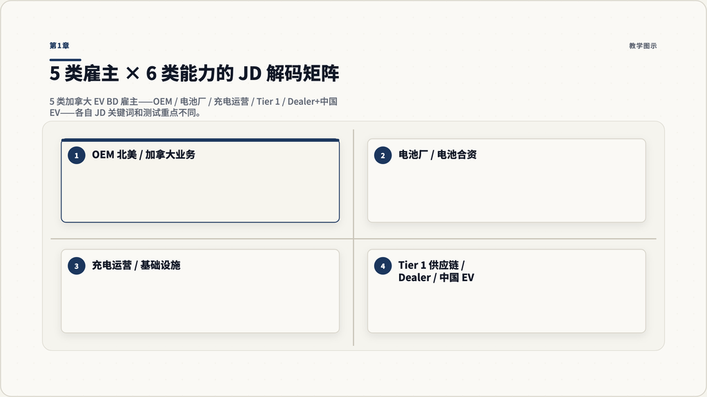

第1章：5 类雇主 × 6 类能力测试组合

**图 1.1：JD 是雇主的认知地图。先定位他属于哪一类，再判断他在测哪几条能力——你才知道面试里他到底要问什么。**

## 第2章 50 个高频行业知识题

### 2.1 这一章怎么用

50 题分成 5 个模块，每模块 10 题：

- **政策模块**（题 1-10）：加拿大 EV mandate、EVAP、IRA、Section 301、UFLPA、USMCA
- **OEM 模块**（题 11-20）：北美和加拿大主要 OEM 的当下 EV 策略
- **电池 / 充电模块**（题 21-30）：电池技术、供应链、充电标准、网络
- **中国 EV 模块**（题 31-40）：BYD、宁德、新势力、出海路径
- **加拿大本地模块**（题 41-50）：各省差异、本地玩家、地理特点

每题给三件东西：

1. **简明答案**（1-2 句，能在面试里直接讲）
2. **Follow-up 准备**（1 个对方很可能追问的点，你提前准备好怎么接）
3. **Trap to avoid**（1 个最常见的答错方向）

不背答案——背”答案结构”。面试官知道你在背答案就完了；他要看你有没有自己的判断框架。

### 2.2 模块一：政策（题 1-10）

**Q1. 2026 年 2 月联邦废除 EV 销售配额（EV Availability Standard）的核心变化是什么？**

- 答：废除强制配额（原 2026 年 20% / 2035 年 100%），改为软性目标（2035 年 75% / 2040 年 90%）；同步推出新 $2.3B EVAP 补贴 + 收紧燃油车排放法规。
- Follow-up 准备：对方可能问”这对中国 EV 进入加拿大是好消息还是坏消息？“——答：短期中性（关税壁垒没动），长期略偏正面（OEM 不再有合规压力把欧美车型摆在前列）。
- Trap：不要说”加拿大放弃 EV 转型了”。这是误读。法规收紧 + 补贴增加是双管齐下，只是手段不同。

**Q2. EVAP（Electric Vehicle Affordability Program）的具体机制是什么？**

**Q3. 美国 30D 在 2025 年 9 月 30 日终止后，北美补贴格局怎么变化？**

- 答：美国 BEV 消费者补贴归零（旧规则只到 9/30/2025 已交付车辆有效），政策重心转向制造端（45X production tax credit 等）；加拿大反而成为北美唯一活跃的 BEV 消费者补贴市场。
- Follow-up 准备：对方可能问”这是不是利好加拿大本地装配？“——答：理论上是，但要看 45X 是否同期调整；同时还要看美国是否会再加新版补贴。
- Trap：不要说”美国废了所有 EV 补贴”——只废了 30D 消费者侧，制造端补贴还在。

**Q4. Section 301 对中国 EV 100% 关税现在什么状态？**

- 答：USTR 在 2024-09 把中国 EV 关税从 25% 提到 100%，2025-2026 未调整；加拿大 2024-08 跟随同步加 100%。这两道墙是中国整车直接进入北美的最主要硬约束。
- Follow-up 准备：对方可能问”BYD 在墨西哥建厂能绕过去吗？“——答：理论上 USMCA 原产地规则下可以，但 USTR/CBP 正在收紧”实质性转换”的解释；MOFCOM 也在出审批限制中国出海资产。
- Trap：不要说”USMCA 完全合法绕”——这是 2024 年初的旧观点，2025 后语境完全变了。

**Q5. UFLPA（强迫劳动法）对中国电池进入北美的影响？**

- 答：UFLPA 限制新疆来源的硅 / 铝 / 钢等组件进入美国，CBP 维护 Entity List；中国电池厂出口到美国时需要”非新疆”供应链证明，多一道审计；加拿大暂无对等法规但企业自查趋严。
- Follow-up 准备：对方可能问”加拿大没有 UFLPA，是不是中国电池更容易进加拿大？“——答：法规上是，但加拿大很多电池/EV 项目客户最终是美国 OEM，所以实际上 UFLPA 是间接约束。
- Trap：不要说”UFLPA 是全面禁运”——它是文件审计制度，符合就能进。

**Q6. 美国 IRA 的 30D 已废，但 45X（生产端补贴）还在——这影响加拿大什么？**

- 答：45X 给在美国境内生产电池/材料的厂商每 kWh 现金补贴；加拿大本地装配的电池要进美国 OEM 供应链需要至少绕开 30D 的 FEOC 条款（虽然 30D 废了，但 FEOC 在 45X 里仍适用）；NextStar / PowerCo 等加拿大项目的客户主要是美国 OEM，所以 45X 间接拉动加拿大投资。
- Follow-up 准备：对方可能问”FEOC 对 LG-Stellantis NextStar 适用吗？“——答：NextStar 是 LG（韩国）+ Stellantis（荷兰）合资，理论上不触发 FEOC；但持股结构会被审视。
- Trap：不要把 30D 和 45X 混说——一个消费侧已废，一个生产侧还活。

**Q7. ZEV mandate 在省级层面还活着吗？**

- 答：联邦版废了，但 BC、魁北克的省级 ZEV mandate 还在运行；BC 要求 2026 年新车 26% ZEV、2030 年 90%；魁北克的 ZEV credit 制度也未变。这意味着 BC + 魁北克销售的 EV 仍然受省级强制约束。
- Follow-up 准备：对方可能问”安大略呢？“——答：安大略没有 ZEV mandate，福特政府 2018 后取消了；但 EVAP 联邦补贴在安大略一样适用。
- Trap：不要说”加拿大废了 ZEV mandate”——废的是联邦版本，省级各自独立。

**Q8. CBSA（加拿大海关）在 EV 进口上有什么特别要求？**

- 答：除了 100% 中国 EV 关税，CBSA 还要求 EV 进口时申报电池技术参数（容量、化学体系、原产地）；2025 年开始有更严的反规避审查（针对在墨西哥/越南/印尼装配的中国资本背景品牌）。
- Follow-up 准备：对方可能问”100% 关税之外还有 GST/PST 吗？“——答：5% 联邦 GST 全国适用；省级 PST/HST 看省份（安大略 HST 13%、BC GST+PST 12%、阿尔伯塔仅 GST）。
- Trap：不要忽略关税之外的隐性合规成本（认证、召回责任、本地服务网络等）——这些对中国新进入品牌是高于关税的真实门槛。

**Q9. USMCA 在 EV / 电池规则上的关键约束是什么？**

- 答：USMCA 原产地规则要求乘用车 75% 区域价值含量、且核心零部件含锂电池 75% 区域价值含量；2026 年起劳动力工资条款要求 40% 价值来自时薪 $16+ 的工人；中国资本背景但在墨西哥生产的车，要满足这些规则才能享受 USMCA 零关税。
- Follow-up 准备：对方可能问”BYD 墨西哥工厂能享受 USMCA 吗？“——答：理论上能，但实际上原产地证明门槛极高，且美方有意收紧解释；目前 BYD 内部判断 2026 年走 USMCA 路径概率较低。
- Trap：不要把”USMCA”和”NAFTA”混说——条款不同，劳动力含量条款是 USMCA 新加的。

**Q10. 加拿大联邦在 EV 充电基础设施上有什么补贴或政策？**

- 答：ZEVIP（Zero Emission Vehicle Infrastructure Program）目前在运行，资助商业、多户住宅、车队充电；2024-2026 年累计资助 $680M+；NRCan（自然资源部）主导。EVAP 2026 启动后，预计 ZEVIP 也会刷新。
- Follow-up 准备：对方可能问”私人住宅充电桩有补贴吗？“——答：联邦没有直接给个人住宅的补贴，但部分省（如魁北克 Roulez vert）给。
- Trap：不要把消费者补贴和基础设施补贴混说——EVAP 是消费者侧，ZEVIP 是基础设施侧。

### 2.3 模块二：OEM（题 11-20）

**Q11. 福特 Model e 业务现在的状态是什么？**

- 答：Model e（福特 EV 业务部门）在 2024-2025 持续亏损（年度亏损 $5B 量级），福特 2024 年减少 EV 资本支出、推迟新车型；F-150 Lightning 销量未达预期但仍是品牌核心 EV；新一代 RWD 平台原定 2027 推出。
- Follow-up 准备：对方可能问”福特会不会退出 EV？“——答：不会，福特 2024-2025 的姿态是”放慢但不退出”——CEO Farley 公开多次表态长期承诺 EV，但短期回归利润优先。
- Trap：不要把福特 EV 业务说成”濒临死亡”——Model e 是亏损单元，但福特整体盈利且 Lightning 仍是主力车型。

**Q12. GM 的 Ultium 平台战略当下姿态？**

- 答：2024 GM 把 Ultium 改名（弱化品牌化），Equinox EV / Blazer EV / Hummer EV 成为主力车型；2025 GM 在美国 EV 市场份额第二（约 13%）；与 LG / SAIC 关系正在调整。
- Follow-up 准备：对方可能问”GM 和 LG 现在的关系？“——答：Ultium Cells（LG 合资）在俄亥俄/田纳西/密歇根/Spring Hill 都在运行；最近 LG 单独想买更多产能，GM 也在评估更多元化电池来源。
- Trap：不要说”GM 完全押注 LG”——GM 同时跟 SES、Solid Power、CATL（部分授权）多线布局。

**Q13. Stellantis 在加拿大的 EV 布局是什么？**

- 答：Stellantis-LG 合资 NextStar Energy（Windsor）2025 年 11 月投产，目标 2027 年满产 ~45 GWh；Stellantis 在 Windsor ARDC（北美研发中心）保留 ~800 人专做 EV 和电池研发；Brampton 工厂 2026 复工生产 Charger / Challenger 电动版（推迟过两次）。
- Follow-up 准备：对方可能问”Brampton 工厂为什么推迟过？“——答：2024 Q1 起推迟，主要原因是 EV 需求放缓 + Stellantis 全球策略调整；2025 重启决定与加拿大政府新一轮谈判挂钩。
- Trap：不要把 NextStar 直接说成”Stellantis 的工厂”——它是 Stellantis + LG 合资公司，独立法人，独立招聘。

**Q14. Toyota 在北美的 EV 策略是什么？**

- 答：Toyota 走”hybrid-first + BEV 慢启动”路线；2024 Toyota 北美 销量 60%+ 是 hybrid；BEV 主力 bZ4X 卖得不好；2025 推出 Land Cruiser EV / Lexus 系列；本地化电池厂在北卡罗来纳州（Liberty Plant，2025 投产）。
- Follow-up 准备：对方可能问”Toyota 是不是落后了？“——答：销量上没落后（hybrid 实际是 Toyota 当下盈利核心），但 BEV 上落后；Toyota 自己的判断是 BEV 不会一统江山，混动 + 氢 + BEV 三路并进。
- Trap：不要简单说”Toyota 慢了所以落后”——这是 EV 媒体视角，Toyota 自己的策略是有意为之，且当前盈利远高于走纯 EV 的竞争对手。

**Q15. Hyundai-Kia 在北美的 EV 地位？**

- 答：Hyundai-Kia 是 2024-2025 北美 EV 市场份额增长最快的传统 OEM；Metaplant America（佐治亚州，2024 启动）专做 EV；Ioniq 5/6/9 + EV6/EV9 是主力；2025 北美 EV 份额 ~10%（vs 2023 ~7%）。
- Follow-up 准备：对方可能问”Hyundai-Kia 比 GM 强吗？“——答：销量份额上 GM 仍领先（~13% vs ~10%），但 Hyundai-Kia 的产品迭代速度和成本控制更优，未来 2-3 年很可能反超 GM。
- Trap：不要把 Hyundai 和 Kia 完全分开说——他们共享平台和电池，是同一个集团下的双品牌策略，类似 GM 的多品牌阶梯。

**Q16. Tesla 在加拿大的现状是什么？**

- 答：Tesla 仍是加拿大 EV 销量第一，但份额从 2023 年 ~50% 降到 2025 年 ~40%；Supercharger 网络在加拿大有 ~150 个站；本地服务 + 销售直营，无 dealer 网络（绕过加拿大 dealer franchise 法律的灰色区，各省差异）。
- Follow-up 准备：对方可能问”Tesla 跟 dealer 法律打过架吗？“——答：在美国 50 个州都打过，加拿大省级层面阻力更小（除了魁北克部分早期阻力），整体 Tesla 在加拿大可以直营。
- Trap：不要把 Tesla 加拿大说成”在挣扎”——份额下降但绝对销量仍在，且 Model Y / Model 3 仍是销量前三车型。

**Q17. Honda 在加拿大 EV 的位置？**

- 答：Honda Canada 2024 年宣布在安大略 Alliston 投资 $15B 建电池厂 + EV 装配，是迄今加拿大单笔最大 OEM EV 投资；当前 BEV 产品（Prologue，与 GM 合作平台）销量平平；自有 EV 平台车型计划 2028 后投产。
- Follow-up 准备：对方可能问”Honda Alliston 项目进展？“——答：2024 年宣布后已开始土地准备，但 2025 年因 EV 需求放缓 Honda 推迟了部分时间表（量产从 2028 推到 2030）。
- Trap：不要把 Prologue 说成 Honda 自己的 EV——它本质上是 GM Ultium 平台贴 Honda logo。

**Q18. BYD 进入加拿大的概率和时间线？**

- 答：BYD 已在 2026 年 Q1 雇 Markham consultancy 寻找 20 个加拿大经销点（GTA、Vancouver、Montreal、Calgary 优先）；产品最可能从墨西哥工厂供应；100% 关税短期难绕，所以早期可能聚焦 PHEV 或商用车避开乘用车 BEV 关税。
- Follow-up 准备：对方可能问”BYD 怎么绕 100% 关税？“——答：路径 1：墨西哥工厂走 USMCA（难度大）；路径 2：本地组装（早期不现实）；路径 3：通过商用/公共交通车队（B2B 大订单，关税计算逻辑不同）。
- Trap：不要说”BYD 不可能进加拿大”——他们已经在招人和找店面，2026 H2 可能小批量进入。

**Q19. Zeekr 和 Chery 的加拿大进入策略？**

- 答：Zeekr（吉利旗下高端品牌）2026-04 在 Toronto 招了 7 个高级岗位（销售、法务、市场、售后、网络发展），早于 BYD 公开姿态；Chery 也在评估加拿大，但更多走商用车路径。
- Follow-up 准备：对方可能问”为什么 Zeekr 先于 BYD 公开招聘？“——答：Zeekr 体量小、决策快；BYD 因体量大需要更多内部协调；且 Zeekr 高端定位避开了 EVAP $50k 上限的目标客户群。
- Trap：不要把 Zeekr 和 Geely / Volvo 混说——Zeekr 是 Geely 的独立 EV 品牌，与 Geely 燃油车业务分开。

**Q20. 北美 OEM 在 2025-2026 的总体 EV 战略调整方向？**

- 答：三个一致动作——(1) 推迟新车型上市（Ford、GM、Honda 都有车型推迟 1-2 年），(2) 把更多资源放在 hybrid（不只 Toyota），(3) 降低 capex 强度（GM 2024 把 EV capex 砍 30%）。
- Follow-up 准备：对方可能问”这是 EV 转型失败吗？“——答：不是——这是消费需求增长慢于 OEM 投资速度的修正，长期路径未变，但速度调慢。
- Trap：不要说”OEM 放弃 EV”——所有公开声明都是”调整节奏不退出”。

### 2.4 模块三：电池与充电（题 21-30）

**Q21. NMC 和 LFP 在采购决策上的核心区别？**

- 答：NMC 能量密度高（260-280 Wh/kg）适合长续航高端车，但贵且热失控风险高；LFP 能量密度低（160-180 Wh/kg）但便宜、寿命长、安全；2024 起 LFP 在北美低端车快速增长（Tesla Model 3 标准版、福特 Mustang Mach-E 标准版用 LFP）。
- Follow-up 准备：对方可能问”加拿大本地电池厂是 NMC 还是 LFP？“——答：NextStar / PowerCo 主要是 NMC（高镍），LFP 在北美生产仍少。
- Trap：不要说”LFP 是落后的”——这是 2018 前的观点；2024 后 LFP 因成本+寿命+安全在全球 50%+ 新装车上使用。

**Q22. 宁德时代和 BYD 电池业务的根本区别？**

- 答：宁德是”电池公司卖给所有人”（客户：特斯拉、福特、宝马、上汽…），BYD 是”电池为整车自用 + 选择性外销”（90% 自用）；宁德是 OEM 视角的电池供应商，BYD 是 OEM 的电池+整车一体化。
- Follow-up 准备：对方可能问”宁德的 LRS 模式是什么？“——答：License + Royalty + Service——宁德把技术授权给本地伙伴（如福特 Marshall 工厂），收取技术费但不直接持股，规避 FEOC 限制。
- Trap：不要说”宁德和 BYD 都是中国电池厂”——他们的商业模式根本不同，BD 对话里要分开说。

**Q23. 加拿大本地的两家主要电池厂是？**

- 答：NextStar Energy（Windsor，LG + Stellantis 合资，2025-11 投产，目标 45 GWh）和 PowerCo（St. Thomas，Volkswagen 子公司，2027 投产目标 90 GWh）。这两家是加拿大电池供应链的双柱。
- Follow-up 准备：对方可能问”还有谁？“——答：另外有 Honda Alliston（2030 投产推迟）、Northvolt Canada（魁北克，2024 母公司破产后状态不明）；早期阶段较多。
- Trap：不要忘了 Umicore（比利时材料商，安大略 Loyalist 锂电池阴极材料厂在 2024 关停了），加拿大电池上游不只电芯。

**Q24. NACS（J3400）取代 CCS 的进度？**

- 答：2023 福特带头转 NACS，之后 GM、现代、Stellantis、Nissan、Honda、Hyundai-Kia、Toyota 全部转；SAE J3400 标准 2024 发布；2025 起新车基本上都自带 NACS 口或 NACS + CCS 适配器；CCS 在北美 2030 后基本停。
- Follow-up 准备：对方可能问”Tesla Supercharger 对其他品牌开放进度？“——答：2024 起逐步开放，但开放程度因车型而异（不是所有 Supercharger 都对其他品牌开放，且充电速度可能 limit 在 110 kW）。
- Trap：不要说”CCS 完全废了”——欧洲仍主用 CCS；北美 CCS 站还在运营，只是新增基本是 NACS。

**Q25. 加拿大主要充电运营商及市场份额？**

- 答：Tesla Supercharger（市场份额约 30%，但仅自家 + 部分开放），Flo（加拿大本土最大独立运营商，DC fast 站约 1,000+），Electrify Canada（VW 系，~250 站），Petro-Canada Electric Highway（150+），ChargePoint（站点散布，主要 Level 2）。
- Follow-up 准备：对方可能问”Flo 怎么跟 Tesla 竞争？“——答：Flo 走”为所有品牌服务”路线（标准 CCS + 适配 NACS），且与多家加油站/便利店连锁建立 site host 关系，覆盖 Tesla Supercharger 不进的小城市。
- Trap：不要混”运营商”和”硬件商”——ChargePoint 既是硬件厂商也是运营商，但商业模式不同。

**Q26. 电池回收在加拿大的现状？**

- 答：早期阶段；Li-Cycle（多伦多上市）是北美最大独立电池回收商但 2024 流动性危机暂停 Rochester 项目；其他玩家包括 American Battery Technology、Redwood Materials（美国为主，加拿大业务小）；未来 5 年内回收量随早期 EV 退役慢慢增长。
- Follow-up 准备：对方可能问”加拿大政府有强制回收法吗？“——答：暂无国家级 EV 电池强制回收法；EPR（Extended Producer Responsibility）省级法律覆盖普通电池，EV 电池在草案讨论中。
- Trap：不要把 Li-Cycle 说成”加拿大电池回收行业”——它一家公司的危机不代表整个行业。

**Q27. 锂、镍、钴等上游原料加拿大的位置？**

- 答：加拿大是全球第六大锂生产国（远小于澳大利亚/智利），但有大型未开发资源（魁北克 Whabouchi、Nemaska Lithium 等）；镍：Sudbury 是全球重要镍产区（Vale、Glencore）；钴：加拿大产量不大但有冶炼能力；铜矿丰富（电气化必需）。
- Follow-up 准备：对方可能问”加拿大锂供应能不能填补北美需求？“——答：理论上有潜力，但开矿到产出 5-10 年周期；2030 前加拿大锂仍主要来自现有澳大利亚/智利来源，本地矿是中长期布局。
- Trap：不要把”有矿”和”开出来了”混——很多加拿大锂项目仍在 permitting 或 financing 阶段。

**Q28. 800V 平台和 400V 平台对采购方意味着什么？**

- 答：800V 充电更快（理论 350 kW+），但成本高、零部件复杂；400V 是主流（Tesla、Hyundai 部分车型、几乎所有大众化 EV）；800V 主要在高端车型（保时捷 Taycan、现代 IONIQ 5/6、起亚 EV6/EV9）。
- Follow-up 准备：对方可能问”未来主流是 800V 吗？“——答：高端车型是，中端 5-10 年仍 400V；这影响电池厂和零部件商的产品组合。
- Trap：不要说”800V 比 400V 好”——是为不同细分市场服务的不同方案。

**Q29. 固态电池什么时候商业化？**

- 答：丰田公开宣称 2027 年小批量 / 2030 年规模化；其他主流（QuantumScape、Solid Power、SES）都在试制阶段；现实可能落后 2-3 年。当下 BD 对话里把固态电池当”远期愿景”而不是”近期产品”。
- Follow-up 准备：对方可能问”中国谁在做固态？“——答：宁德、卫蓝、清陶等多家在做半固态/固态；商业化时间表与丰田相当。
- Trap：不要在面试里过度承诺固态电池时间表——这是行业最容易过度乐观的话题。

**Q30. 电池 pack vs cell 的 BD 分工？**

- 答：cell（电芯）是电池公司核心（宁德、LG、Samsung、SK 等）；pack（模组/组装）越来越多由 OEM 自己做或专门 pack 集成商做；BMS（电池管理系统）+ thermal management 是 OEM 差异化关键。BD 对话里要分清你卖的是 cell、pack 还是 module level 的解决方案。
- Follow-up 准备：对方可能问”BYD 的 Blade 是 cell 还是 pack？“——答：Blade 是 cell-to-pack 的 LFP 长方形电芯设计，省去模组层，是 BYD 的差异化技术。
- Trap：不要把 cell 和 battery system 混为一谈——价值链上不同层不同利润不同客户。

### 2.5 模块四：中国 EV（题 31-40）

**Q31. BYD 2024 年超过 Tesla 的核心原因？**

- 答：BYD 2024 年全球 EV+PHEV 销量超 400 万辆（Tesla ~180 万），主要靠：(1) 垂直整合（电池自产 + 整车 + 半导体），(2) PHEV 比例高（中国市场 PHEV 增长快），(3) 价格优势（同 segment 比 Tesla 便宜 30-40%）。
- Follow-up 准备：对方可能问”BYD 出海路径？“——答：东南亚（泰国工厂已投产）、欧洲（匈牙利工厂建设中）、巴西（圣保罗工厂）、墨西哥（评估中）、北美（最难，加拿大 2026 试探）。
- Trap：不要简单说”BYD 比 Tesla 强”——BYD 主要赢在体量和市场组合，Tesla 仍在高端电动+软件+充电网络领先。

**Q32. 蔚来 / 小鹏 / 理想 / 小米 各自的差异化？**

- 答：蔚来——换电 + 高端服务（NIO House）；小鹏——智驾 + 软件；理想——增程式 SUV + 家庭定位；小米——生态联动 + 性价比+流量。这四家都是中国 EV 新势力，但定位完全不同。
- Follow-up 准备：对方可能问”这四家谁出海最积极？“——答：蔚来欧洲 + 中东（NIO House 模式），小鹏欧洲 + 东南亚，理想偏内地市场（出海慢），小米 2024 才开始考虑出海。
- Trap：不要把这四家混称”新势力”——他们的商业模式、客户、出海策略完全不同。

**Q33. 蔚小理 2025-2026 的现状？**

- 答：蔚来——持续亏损但有腾讯/中东主权基金支持；小鹏——2024 大众入股 + 平台合作让生死获得喘息；理想——2024 销量第一新势力，盈利已稳定；小米——SU7 2024-2025 是中国最大新车热点，但海外路径尚不清晰。
- Follow-up 准备：对方可能问”蔚来会不会倒？“——答：短期内有现金支持不会，但长期需要看 ET5/ET7/ES8 等车型销量是否能稳定盈利。中国汽车分析师预测 2027 前蔚来需要更深结构调整。
- Trap：不要说”中国新势力都活不下来”——理想已盈利，小鹏有了大众，整体格局比 2022 年悲观叙事好。

**Q34. 中国电池厂在北美的”LRS 模式”？**

- 答：宁德先在福特 Marshall 工厂用 License + Royalty + Service 模式——宁德授权技术但不持股，福特拥有工厂和电芯。这绕开了 FEOC 的”中国持股”约束。其他中国电池厂（LFP 类）也在评估类似模式。
- Follow-up 准备：对方可能问”LRS 模式能复制到加拿大吗？“——答：理论可以，但加拿大无 FEOC 等价物，所以 LRS 在加拿大反而不是必需结构；中国电池厂在加拿大可以更直接地合资或直营。
- Trap：不要把 LRS 说成”标准模式”——它是宁德/福特特定结构，其他玩家结构可能完全不同。

**Q35. 中国 EV 出海的”主要障碍三角”？**

- 答：(1) 关税（北美 100%，欧盟 17-38%），(2) 监管/标准认证（车辆安全、电池标准、数据本地化），(3) 渠道建设（dealer 网络、服务网络、品牌）。这三个是任何中国 EV 在海外都要解决的核心问题。
- Follow-up 准备：对方可能问”哪个是最难的？“——答：长期看渠道——关税可以谈判，认证可以做，但建立本地用户信任和服务能力是 5-10 年的事。
- Trap：不要只说”关税”——这是大众媒体视角，真正的实操难点是渠道和信任。

**Q36. 宁德时代在北美最大客户是谁？**

- 答：宁德在北美的最大客户曾是 Tesla（上海工厂供货 + 美国市场销售），现在福特通过 LRS 模式 + GM 通过限量授权 + 多家美国新势力小批量；宁德的”北美战略”主要是间接供货（中国造然后整车出口）+ 技术授权。
- Follow-up 准备：对方可能问”宁德有自建美国工厂的可能吗？“——答：短期无（FEOC 阻碍），中期看政策——如果 USTR 给”白名单”宁德可能直投但目前无迹象。
- Trap：不要说”宁德在北美没有市场”——通过 LRS 和 OEM 间接销售份额仍很大。

**Q37. Geely 集团下的 Volvo / Polestar / Zeekr 在北美的策略区别？**

- 答：Volvo——传统欧洲品牌 + 美国南卡罗来纳州工厂；Polestar——EV 独立子品牌，南卡共享工厂 + 中国部分车型直接出口（受关税影响）；Zeekr——高端中国品牌，2026 加拿大试探。Geely 是中国资本+全球品牌组合的典型。
- Follow-up 准备：对方可能问”Polestar 为什么挣扎？“——答：2024-2025 销量未达预期 + 公司财务紧张 + Geely 集团内部资源分配争议；Polestar 2025 多次裁员。
- Trap：不要把 Volvo 当”瑞典公司”——Geely 全资，是中国资本布局欧洲品牌的成功案例。

**Q38. 比亚迪在墨西哥的工厂状态？**

- 答：BYD 2024 公开宣布墨西哥建厂计划但具体地点未定（曾考虑新莱昂州、Jalisco 等）；2025 年因美国政策环境 + 中国 MOFCOM 收紧出海资产审批，进度放缓；最早投产时间从原 2026 推到 2027-2028。
- Follow-up 准备：对方可能问”为什么 MOFCOM 要限制？“——答：中国政府担心车企海外资产被美国/欧洲制裁或没收，且不希望中国 EV 厂家在墨西哥被用于”中转避税”对中国整体产业链不利。
- Trap：不要把 BYD 墨西哥说成”已经在生产”——这是常见的旧消息错位。

**Q39. 中国 EV 在欧洲的表现？**

- 答：2024 中国品牌在欧洲 EV 市场份额约 8%；欧盟 2024-10 加 17-38% 反补贴关税（视品牌而定）；BYD/MG/吉利/上汽是主要玩家；MG（上汽英国品牌）销量最大。
- Follow-up 准备：对方可能问”欧洲关税跟北美 100% 比怎么样？“——答：欧洲明显宽松，所以中国 EV 在欧洲仍有商业空间；但反规避案例增多（如布鲁塞尔 2025 调查中国 EV 在匈牙利组装是否绕规则）。
- Trap：不要说”欧洲也封了中国”——欧洲是部分关税不是全面封锁，与北美完全不同。

**Q40. 中国 EV 厂家想进加拿大，三种最现实的路径？**

- 答：(1) **乘用车 BEV 进口**（100% 关税，主要做高端，目标客户对价格不敏感），(2) **PHEV 路径**（关税规则与 BEV 不完全一致，部分品牌评估），(3) **商用车/巴士/卡车**（B2B 决策，关税计算逻辑不同；比亚迪商用车在加拿大已有部分订单）。本地组装/工厂在 2030 前不现实。
- Follow-up 准备：对方可能问”哪个路径会先突破？“——答：商用车 + 高端乘用车 BEV 双管齐下；PHEV 取决于具体品牌的产品组合。
- Trap：不要把”中国 EV 进加拿大”说成单一路径——多路径并行是 2026-2028 的主旋律。

### 2.6 模块五：加拿大本地（题 41-50）

**Q41. 魁北克 EV 渗透率为什么 2024 达到 33%？**

- 答：四因素叠加：(1) 省级补贴（Roulez vert 给 BEV 最高 $7,000）+ EVAP 联邦，(2) 省级 ZEV mandate（强制 dealer 卖 EV），(3) Hydro-Québec 充电网络覆盖广，(4) 寒冷文化对 EV 性能的接受度（魁北克人有冬季用车习惯）。
- Follow-up 准备：对方可能问”魁北克 EV 销量还能涨多少？“——答：理论 2027 年可达 50%+，但实际取决于车型供应和补贴持续性。
- Trap：不要把魁北克高渗透率说成”加拿大平均”——加拿大全国 EV 渗透率约 15%（差异巨大）。

**Q42. 安大略省 EV 政策的当前状态？**

- 答：福特省长 2018 取消省级 EV rebate；2024-2026 安大略联邦 EVAP 覆盖但无省级补贴；安大略主要 EV 政策是吸引投资（NextStar、PowerCo、Honda Alliston 都在安大略）；BC 是政策最支持但安大略是投资规模最大。
- Follow-up 准备：对方可能问”安大略为什么不重新引入补贴？“——答：政治原因 + 福特政府保守经济政策定位；2026 联邦 EVAP 让省级补贴必要性降低。
- Trap：不要说”安大略不支持 EV”——投资规模上安大略实际最支持，只是消费侧补贴缺。

**Q43. BC 省 EV 政策的特点？**

- 答：BC 有最严的省级 ZEV mandate（2026 年 26% 新车 ZEV，2030 年 90%）；省级 CleanBC 补贴（BEV $4,000）；充电网络全国最密集（Sea-to-Sky、Trans-Canada Highway 全覆盖）；2024 EV 渗透率约 25%。
- Follow-up 准备：对方可能问”BC 跟魁北克谁强？“——答：BC 政策最严，魁北克渗透率最高；两个不矛盾——BC 政策强但车型供应早期不足，魁北克补贴更高拉动消费。
- Trap：不要把 BC 当”加拿大 EV 政策标杆”——它确实领先，但其他省（特别是安大略+魁北克）才是 EV 销量主战场。

**Q44. 阿尔伯塔省的 EV 态度？**

- 答：阿尔伯塔是石油大省，省政府对 EV 政策不积极；2024 还反对联邦 EV mandate；EV 渗透率全国最低（<5%）；但阿尔伯塔有重要的电池上游金属资源（锂）。
- Follow-up 准备：对方可能问”BD 怎么开发阿尔伯塔市场？“——答：B2B 优先（车队、政府、矿业用车）；零售渠道难做；不能用 BC/魁北克的”政策驱动”打法。
- Trap：不要把阿尔伯塔说成”反 EV”——经济现实是石油经济，但阿尔伯塔企业（特别是矿业）对电气化是支持的（自己卖锂）。

**Q45. 加拿大主要 EV 销量集中地区？**

- 答：四个销量集中地：GTA（多伦多 + 周边）、Greater Montreal、Vancouver Metro、Calgary/Edmonton（小但增长快）；这四个区占加拿大 EV 销量 75%+；BD 起步基本都从这四个城市开始。
- Follow-up 准备：对方可能问”为什么不是渥太华？“——答：渥太华是行政中心，零售市场小；EV 政策在渥太华决定，但销量主要在大都市。
- Trap：不要漏 Calgary/Edmonton——虽然阿尔伯塔政策不友好，但能源 + 矿业带来的高收入人群是 EV 早期市场。

**Q46. 加拿大与美国 EV 政策同步度？**

- 答：贸易壁垒同步（中国 100% 关税同步加）；补贴不同步（美国 30D 已废，加拿大新 EVAP 替代）；排放标准趋同（加拿大跟美国 EPA 大致同步）；ZEV mandate 完全独立（美国 CARB 各州，加拿大联邦+省级）。
- Follow-up 准备：对方可能问”USMCA 谈判 2026 中期审查对加拿大 EV 意味着什么？“——答：核心是原产地规则和劳动力含量条款是否调整；加拿大政府希望维持 USMCA 框架，但美国新政府可能要求加严。
- Trap：不要说”加拿大跟美国一样”——只在贸易壁垒同步，其他独立。

**Q47. 加拿大 dealer franchise 法律的省级差异？**

- 答：加拿大 dealer law 比美国宽松——大部分省允许 OEM 直营（Tesla 在大多数省直营），但魁北克、安大略、BC 有部分限制；新进入品牌（如 BYD/Zeekr）可以选择直营或经销混合模式。
- Follow-up 准备：对方可能问”BYD 应该走直营还是 dealer？“——答：早期阶段直营或半直营更可控（品牌教育+服务网络都要从零起），dealer 模式适合产品成熟+品牌知名度高之后。
- Trap：不要把加拿大 dealer 法律说成”跟美国一样严格”——加拿大宽松得多。

**Q48. 加拿大消费者对 EV 的主要顾虑？**

- 答：(1) 续航焦虑（特别是冬季 -20°C 时电池衰减），(2) 充电网络（非大城市覆盖不足），(3) 维修服务（小品牌服务网络稀薄），(4) 总持有成本（虽然燃料省，但电池更换成本是隐忧），(5) 政策不确定（EVAP 补贴会不会持续）。
- Follow-up 准备：对方可能问”哪条是 BD 最容易解决的？“——答：充电网络和维修服务——这是 BD 能直接介入的合作面；续航和电池寿命是产品工程的事。
- Trap：不要忽略”政策不确定”——2026 联邦废除 mandate 后消费者对 EV 政策长期承诺的信心受到打击。

**Q49. 加拿大 EV 渠道里 dealer 集团的角色？**

- 答：AutoCanada 是最大本土上市 dealer 集团（66 加+18 美 franchise dealers，25 品牌），Pfaff（多伦多高端）、Quebecor（魁北克）等也是关键玩家；这些集团是中国 EV 进入加拿大的潜在合作伙伴（避免从零建网络）。
- Follow-up 准备：对方可能问”AutoCanada 会跟中国品牌合作吗？“——答：理论上是商业问题不是政治问题，但要看品牌定位、毛利模型、品牌风险三个维度的对齐；目前公开案例尚少。
- Trap：不要把 dealer 集团说成”是 OEM 的代理”——他们是独立利润中心，跟 OEM 谈判力很强。

**Q50. 加拿大 EV BD 的最大宏观趋势（2026-2028）？**

- 答：三个主导趋势：(1) **本地化加速**（NextStar、PowerCo、Honda 都在投产或建设），(2) **中国品牌试探进入**（BYD/Zeekr/Chery 三家先后），(3) **政策转向温和**（联邦废 mandate + 收紧排放 + 加强补贴，是务实平衡而非激进）。
- Follow-up 准备：对方可能问”你看好哪条？“——答：本地化加速是确定性最强的；中国进入有不确定性；政策温和是短期姿态但 2027 USMCA 审查可能改变。
- Trap：不要给出过度自信的预测——加拿大 EV 市场每季度都有变化，给”基于当前数据的判断”而非”未来 3 年的预言”。

### 2.7 章末检查点

随机选 10 题，自己掐表 90 秒答完一题（按答案 + follow-up + trap 三段说出来）。如果 10 题里有 3 题以上你超过 90 秒或者讲不顺——这章还没过关。

设置一个 Anki 卡组，每天复习 10 题，21 天一轮。面试前一周做最后一轮快测。

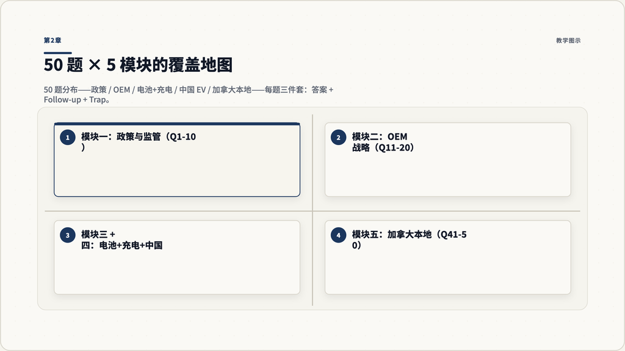

第2章：50 题 × 5 模块的覆盖地图

**图 2.1：50 题分布——5 个模块各 10 题，每题三件套：简明答案、Follow-up 准备、Trap to avoid。这不是知识展示，这是面试桌上的硬通货。**

## 第3章 STAR 题库：27 个行为面试骨架

### 3.1 STAR 的真问题不是格式，是密度

STAR（Situation / Task / Action / Result）作为框架不难——大多数候选人都听过。难的是**在一个 90 秒回答里同时提供足够的具体性 + 让面试官信任你 + 留出钩子让对方追问**。

转型者的 STAR 通常有四个失败模式：

1. **过于通用**：“我做销售有 10+ 年经验”——这不是 STAR
2. **过于细节**：花 60 秒讲背景，最后 10 秒说结果——倒挂
3. **数字模糊**：“销售大幅提升”——不可验证，面试官立刻打折
4. **缺乏 BD 视角**：讲了产品销售，但没拉到合作伙伴 / 渠道 / 长期关系的层面

这一章给你 27 个 STAR 骨架。骨架是空的——故事必须你自己填。但每个骨架都给你：

- **Situation 必须包含的要素**
- **Task 怎么定义对面试官有冲击力**
- **Action 必须展示哪几个具体动作**
- **Result 怎么量化以及怎么避免吹牛**
- **BD 角度的好答案标准**（区别于一般销售/项目管理）
- **常见跌跤点**

### 3.2 怎么用这一章

每个 STAR 骨架都是”题目 + 框架 + 跌跤点”的结构。你的作业：

1. 把这 27 题列在一张表上
2. 每题想 1-2 个你**真实经历过**的故事候选
3. 用骨架重构你的故事（不是从头编）
4. 每个故事控制在 75-90 秒讲完
5. 用手机录音自听——节奏不对就重做

**绝对不要**：拿这 27 个骨架直接编故事。面试官每天看 10 个候选人，编的细节立刻被识破。

### 3.3 第一类：闭单 / 销售达成（5 题）

**Q1. 讲一个你拿下的最难的 deal。**

- Situation 必须包含：客户难度（决策长 / 多 stakeholder / 竞争激烈），具体行业，时间点
- Task：明确目标（合同规模、deadline、与什么人 align）
- Action 必须展示：发现客户真实顾虑的具体方法、克服顾虑的具体动作、内部协调
- Result：量化（合同金额、续约/扩展、关系深化）
- BD 角度好答案：体现”长期关系”而非”一次性销售”
- 跌跤点：把”难”说成”客户难缠”——这暴露了你不懂客户

**Q2. 讲一个你失败的 deal——你学到了什么。**

- Situation：清晰描述局面（不要美化）
- Task：你以为可以的，但没拿下
- Action：你做了什么（不要回避自己的决策）
- Result：失败本身 + 你之后做了什么（这是核心）
- BD 角度好答案：体现”复盘 + 应用到后续 deal”
- 跌跤点：归因外部（“客户没诚意”“市场不好”）

**Q3. 讲一个你超额完成 quota 的季度——具体做了什么。**

- Situation：哪个季度，超额多少（%）
- Task：你重点 push 的几个 deal
- Action：具体哪几个动作让超额发生
- Result：超额的具体数字 + 团队/公司影响
- BD 角度好答案：体现”非偶然，是系统设计的结果”
- 跌跤点：吹牛（“我做了 200% 的 quota”）但没法具体说出怎么做的

**Q4. 讲一个你从 zero-to-one 建立的客户关系。**

- Situation：客户行业 + 为什么是从零开始（你之前没接触过的）
- Task：你的目标是建立持续关系还是单次交易
- Action：第一次接触、第二次跟进、第三次升级的具体动作
- Result：关系最终深度（合同 + 续约 + 推荐其他客户）
- BD 角度好答案：体现”信任建立的具体动作”而非”运气”
- 跌跤点：跳过最早期的几次接触（这是最有意义的部分）

**Q5. 讲一个你说服客户改变原有偏好的对话。**

- Situation：客户原本想要什么 vs 你建议什么
- Task：你为什么相信你的建议更好（不只为 commission，是真为客户）
- Action：你怎么开口、用什么数据/案例、怎么处理 push-back
- Result：客户最终决定 + 后续关系（最好是更信任你了）
- BD 角度好答案：体现”销售 ≠ 推销”——你提了对客户更好的建议
- 跌跤点：故事变成”我赢了客户”而不是”我帮客户”

### 3.4 第二类：冲突 / 难处理的局面（4 题）

**Q6. 讲一次你跟内部团队冲突的经历。**

- Situation：你跟哪个部门冲突（产品 / 工程 / 法务 / 财务）
- Task：你需要从他们那里得到什么
- Action：你怎么处理冲突（不是回避也不是硬刚）
- Result：最终结果 + 关系是否修复
- BD 角度好答案：体现”BD 是跨部门协作的核心”
- 跌跤点：故事变成”我赢了内部辩论”——BD 不是辩论赛

**Q7. 讲一次你跟客户高层冲突的经历。**

- Situation：什么冲突（价格 / 服务 / 合同条款）
- Task：你的立场 vs 客户立场
- Action：你怎么沟通——直接 push back 还是迂回
- Result：最终结果 + 关系是否保住
- BD 角度好答案：体现”敢直接沟通 + 不破坏关系”
- 跌跤点：让步太多（暴露你软）或硬刚（暴露你不懂客户关系）

**Q8. 讲一次你的项目被卡住——具体怎么解。**

- Situation：什么卡住（资金 / 决策 / 资源 / 合作方）
- Task：你的目标 + deadline
- Action：你尝试了哪几条路径，哪条work
- Result：项目走通 + 后续是否复用这个方法
- BD 角度好答案：体现”系统性解决”而非”靠人脉”
- 跌跤点：故事变成”我找到了关键人”——BD 不能纯靠关系

**Q9. 讲一次你不同意上级决定但仍执行的经历。**

- Situation：上级的决定是什么 vs 你的判断
- Task：你如何同时表达立场和执行任务
- Action：你跟上级沟通的具体动作 + 执行时怎么处理（不破坏团队）
- Result：最终结果 + 你的复盘
- BD 角度好答案：体现”专业成熟”——不是顺从也不是反叛
- 跌跤点：变成”我对了上级错了”的故事——面试官立刻打分降

### 3.5 第三类：影响力 / 跨职能协作（4 题）

**Q10. 讲一次你没有正式权力但要让事情发生的经历。**

- Situation：哪个跨部门项目你是协调人
- Task：需要让谁做什么
- Action：你的影响力工具——数据 / 关系 / 故事 / 共同目标
- Result：事情发生 + 内部反馈
- BD 角度好答案：体现”软影响力是 BD 核心技能”
- 跌跤点：用了 hard pressure 但讲成 soft influence

**Q11. 讲一次你协调多 stakeholder 推进项目的经历。**

- Situation：多少 stakeholder（建议 3+）
- Task：他们各自的目标矛盾点在哪
- Action：你怎么找共同点 + 怎么管 conflict
- Result：项目成果 + stakeholder 关系
- BD 角度好答案：体现”复杂局面的结构化处理”
- 跌跤点：stakeholder 太少（少于 3 个不算复杂）

**Q12. 讲一次你说服了一个高层的经历。**

- Situation：高层职位 + 议题
- Task：你想让他做什么
- Action：你的沟通策略 + 用了什么材料
- Result：高层决定 + 后续
- BD 角度好答案：体现”用对方的语言说服对方”
- 跌跤点：吹高层职位（“我说服了 CEO”但没具体讲怎么）

**Q13. 讲一次你的工作影响了公司的战略方向。**

- Situation：什么战略议题（市场进入 / 产品 / 渠道）
- Task：你的贡献是什么
- Action：具体哪个 insight / 数据 / proposal
- Result：战略调整 + 业务结果
- BD 角度好答案：体现”BD 不只是执行，也产生战略 input”
- 跌跤点：把自己说得太重要（面试官知道一个人不会改整个战略）

### 3.6 第四类：失败 / 错误 / 复盘（3 题）

**Q14. 你犯过的最大职业错误是什么？**

- Situation：清晰描述错误（不要美化）
- Task：你当时以为是对的
- Action：你做了什么导致错误
- Result：后果 + 你之后做了什么
- BD 角度好答案：错误本身可以小但反思要深
- 跌跤点：选了一个”假错误”（“我太追求完美”）——面试官立刻看穿

**Q15. 讲一次你的预测错了——后来怎么调整。**

- Situation：什么预测（市场 / 客户 / 产品）
- Task：你基于什么做的预测
- Action：预测错了之后你的反应（不是辩护，是调整）
- Result：调整后结果 + 学到什么方法论
- BD 角度好答案：体现”intellectual honesty”
- 跌跤点：故事变成”市场骗了我”——这是不负责的归因

**Q16. 讲一次你处理失败客户的经历。**

- Situation：客户为什么失败（投诉 / 流失 / 关系破裂）
- Task：你的角色（修复还是 graceful exit）
- Action：具体动作
- Result：最终关系 + 你的学习
- BD 角度好答案：体现”客户走了关系还在”
- 跌跤点：把客户描述成”难缠”——BD 视角永远从自己反思起

### 3.7 第五类：跨文化 / 跨地域（3 题）

**Q17. 讲一次你在跨文化谈判里遇到的挑战。**

- Situation：哪两种文化（中国-北美 / 北美-欧洲 / etc）
- Task：什么议题
- Action：你怎么调整沟通 / 决策节奏 / 信任建立
- Result：结果 + 关系
- BD 角度好答案：体现”文化敏感性不只是语言”
- 跌跤点：变成 stereotype（“中国人喜欢…北美人喜欢…”）

**Q18. 讲一次你协调中国总部 + 北美本地团队的经历。**

- Situation：什么项目 + 哪两个团队
- Task：协调的具体内容（产品 / 销售 / 营销）
- Action：你怎么管时差 / 决策权力 / 优先级 不同
- Result：项目 + 双方关系
- BD 角度好答案：体现”你是真桥梁，不是单向翻译”
- 跌跤点：故事一边倒（只讲中国总部难协调或只讲北美难协调）

**Q19. 讲一次你帮一个团队进入新地域市场的经历。**

- Situation：什么团队进什么市场
- Task：你的角色（market entry strategy / 执行 / 招人）
- Action：你的具体贡献
- Result：市场进入结果 + 你的角色复盘
- BD 角度好答案：体现”市场进入是多维度系统问题”
- 跌跤点：把市场进入过度简化为”找经销商”

### 3.8 第六类：客户痴迷 / 长期关系（4 题）

**Q20. 讲一个你最长期的客户关系。**

- Situation：客户行业 + 关系长度（3+ 年）
- Task：怎么维持
- Action：超出”完成合同”的具体动作（推荐人脉、行业 insight 分享、生活节点关心）
- Result：合同累计 + 关系深度
- BD 角度好答案：体现”关系是 BD 真正的资产”
- 跌跤点：只讲合同金额——这是销售视角不是 BD 视角

**Q21. 讲一次你预判客户需求做主动准备的经历。**

- Situation：客户原本没说要什么
- Task：你预判到什么
- Action：你提前做了什么准备
- Result：客户的反应 + 关系升级
- BD 角度好答案：体现”主动 BD 而非反应式销售”
- 跌跤点：把自己说成”读心术”——要讲数据+观察怎么支撑你的预判

**Q22. 讲一次你拒绝了一个 deal——为什么。**

- Situation：什么 deal + 多大金额
- Task：你判断不该做的理由
- Action：你怎么跟客户沟通拒绝
- Result：关系是否保住 + 后续是否有更好 deal
- BD 角度好答案：体现”长期利益高于短期 commission”
- 跌跤点：故事变成”我有 integrity”——讲具体判断而非道德高地

**Q23. 讲一次客户给你 negative feedback 你怎么处理。**

- Situation：什么 feedback（产品 / 服务 / 沟通）
- Task：你怎么先消化情绪
- Action：你的具体响应动作
- Result：关系修复 + 你的改进
- BD 角度好答案：体现”feedback 是 BD 的核心 input source”
- 跌跤点：太防御性（暴露你听不进 feedback）

### 3.9 第七类：学习 / 适应（4 题）

**Q24. 讲一次你从零学一个新行业的经历。**

- Situation：什么行业 + 多少时间 + 为什么要学
- Task：你的学习目标（你要做什么）
- Action：你的学习方法（不只是读书——人 / 项目 / 实践）
- Result：你的能力变化 + 第一个成果
- BD 角度好答案：体现”快速学习是转型者的真技能”
- 跌跤点：只讲读了书——BD 学习更多在跟人对话和实际项目

**Q25. 讲一次你适应了大变化的经历（公司重组 / 业务转型 / 政策变化）。**

- Situation：什么变化
- Task：你的角色调整
- Action：你怎么主动适应（不是被动接受）
- Result：你的位置变化 + 学到的方法
- BD 角度好答案：体现”adaptability 是 EV 行业必备”
- 跌跤点：变成”我抱怨了变化但还是接受了”——这不是好答案

**Q26. 讲一次你向行业前辈/专家学习的经历。**

- Situation：你向谁学 + 为什么是他
- Task：你想学什么
- Action：你怎么 approach、怎么持续维护这个关系
- Result：你学到的东西 + 关系是否保持
- BD 角度好答案：体现”BD 永远在学习——网络本身是学习的工具”
- 跌跤点：把”导师”说成”导师指导我”——BD 学习是主动获取不是被动接受

**Q27. 你现在最想学的技能/知识是什么——为什么。**

- Situation：当前你的能力坐标
- Task：你想学的具体技能
- Action：你已经开始做的具体动作
- Result：（未来）这个技能会让你做什么
- BD 角度好答案：体现”growth mindset + EV 行业敏感”
- 跌跤点：选了一个跟 EV BD 无关的技能（“我想学滑雪”）

### 3.10 把这些骨架变成你的故事——5 步流程

1. **故事 inventory**：列出你过去 3-5 年最有冲击力的 8-12 个真实事件
2. **骨架匹配**：每个事件能 fit 哪几个 STAR 题
3. **故事重构**：按 STAR 骨架重写每个故事（不是从头编，是结构化重述）
4. **量化检查**：每个故事至少 1 个量化数字（合同金额 / 增长 % / 时间节省 / 团队规模）
5. **录音自听**：90 秒以内，节奏合理，BD 视角清晰

### 3.11 章末检查点

随便选 5 题，掐表 90 秒讲完。问自己三个问题：

- 我讲完后面试官能问出至少 2 个 follow-up 吗？（应该能——故事里要有钩子）
- 我有具体量化吗？
- 我有 BD 视角而不是纯销售/项目管理视角吗？

如果有任何一题三问里 No 多于 Yes——重做这个故事。

[figure not shown]

第3章：27 个 STAR 骨架的 7 类分布

## 第4章 案例题 8 类：从 GTM 到 channel conflict

### 4.1 为什么案例题不是 case interview

不要把 EV BD 的案例题想成麦肯锡式的 case interview。两者的目标完全不同：

- **麦肯锡 case**：测你能不能用结构化思维（profitability tree / 4P / Porter’s 5 forces）拆题
- **EV BD 案例**：测你能不能在限定信息下做出**有商业判断**的下一步建议

EV BD 面试官并不期待你给出”正确答案”——他想看你怎么想。所以你的回答不是”我会用 X 框架”——而是”我会先问 3 个问题来明确范围，然后我的初步判断是 Y，因为 Z”。

### 4.2 案例题的 5 步通用流程

不管哪类案例，把这 5 步固定下来：

**Step 1：澄清问题（30 秒）**

- 问 2-3 个关键澄清问题
- 例：“你说的’进入加拿大市场’是指 B2C 还是 B2B？时间窗口是多少？预算量级？”
- 这一步面试官在评估你能不能识别题目的 ambiguity

**Step 2：列假设（30 秒）**

- 说出你做的 2-3 个核心假设
- 例：“我假设我们目标是 BEV 乘用车 B2C，3 年内拿 5% 加拿大 EV 市场份额”
- 假设错了没关系——面试官会纠正你；不说假设是大问题

**Step 3：结构化分析（60-90 秒）**

- 按问题类型选 framework（下面 8 类各自有结构）
- 把 framework 应用到具体场景
- 给具体例子或数据点支撑

**Step 4：判断和建议（30-60 秒）**

- 一句话主结论
- 2-3 个支撑理由
- 明确 next step

**Step 5：风险和不确定性（15-30 秒）**

- 你的判断在什么假设下成立
- 什么会让你改变判断
- 这一步显示你”成熟”——不是 sell hard，是讲清楚边界

总时长：2.5-4 分钟一个案例题。

### 4.3 第一类：市场进入（Market Entry）

**典型题目**：“如果一家中国 EV 品牌要进入加拿大，你建议怎么做？”

**Step 1 澄清问题**：

- 哪个细分（high-end / mass / commercial）？
- 时间窗口？
- 现有资源（产品 / 资金 / 北美团队）？
- 关税 100% 是否可以接受作为定价输入？

**Step 2 假设**：

- 假设是 high-end BEV（避开 EVAP $50k 上限的目标客户群）
- 3 年时间 5% 市场份额
- 已有现成产品

**Step 3 结构化分析**：

用 **5C framework + 2 个 BD-specific 维度**：

1. Customer（加拿大 EV 早期采用者：BC + 魁北克 + GTA 高收入群）
2. Competitor（Tesla / Hyundai-Kia / Polestar 是主要竞争）
3. Channel（直营 vs. dealer 合作 vs. 混合）
4. Cost（关税 100% 之后定价空间）
5. Capabilities（你有什么 + 你需要什么）
6. **Regulatory**（CBSA / 省级 ZEV / 数据本地化）—— BD 特有
7. **Trust building**（中国品牌信任建立路径）—— BD 特有

**Step 4 判断**：

“我建议两阶段——前 12 个月在 GTA + Vancouver 做 5-8 家直营 flagship 店建立品牌教育和服务能力；同时跟 AutoCanada 等 dealer 集团谈选择性合作覆盖第二城市。3 年目标 5% 份额需要 product+brand+service+price 四件齐备。”

**Step 5 风险**：

“如果 USMCA 2027 审查后关税进一步收紧，或者加拿大跟随美国走 UFLPA-style 限制，整个计划需要重做。”

### 4.4 第二类：渠道冲突（Channel Conflict）

**典型题目**：“你的 OEM 客户原来是通过 dealer 卖车，现在想加 D2C 渠道。怎么处理 dealer 反弹？”

**Step 1 澄清**：

- D2C 占比目标？
- dealer 集团是少数几个还是分散？
- 是否已有 dealer agreement 限制 D2C？
- 公司高层对 dealer 关系的优先级？

**Step 2 假设**：

- 现有 50+ dealer，分散
- 5 年 D2C 占比 30% 目标
- 高层希望保持 dealer 关系不破裂

**Step 3 结构化分析**：

用 **冲突 → 共赢转化框架**：

1. **识别冲突来源**：dealer 怕失去销量、佣金、库存周转
2. **量化冲突边界**：30% D2C 直接抢走多少 dealer 销量？哪些细分会被抢？
3. **设计共赢机制**：
   - 提议 1：D2C 仅做高端旗舰车型，dealer 主推中低端
   - 提议 2：D2C 订单送到本地 dealer 完成 delivery + 服务，dealer 拿一部分 fee
   - 提议 3：dealer 获得免费数字化升级 + 销售员培训作为补偿
4. **沟通节奏**：6 个月路线图（先 town hall 通气，再选 5-10 家 pilot dealer，再扩展）

**Step 4 判断**：

“我建议提议 2（dealer-as-delivery-partner）+ 提议 3（数字化升级）组合。这让 dealer 仍有 revenue stake，同时 OEM 拿回客户关系数据。”

**Step 5 风险**：

“风险是 dealer 集团联合抵制——所以早期要选 5-10 家积极转型 dealer 做 pilot，做成案例再推广。”

### 4.5 第三类：Build vs. Buy（自建 vs. 合作）

**典型题目**：“我们要进加拿大充电网络，建议自建还是跟现有运营商合作？”

**Step 1 澄清**：

- 公司主业是什么？充电是核心还是辅助？
- 预算和时间？
- 战略目标是市场份额还是服务客户？

**Step 2 假设**：

- 主业 OEM，充电是为支持自家车销售
- 5 年预算 $50M，希望 3 年覆盖 GTA + Montreal + Vancouver
- 战略目标是给客户提供 hassle-free 充电

**Step 3 结构化分析**：

用 **Build vs. Buy 四象限**：

|  | 自建 | 合作（Flo / Petro-Canada） |
| --- | --- | --- |
| 速度 | 慢（24-36 个月开站） | 快（已有网络） |
| 控制 | 高（品牌 + 数据 + UX） | 低（依赖 partner） |
| 成本 | $50M 只能建 30-40 站 | $50M 可以买大量充电时长 + 联名 |
| 战略价值 | 长期资产 | 短期客户体验 |

**Step 4 判断**：

“我建议混合策略：核心都市旗舰位置（10 个站）自建打造品牌体验；其他 80% 覆盖通过跟 Flo 战略合作，联名 brand + 客户 app 集成。”

**Step 5 风险**：

“风险是 Flo 跟竞争对手也合作——所以合作协议要包含 service level + 品牌 visibility 条款。”

### 4.6 第四类：客户优先级（Account Prioritization）

**典型题目**：“你接手一个 50+ 客户的 portfolio，怎么决定 next quarter 的精力分配？”

**Step 1 澄清**：

- 客户类型一致还是 mixed（OEM / Tier 1 / dealer）？
- 你的 quota 节奏？
- 现有客户健康度？

**Step 2 假设**：

- 50 个客户：20 OEM-level、20 dealer-level、10 其他
- Quarter quota：closing 5 个 deal + advancing 15 个

**Step 3 结构化分析**：

用 **三维矩阵 + 一个 BD 优先级公式**：

三维： 1. **客户当前价值**（current contract size） 2. **客户增长潜力**（next 12 month 可拓展空间） 3. **关闭概率**（next quarter 内 close 的可能性）

公式：**优先级 = 价值 × 潜力 × 概率**

- A 类（top 10）：高价值 + 高潜力 + 高概率 — 投 50% 精力
- B 类（next 15）：高潜力但 close 远 — 投 30% 精力（养关系）
- C 类（next 15）：低潜力但稳定 — 投 15% 精力（维持）
- D 类（剩下 10）：低价值低潜力 — 5% 精力或主动剥离

**Step 4 判断**：

“我会用一周做 portfolio review，识别 A/B/C/D，next quarter 用 5 个 A 类客户的 close + 15 个 B 类客户的 advance 撑起 quota。”

**Step 5 风险**：

“风险是 A 类客户突变（流失/重组）——所以每周 portfolio health check + 至少 2 个 backup 候选。”

### 4.7 第五类：跨境合作结构（Cross-Border Partnership Structure）

**典型题目**：“一家中国电池厂想跟一家加拿大 Tier 1 合作——你建议什么结构？”

**Step 1 澄清**：

- 中国厂目标（出海 / 技术输出 / 市场扩展）？
- 加拿大 Tier 1 目标（产品升级 / 客户拓展）？
- 双方资源量级？
- 美国客户是最终客户吗（影响 FEOC 风险）？

**Step 2 假设**：

- 中国厂目标技术输出 + 北美市场
- 加拿大 Tier 1 目标拓展 EV 业务
- 美国 OEM 是终端

**Step 3 结构化分析**：

用 **3 种合作结构 + 各自利弊**：

1. **JV（合资公司）**：股权 50/50，联合品牌，深度共享
   - 利：长期 commitment
   - 弊：触发 FEOC（如果中国持股 >25%）
2. **License + Royalty（LRS 模式）**：中国厂授权技术，加方独资生产
   - 利：避 FEOC
   - 弊：双方利益不完全 align，技术转移摩擦
3. **Supply Agreement（供货协议）**：中国厂供 cell，加方做 pack
   - 利：简单
   - 弊：策略价值低，cell-level competition

**Step 4 判断**：

“建议 LRS 模式（参考宁德-福特）。规避 FEOC + 利益结构相对清晰。前 18 个月做 pilot project 测试合作 working dynamics 再考虑升级。”

**Step 5 风险**：

“风险是 USTR / 财政部对 LRS 解释收紧——所以合同必须有 ‘sunset clause’ 应对政策变化。”

### 4.8 第六类：业务模式诊断（Business Model Diagnosis）

**典型题目**：“这家公司在 X 业务上表现不好，你怎么诊断？”

**Step 1 澄清**：

- “表现不好”的定义（收入 / 毛利 / 增长 / 客户满意度）？
- 时间窗口？
- 跟谁比？

**Step 2 假设**：

- 收入增长慢于行业（10% vs 25%）
- 过去 2 年的趋势

**Step 3 结构化分析**：

用 **诊断四象限**：

1. **产品-市场契合度**：产品满足真实需求吗？竞品在做什么？
2. **客户获取效率**：CAC 升了还是降了？哪个渠道有效？
3. **客户留存**：续约率、扩展、流失原因
4. **执行能力**：销售团队能力、流程、工具

每个象限给 1-2 个具体诊断动作（数据点 / 客户访谈 / 团队会议）。

**Step 4 判断**：

“我会先用一周时间在四个象限各做 3-5 个 data point 收集，假设最可能是 #2 客户获取效率（因为竞品都在做 EV 时我们 messaging 仍是燃油），但要先验证再下结论。”

**Step 5 风险**：

“风险是诊断过程太长 — 所以并行做（不是顺序）。”

### 4.9 第七类：定价（Pricing）

**典型题目**：“新车型上市定价 $52,000——这个价对加拿大市场是对的吗？”

**Step 1 澄清**：

- 目标客户？
- 竞品是谁、价位多少？
- 公司战略（市场份额 vs 毛利）？

**Step 2 假设**：

- 中端 BEV SUV
- 竞品 Tesla Model Y ($55k) / Hyundai Ioniq 5 ($50k)
- 战略要市场份额

**Step 3 结构化分析**：

用 **定价四要素**：

1. **价值基础**：跟竞品比，多/少什么 feature？折算多少 $ 价值？
2. **政策影响**：$52k 超过 EVAP $50k 上限——这是 $5,000 补贴差异——心理价格变化大
3. **客户感知**：加拿大 EV 买家对 EVAP 补贴敏感度高（不像美国 30D 已废）
4. **竞品定价**：Tesla $55k 占心智锚点；Hyundai $50k 是大众化 sweet spot

**Step 4 判断**：

“$52k 定价是次优。建议 $49,999 拿 EVAP 补贴让最终 OTR 价格降到 $44,999——这是比 Tesla 便宜 20% 的市场冲击点。”

**Step 5 风险**：

“风险是毛利变薄 — 但市场份额优先于初期毛利的战略下，这是 right call。”

### 4.10 第八类：人才/团队构建（Team Building）

**典型题目**：“你被叫去加拿大 zero-to-one 建团队——前 3 个 hire 是什么角色？”

**Step 1 澄清**：

- 业务模式（B2B / B2C / 混合）？
- 第一个目标市场（城市 / 客户段）？
- 预算？

**Step 2 假设**：

- B2B + B2C 混合
- 第一年目标 GTA
- 团队预算 5 人

**Step 3 结构化分析**：

用 **三个 hire 的优先级公式**：

每个 hire 必须 (a) 解决一个 blocker (b) 在 first 90 days 产生可见 output (c) 能 scale to 后续 5 个 hire。

1. **Hire #1 — Local Senior BD/Sales Lead（前期 trust building）**
   - 解决：你作为新公司没有本地信任
   - 90 days output：建 first 5 dealer / customer 关系
   - Scale：未来 sales team 的 lead
2. **Hire #2 — Operations / Service Manager（落地能力）**
   - 解决：客户问”你们坏了我去哪修”
   - 90 days output：3-5 个 service partner 关系
   - Scale：未来 service network 的 leader
3. **Hire #3 — Marketing / Communications（外部声量）**
   - 解决：本地无人知道你
   - 90 days output：媒体首发 + 政府关系 ping
   - Scale：未来 brand team 的 lead

**Step 4 判断**：

“BD/Sales + Ops + Marketing 三角架构。这三个 hire 各自 plug 不同 critical hole，并且在 first 90 days 都能 demonstrate value。如果只能选 2，砍 marketing 先用 outsourced agency。”

**Step 5 风险**：

“风险是 BD/Sales lead 难招——好的本地 EV BD 都被现有玩家锁着——所以可能要从邻近行业（汽车零部件 / 充电 / 商用车）跨界招。”

### 4.11 章末检查点

随便选 3 题，每题用 5 步流程过一遍（写下你的答案）。然后问自己：

- 我有没有在 Step 1 真的提出 3 个澄清问题，而不是直接跳到答案？
- 我有没有明说我做的假设？
- 我的 framework 是 generic 的（5C / 4P）还是为这个题专门设计的？
- 我有没有给具体 next step 而不是抽象的”会做研究”？
- 我有没有在最后讲风险——而不是显得过度自信？

3 题里 5 个问题全是 Yes——这章过关。

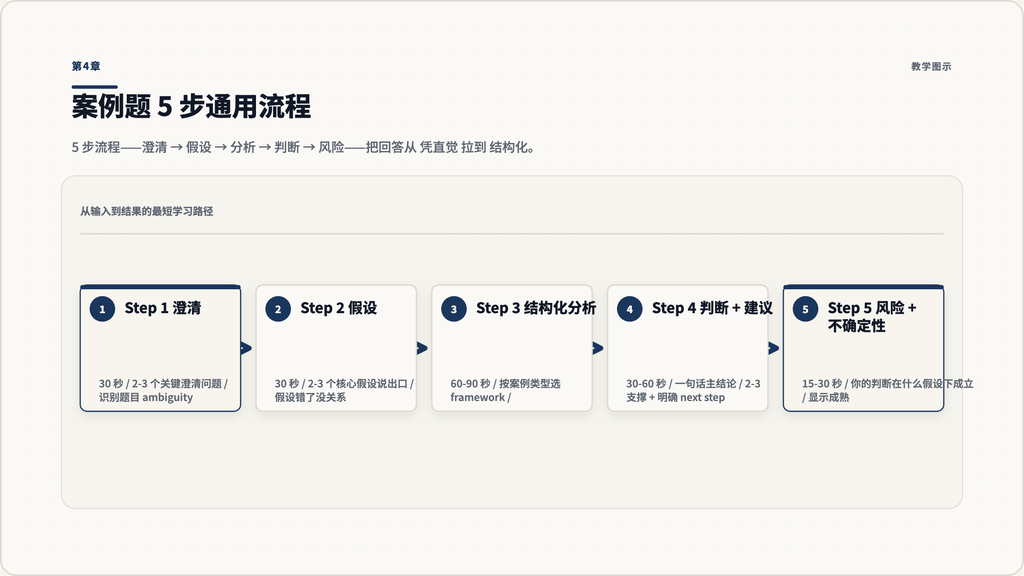

第4章：案例题 5 步通用流程

**图 4.1：案例题不是测知识，是测怎么想。5 步流程——澄清→假设→分析→判断→风险——把回答从 “凭直觉” 拉到 “结构化”。这 5 步可以套到任何案例题上。**

## 第5章 转型者的”为什么是你”：5 套桥梁陈述模板

### 5.1 转型者最大的面试障碍不是 EV 知识，是”为什么是你”

加拿大 EV BD 雇主在面对从科技/广告/出海行业进入的候选人时，潜意识里有三个怀疑：

1. **可信吗？** 你是不是看 EV 热就跳过来”赚一波”的？
2. **学得快吗？** EV 行业的产品、政策、客户跟你过去做的差异很大，你能多快赶上有 5 年汽车背景的同行？
3. **留得住吗？** 一旦 EV 行业有波动（2024-2025 已经出现），你会不会立刻跳回科技/广告？

这一章给你 **5 套桥梁陈述模板**——不是 5 个 Adam 的故事，而是 5 种**抽象骨架**。骨架来自常见转型路径，你要把自己的真实经历填进去。

> **使用规则**：不要把这里的句式整段抄走当成”我的故事”。面试官每天看 10 个候选人，模板化语言一眼就能识别。骨架是结构，故事必须你自己填，并且**你的真实细节才让骨架活过来**。

### 5.2 桥梁陈述的统一结构

不管哪种转型路径，“为什么是你”都有同样的四段骨架：

1. **承认差异**（10-15 秒）—— 不回避”我不是传统 auto 出身”
2. **桥梁能力**（30-40 秒）—— 你过去做的事和 EV BD 共享的 2-3 个核心能力
3. **EV 视角的证明**（20-30 秒）—— 你已经在 EV 行业做了什么具体动作（不是”我读了文章”，是”我跟 X 聊过”“我做了 Y 分析”）
4. **承诺**（10-15 秒）—— 你想在这家公司做什么、为什么是这家

总长度 75-100 秒。不要超过 100 秒。

### 5.3 五种典型转型路径与桥梁

加拿大 EV BD 的转型者通常来自以下五种路径。每条路径有自己的桥梁逻辑——找到你的路径，把骨架填上你的细节。

| # | 转型路径 | 核心桥梁能力 | 主要怀疑 | 化解角度 |
| --- | --- | --- | --- | --- |
| A | 科技 / SaaS BD → EV BD | B2B 长周期销售、多 stakeholder、量化思维 | “不懂硬件、不懂车” | 强调商业模式判断和客户决策链相似 |
| B | 广告 / 媒体销售 → EV BD | 大客户管理、品牌 narrative、渠道复杂度 | “卖广告和卖车完全不一样” | 强调 OEM 营销侧和品牌进入侧的接口 |
| C | 出海 / 跨境业务 → EV BD | 跨文化谈判、新市场建立、中国-海外桥梁 | “出海经验在加拿大能用吗” | 强调中国 EV 入加拿大的桥梁稀缺性 |
| D | 咨询 / 策略 → EV BD | 结构化分析、案例迁移、行业 mapping | “做过咨询不等于会落地” | 强调你具体的 client-side 执行经历 |
| E | 工程 / 产品 / 项目管理 → EV BD | 技术 fluency、跨部门协调、长项目周期 | “你之前没 carry 过 quota” | 强调你已有的 customer-facing 或 P&L 经历 |

### 5.4 模板 A：科技 / SaaS BD → EV BD

**骨架（你自己填具体经历）：**

> “我承认我不是传统汽车出身——我过去 [X 年，建议写’10+ 年’避开年龄信号] 主要在 [科技 / SaaS / digital] 行业做 B2B BD。但我做的事情底层和 EV BD 共享三条核心能力：

> 第一，**长周期 enterprise 销售**。我处理过 [具体场景，比如 6-18 个月销售周期 / 多 stakeholder 决策链 / 七位数合同结构]。EV BD 的 OEM 和电池厂 deal 也是这样的节奏——一年起步，多决策人，技术 + 商务双轨。

> 第二，**生态系统视角**。我不只是 close deal——我会判断这个客户在他的生态里在哪个位置、未来 12 个月他们最大的 leverage 点是什么。这是 EV BD 跟 OEM、Tier 1、充电运营商打交道的同一种思维。

> 第三，**学习速度**。过去 [X 个月]我已经做了 [具体动作：跟 N 个 EV 行业人聊过 / 读完两本 EV 教程 / 拆解过 3 家加拿大 EV 公司的财报]。

> 我选 [公司名] 是因为 [一个 specific reason——不是’公司很厉害’而是’你们最近在 X 上的动作让我看到 Y’]。”

**好答案的检查清单：**

- 不否认差异（直接说”我不是传统汽车出身”）
- 三条桥梁能力都有 specific example（不是空喊）
- “学习速度”部分必须有**已经发生**的动作（不能是”我打算学”）
- 结尾对这家公司的具体观察让面试官知道你做过功课

**跌跤点：**

- “我相信我能快速学”—— 空话，没有证据
- 把 SaaS 销售吹得跟 OEM 销售一样——面试官会觉得你不懂差异
- 不提为什么是这家公司——会被认为你在海投

### 5.5 模板 B：广告 / 媒体销售 → EV BD

**骨架（你自己填具体经历）：**

> “我之前 [X+ 年] 主要做 [广告平台 / 媒体 / 数字营销] 大客户销售，客户包括 [一两个抽象 archetype——‘全球品牌的中国市场团队’‘汽车类客户的 digital 投放预算’]。这跟 EV BD 不完全一样——我承认我没卖过车——但有三个底层动作是相通的：

> 第一，**大客户管理**。我管过单客户年化 [量级——七位数 / 八位数] 的合同，需要把 marketing / strategy / procurement / brand 四个对接面同时维持。EV OEM 跟客户（dealer 集团 / 大型 fleet）的关系也是这种多接口结构。

> 第二，**品牌进入 narrative**。我帮 [类似 archetype——‘某科技品牌进中国市场’‘某海外品牌做 NA digital 首发’] 设计过 GTM messaging。这套 narrative 思维放到 EV 里，是中国品牌进加拿大、新车型上市、技术认知教育的同一类问题。

> 第三，**渠道复杂度**。广告行业的’agency + 平台 + 客户’三角和 EV 行业的’OEM + dealer + 客户’三角在 incentive 设计、conflict 管理上非常像。

> 过去 [X 个月]我已经 [具体动作——‘跟 N 个 EV 行业人聊过’‘拆解了 Y 家公司的 dealer 渠道结构’‘读完两本 EV 教程做笔记 Z 页’]。

> 我选 [公司名] 是因为 [specific reason]。”

**好答案的检查清单：**

- 不把”我懂客户”说成”我什么都懂”
- “渠道复杂度”是广告 → EV 最强桥梁，不要省略
- “品牌进入 narrative” 部分给出你做过的具体 brand entry 例子
- 结尾对公司的观察具体

**跌跤点：**

- 强调”我懂数字营销”——EV BD 雇主不在乎这个，他们想要的是 customer-facing 销售能力
- 把广告卖给 brand 说成”卖产品给消费者”——这是错的，要承认 B2B 性质

### 5.6 模板 C：出海 / 跨境业务 → EV BD

这是 Adam-shape 的核心模板。**桥梁能力最强但需要小心**——出海经验在加拿大 EV 行业是稀缺资源，但”中国背景”在 2026 中美贸易环境下是双刃剑。

**骨架（你自己填具体经历）：**

> “我过去 [10+ 年] 主要做 [出海 / 跨境业务 / 中国-海外桥梁]，[抽象 archetype——‘帮某 archetype 公司从中国 Greater China business 转向 NA 市场’‘负责某区域市场的大客户’] 。

> 我承认我没有传统的本地汽车销售背景——但我相信我有三条加拿大 EV BD 现在最缺的能力：

> 第一，**中国-加拿大桥梁**。2026 BYD / Zeekr / Chery 都在试探进入加拿大。这些公司面对的不是单纯产品销售，是品牌信任建立、监管对接、渠道选择三件事。我过去 [X 年] 做的就是这件事——把一个外国品牌带到陌生市场的 0-to-1 阶段。

> 第二，**跨文化谈判节奏**。中国总部决策快、北美本地节奏慢、欧洲合规重——这三种节奏的协调能力是 EV 行业跨境项目里最稀缺的。

> 第三，**新市场建立**。我做过 [具体场景——‘某 archetype 公司在 X 市场从零到 Y 客户’‘负责某新业务线第一年 quota 设定和团队搭建’]。EV 在加拿大很多公司也是 0-to-1 阶段。

> 过去 [X 个月]我已经 [具体动作——‘跟 N 个加拿大 EV 公司里的人聊过’‘读完 Ch11+Ch13 of auto-industry-history 教程’‘拆解了 NextStar / Flo / AutoCanada 的结构’]。

> 我选 [公司名] 是因为 [specific reason——理想答案是把出海经验和这家公司的具体战略接上，比如’你们 2026 Q1 公开提到要建立中国 OEM partnership——这正是我过去 10+ 年在做的事的镜像版本’]。”

**好答案的检查清单：**

- 不把出海经验吹成”无所不能”——出海是工具不是 trump card
- “中国-加拿大桥梁”必须给出具体 specific——为什么这家公司需要这个桥梁
- “中国背景”用积极方式呈现（桥梁、敏感性），不要让对方觉得是政治风险

**跌跤点：**

- 让对方觉得你是来”游说中国品牌进入”——很多本土公司会反感
- 出海经验过度泛化（“我什么市场都能搞定”）——不可信
- 不提对当前中美贸易环境的判断——会显得不接地气

### 5.7 模板 D：咨询 / 策略 → EV BD

**骨架（你自己填具体经历）：**

> “我过去主要在 [咨询 / 战略 / corp dev] 做 [具体内容——‘帮 Fortune 500 客户做 GTM’‘帮 PE 做 due diligence’‘corporate strategy team’] 。

> 我承认我不是 carry quota 出身——但我相信我有三条能力对 BD 角色直接迁移：

> 第一，**结构化分析**。EV BD 案例题、客户画像、market entry 决策——所有这些底层都是案例分析。我过去做的就是这件事，只是客户场景是 EV 而不是 [我之前的行业]。

> 第二，**跨行业知识迁移**。在 [咨询 / 策略] 我同时处理过 [3-5 个行业 archetype]。EV 行业的很多商业模式问题（dealer disruption / D2C transition / cross-border partnership）我在其他行业见过 analog——这让我能快速判断什么 work、什么不 work。

> 第三，**面向 C-suite 沟通**。我习惯一句话给判断、给推荐、给风险。这是 BD 跟 CXO 客户沟通的同一种语言。

> 但我也想直接 acknowledge——咨询和 BD 最大差别是 **execution intensity**。我已经在 [当前 / 上一份角色] 做过 [specific——‘带过 X 个客户的 implementation’‘负责过具体 deal close’]。我不只是 PowerPoint。

> 过去 [X 个月]我已经 [具体动作]。

> 我选 [公司名] 是因为 [specific reason]。”

**好答案的检查清单：**

- **必须**主动承认”我没 carry 过 quota”——否则面试官会一直追问
- 用具体 execution 经历化解”咨询人只会做 deck”的标签
- 结构化分析能力要有具体 case 例子

**跌跤点：**

- 全程聊 framework 不聊 execution
- 用”我帮客户做战略”代替”我自己 close 了 deal”
- 把 BD 说成”对话设计”——这是咨询语言，EV BD 雇主会皱眉

### 5.8 模板 E：工程 / 产品 / 项目管理 → EV BD

**骨架（你自己填具体经历）：**

> “我过去在 [工程 / 产品 / 项目管理] 做 [具体内容]。我承认我不是传统销售出身——但我相信我有三条能力对 EV BD 是直接资产：

> 第一，**技术 fluency**。EV BD 经常需要跟客户的工程团队对话——电池规格、充电 protocol、车辆架构。我能说得过技术对话，不需要每次问产品团队翻译。

> 第二，**长项目周期**。我处理过 [具体——‘多年 multi-million 项目’‘跨地域产品 launch’‘供应链谈判’] ——这是 EV BD 的 deal cycle 长度。

> 第三，**跨部门协调**。我跟 [engineering / supply / marketing / finance] 都协作过——BD 角色最常被卡在这些接口上，我有现成的协调能力。

> 但我也直接 acknowledge——我没有 P&L ownership 历史。所以我已经 [具体动作——‘在当前角色主动接 customer-facing 工作’‘带过 N 个 customer pilot’‘参与过 commercial negotiation’]。这不是 BD 经验但是 BD 准备。

> 过去 [X 个月]我已经 [具体动作]。

> 我选 [公司名] 是因为 [specific reason]。”

**好答案的检查清单：**

- 强调技术能力但**不要变成工程师面试**——你是来做 BD 不是做 engineering
- 必须主动 acknowledge “我没 carry 过 quota”
- 给出已经在做 customer-facing 工作的具体证据

**跌跤点：**

- 全程聊技术细节——面试官会怀疑你想转回工程
- 不主动 acknowledge 销售经验缺口——会被认为不自知
- “我善于协调”没有具体例子

### 5.9 公共动作：所有模板都要做的三件事

无论你走哪条路径，桥梁陈述必须包含这三件已经发生的事：

1. **行业接触证据**：在过去 [X 个月 / X 周] 你做过的 EV-specific 动作（不是”我读了 Wikipedia”，是”我跟 N 个 EV 行业人聊过，跟某某做过 Y 小时的咨询对话”）
2. **公司具体观察**：对这家公司当下 specific 动作的判断（最近 6 个月的财报 / 招聘 / 产品 launch / 投资公告里挑一条）
3. **行业 narrative 判断**：你对 EV 行业当下大格局的一个简短判断（不是”EV 是未来”——是”2026 联邦废除 mandate + 新 EVAP 补贴 + Carney 政府新姿态 三件事一起改变了加拿大 EV 渗透节奏”）

这三件事的存在 = 你做了功课。缺一件 = 你被打折。

### 5.10 章末检查点

按你自己的转型路径，从 5 个模板里挑一个最贴近的，写出你自己的 75-100 秒版本。然后：

- 录音自听——节奏不超过 100 秒
- 三个公共动作都有具体证据
- 没有空话（“我相信”、“我能”、“我会”——这些都不算证据）
- 对公司有 specific 观察

如果你的版本任何一条不达标——重写。

[figure not shown]

第5章：5 种转型路径的桥梁陈述对照

## 第6章 5 类雇主深度研究模板（24-48 小时版）

### 6.1 为什么 24-48 小时是研究的极限节奏

加拿大 EV BD 面试的真实节奏：你周一收到面试邀请、周三或周四就要面试。给你的准备时间通常是 24-48 小时（部分大 OEM 给一周但电池厂 / 充电运营 / dealer 集团节奏更快）。

研究目标不是”我什么都知道”——是 **在 90 分钟面试里有 3-5 个让面试官 nod 的瞬间**。这些瞬间来自：

- 你知道一条他们最近 6 个月发生的事（让对方知道你做了功课）
- 你能 connect 他们这条事和宏观行业一条 dot（让对方知道你有判断）
- 你能提一个有质量的问题（让对方知道你思考过这家公司的真实问题）

这一章给你 **5 类雇主的研究模板**——每类都是 24-48 小时可执行的清单，不是 PhD 级别 deep dive。

> 配套提醒：companion 教程 Ch14 已经给过加拿大 EV BD **生态图**——本章不重复，而是把研究动作落到 5 类雇主每家的具体 checklist。

### 6.2 通用研究的 6 个维度

不管哪类雇主，下面 6 个维度都要扫一遍：

| 维度 | 数据点 | 来源（24-48h 可达） |
| --- | --- | --- |
| **公司当前状态** | 收入、员工数、地理布局、近期裁员/扩张 | LinkedIn About / 财报（如上市）/ Glassdoor 员工数 |
| **战略动作** | 最近 6 个月 PR / 投资 / 合作 / 产品 launch | 公司新闻页 + Google News 搜公司名+`site:linkedin.com` |
| **领导层** | CEO / CFO / VP Sales / VP BD 是谁、来自哪里、几年 | LinkedIn 公司页 + LinkedIn People |
| **竞争对手** | 直接竞品和间接竞品各 3 家 | 通过下面”5 类雇主 specific” 模板找 |
| **行业位置** | 在加拿大 EV 价值链哪个 segment | 见 Ch14 of auto-industry-history |
| **客户视角** | 这家公司服务谁、他们的客户怎么评价 | Glassdoor 客户/供应商点评 + 行业 podcast / Electric Autonomy 提及 |

> **24-48 小时分配建议**：维度 1-3 用前 6 小时；维度 4-6 用后 12-18 小时；剩下 24 小时用于 STAR / 桥梁陈述 / 反向提问准备。

### 6.3 五类雇主的研究矩阵

下面这张矩阵列出 5 类雇主各自的研究优先级。**在 24-48 小时里你不可能 6 个维度都做满**——按你面的雇主类型把重点放在 2-3 个维度。

| 雇主类型 | 维度 1 当前状态 | 维度 2 战略动作 | 维度 3 领导层 | 维度 4 竞争 | 维度 5 行业位置 | 维度 6 客户视角 | 最优先 |
| --- | --- | --- | --- | --- | --- | --- | --- |
| A. OEM 北美 / 加拿大业务 | 中（公开财报） | **高** | **高**（决策人多） | 中 | 中 | 中 | 2 + 3 |
| B. 电池厂 / 电池合资 | **高**（产能阶段） | **高**（客户合同） | 中 | 中 | **高**（FEOC / LRS） | 中 | 1 + 2 + 5 |
| C. 充电运营商 | **高** | 中 | 中 | **高**（市场份额） | 中 | **高**（用户口碑） | 1 + 4 + 6 |
| D. Tier 1 供应链 | 中 | **高**（合同 + RFQ） | 中 | 中 | **高**（OEM 客户面） | 中 | 2 + 5 |
| E. Dealer 集团 / 中国 EV 入加 | **高** | **高**（新品牌签约 / 渠道扩张） | 中 | **高**（dealer 集团相互竞争） | 中 | **高** | 1 + 2 + 4 + 6 |

### 6.4 雇主 A：OEM 北美 / 加拿大业务部门

**例子**：GM Canada、Ford Canada、Stellantis Canada、Toyota Canada、Hyundai Canada、Honda Canada

**研究最优先**：维度 2（战略动作）+ 维度 3（领导层）

**24-48 小时 checklist：**

1. **公司财报扫描**（2 小时）
   - 最近一个季度 earnings call summary（搜 “company name Q1 2026 earnings”)
   - 重点：EV 业务收入占比、capex 调整、北美/加拿大单独披露的数字（很多 OEM 把加拿大业务藏在”北美”里）
2. **2026 战略动作**（4 小时）
   - 搜 “[company] Canada EV 2026”
   - 重点 PR：新车型 launch、电池工厂、dealer 网络变化、政府补贴申请
   - 例子：Stellantis ARDC Windsor 扩到 800 人 / Honda Alliston 2030 推迟 / GM Ultium 暂停
3. **决策链 mapping**（3 小时）
   - LinkedIn 搜 “[company] Canada” + filter “head of / director / VP”
   - 找出你 likely 会汇报给的人 + 那个人汇报给谁 + 公司内部 BD 是直接 report 给 sales 还是 strategy
4. **大客户 / dealer 关系**（2 小时）
   - 大 OEM 的客户是 dealer 集团——所以是 AutoCanada / Pfaff 这类
   - 重点：哪些 dealer 是这家 OEM 的 top dealer / 哪些 dealer 同时卖竞品
5. **政策影响判断**（2 小时）
   - 2026-02 联邦废 mandate + 新 EVAP $5k 补贴对这家 OEM 意味着什么
   - 例子：GM 受益于 EVAP $50k 上限（Equinox EV 定价 sub-$50k）；Stellantis 部分 Wrangler 4xe 价格高于 $50k 受损

**面试官最常问的研究测试问题：**

- “你最近一次看到我们公司的新闻是什么？” —— 必须能答出 specific 一条
- “你怎么看 2026-02 联邦废 mandate 对我们的影响？” —— 必须有判断不是中性陈述

### 6.5 雇主 B：电池工厂 / 电池合资公司

**例子**：NextStar Energy（LG + Stellantis，Windsor，2025-11 投产）、PowerCo（VW，St. Thomas，2027 投产）、Honda Alliston（2030 推迟）、潜在 LG / SK / Samsung Canada 独资项目

**研究最优先**：维度 1（当前状态）+ 维度 2（战略动作）+ 维度 5（行业位置）

**24-48 小时 checklist：**

1. **产能阶段判断**（2 小时）
   - 这家厂是 (a) 建设期 (b) 投产前 6 个月 (c) 已投产 (d) 扩产期？
   - 例子：NextStar 2025-11 投产、PowerCo 2027 SOP 前期、Honda Alliston 还在前期土地
   - 产能阶段决定 BD 的工作内容（建设期 = 政府关系 + 供应商签约；投产期 = OEM 客户合同；扩产期 = 第二代客户拓展）
2. **客户合同公开信息**（4 小时）
   - 这家厂的 EV 客户是谁（Stellantis、Ford、GM、新势力？）
   - 搜 “[plant name] customer” / “[plant name] supply agreement”
   - 重点：合同长度、量级、客户多元化程度
3. **股权结构 + FEOC 风险**（2 小时）
   - 中国持股比例？关联交易？
   - 这影响后续 IRA-style 政策风险（加拿大目前无 FEOC 等价物但 USMCA 2027 审查可能改变）
4. **本地供应链**（3 小时）
   - 这家厂上游（锂、镍、阴极材料）从哪里来
   - 下游（pack 集成、整车）怎么连到 OEM
   - 加拿大本地有哪些 supplier （Magna / Linamar / 上游矿企）
5. **政府关系**（2 小时）
   - ISED / Innovation Canada / 省级政府给了多少 incentive
   - 公开承诺的就业数 + 实际达成
   - 例子：NextStar 承诺 2,500 jobs，实际 1,300+ at grand opening

**面试官最常问的研究测试问题：**

- “你怎么看我们这家厂 vs PowerCo 在产能时间表上的差异？”
- “FEOC 在加拿大目前不是直接 issue，但 USMCA 2027 审查可能怎么影响我们？”

### 6.6 雇主 C：充电运营商 / 基础设施

**例子**：Flo（加拿大本土最大独立）、Petro-Canada Electric Highway、Electrify Canada（VW 系）、ChargePoint Canada、Tesla Supercharger Canada team

**研究最优先**：维度 1（当前状态）+ 维度 4（竞争）+ 维度 6（客户视角）

**面试官最常问的研究测试问题：**

- “我们的最大挑战之一是 uptime。你在 [科技 / 出海 / 广告] 行业有没有处理过类似的 ops 问题？”
- “你认为 Flo 跟 Tesla Supercharger 怎么 differentiate？”

### 6.7 雇主 D：Tier 1 供应链 / 零部件

**例子**：Magna E-Mobility、Linamar e-mobility、Martinrea、Multimatic，及其他主要 OEM 供应商的加拿大业务

**研究最优先**：维度 2（战略动作）+ 维度 5（行业位置）

**24-48 小时 checklist：**

1. **OEM 客户 portfolio**（4 小时）
   - 这家公司的 top OEM 客户（GM / Ford / Stellantis / Toyota / Hyundai / 中国 OEM？）
   - 哪些是 ICE 业务、哪些是 EV 业务
   - 例子：Magna 在传统 ICE 给 BMW / Mercedes 等做 contract 制造；EV 给 Fisker（已破产）/ Lion Electric 等
2. **EV 转型阶段**（3 小时）
   - Tier 1 的 EV 转型是产品组合的 portion shift——查公司财报里 EV 业务收入占比、EV-related capex
   - 例子：Magna 2025 EV 业务约 20% 收入但增长快；Linamar e-mobility 2025 占比仍小
3. **产品/服务定位**（2 小时）
   - powertrain（电机、变速箱）/ chassis / body / electronics 哪个细分
   - 跟其他 Tier 1 是 competing 还是 complementary
4. **国际化布局**（2 小时）
   - 加拿大业务 vs 全球——很多 Tier 1 把加拿大作为北美 hub
   - 中国/欧洲业务怎么影响加拿大决策
5. **政府 incentive**（2 小时）
   - 加拿大 SIF / Strategic Innovation Fund / Innovation Canada 给的资金
   - 这影响公司战略走向

**面试官最常问的研究测试问题：**

- “我们最近赢的最大 EV contract 是什么——你怎么看这个 deal 的战略价值？”
- “Tier 1 在 EV 转型里跟 OEM 的 negotiation power 怎么变化？”

### 6.8 雇主 E：Dealer 集团 + 中国 EV 进加拿大

**例子**：AutoCanada（最大上市 dealer 集团）、Pfaff（高端 GTA）、Quebecor Auto、BYD Canada、Zeekr Canada、Chery Canada、Lion Electric（电动卡车 / 巴士）

**研究最优先**：维度 1 + 2 + 4 + 6 都重要

**24-48 小时 checklist（按类细分）：**

**E1. Dealer 集团（如 AutoCanada）：**

1. **门店数量 + 品牌组合**：AutoCanada 66 加 dealer + 18 美 + 25 品牌——这是公开数据
2. **EV 品牌签约动作**：最近 6 个月新签或谈判中的品牌（中国 EV / 新势力？）
3. **财报 EV 占比**：传统 ICE vs EV 销量、毛利结构
4. **dealer-OEM 紧张点**：从公开新闻看 dealer 集团跟哪家 OEM 关系紧张

**E2. 中国 EV 进加拿大（如 BYD / Zeekr）：**

1. **进入阶段判断**：(a) 招聘阶段 (b) 注册公司 (c) 试销 (d) 量产
   - BYD：2026 Q1 招了 Markham consultancy 找 20 个 dealer point
   - Zeekr：2026-04 招了 7 个 Toronto 高级岗位
2. **产品定位**：哪个 segment、价格带、目标客户
3. **渠道策略**：直营 vs dealer vs 混合（BYD 走 dealer，Zeekr 早期可能直营）
4. **关税路径**：怎么处理 100% 关税（PHEV / 商用车 / 高端 BEV 哪条路？）
5. **本地团队规模**：LinkedIn 搜 “[brand] Canada” 看现有员工数

**面试官最常问的研究测试问题：**

- AutoCanada 类：“你怎么看 dealer 集团接中国 EV 品牌的 risk vs upside？”
- BYD/Zeekr 类：“你怎么看 100% 关税对我们的 pricing strategy？”

### 6.9 24-48 小时通用时间表

| 时段 | 任务 |
| --- | --- |
| T-48h（收到邀请当天晚） | 公司公开页面 + LinkedIn About（30 min） |
| T-42h | 财报或 PR 扫描（2-3h） |
| T-36h（次日上午） | 领导层 mapping + 决策链（3h） |
| T-30h | 行业位置 + 竞争对手对照（2h） |
| T-24h | 最近 6 个月新闻和 LinkedIn posts 深扫（3h） |
| T-18h | 写出 3 个让你 nod 的 specific 数据点 |
| T-12h | 写 3 个反向提问（见 Ch9） |
| T-6h | 短暂复盘 + 休息 |
| T-3h | 最后核查所有数字时效性（小数据 30 min） |
| T-30min | 复盘”3 个 nod 瞬间” |

### 6.10 章末检查点

挑一家加拿大 EV 公司（不是你下一场要面的——是练习），用这章模板做 24 小时研究。然后问自己：

- 我有 3 个 specific 数据点（不是 generic 行业事实）吗？
- 我能写出这家公司当下面对的 top 3 strategic challenges 吗？
- 我有 3 个 specific 反向提问吗？
- 我对这家公司的领导层有人物 mapping 吗（不需要私下信息，公开 LinkedIn 数据即可）？

四个问题三个以上 yes 才算过关。

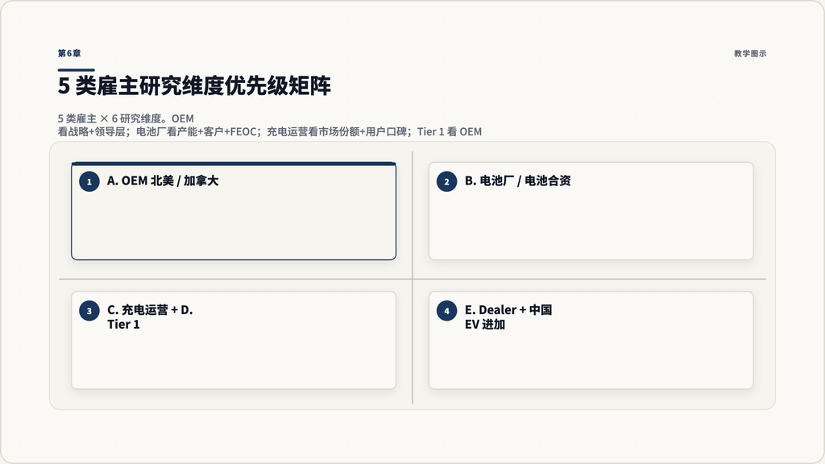

第6章：5 类雇主研究维度优先级矩阵

**图 6.1：5 类雇主——OEM / 电池厂 / 充电运营 / Tier 1 / Dealer+中国 EV——在 6 个研究维度上的优先级。OEM 看战略+领导层；电池厂看产能+客户合同+FEOC；充电运营看市场份额+用户口碑；Tier 1 看 OEM 客户面；Dealer+中国 EV 全维度都重要。**

## 第7章 5 类对抗性问题的多套 reframe 路径

### 7.1 对抗性问题不是要难倒你，是要测你的”自我认知 + 抗压 + 转化能力”

EV BD 面试里，**几乎所有转型者都会遇到对抗性问题**。常见的 5 类是：

1. “你没卖过车——你怎么知道你能 carry quota？”
2. “你不是工程出身——技术对话你怎么撑得住？”
3. “你不是加拿大人 / 你之前不在加拿大工作——你的本地 network 在哪里？”
4. “你的期望薪资 / 职位 比我们想要的高——为什么我们应该给你这个 band？”
5. “你年纪 / 资历偏大——你愿意做 individual contributor 吗？” 或反向 “你太年轻——你能跟 50+ dealer GM 平等对话吗？”

这些问题的真正测试不是答案内容——是：

- **你有没有自我认知**（你是不是 already aware of the gap）
- **你的抗压姿态**（你是慌、是 defensive、还是 calmly engage）
- **你能不能 reframe 让对方看到一面新的**（不是说服对方，是给他换个角度）

每类问题我给你 **3 套 reframe 路径**——根据面试场景选最贴近的那条。**绝对不要把三条都背下来照搬**——挑一条，结合你的真实经历填出 specific。

### 7.2 通用 reframe 三步法

不管哪类对抗性问题，处理步骤都是：

1. **承认（5-10 秒）** —— 不否认 gap、不假装无所谓
2. **重新框定（20-30 秒）** —— 把对方关心的问题翻译成你能回答的问题
3. **具体证据 + 风险化解（20-30 秒）** —— 你已经做了什么、对方面对的剩余 risk 你怎么 mitigate

**最危险的反应**：

- 否认（“我其实算是有车的经验”）
- 防御（“我不觉得这是问题”）
- 转移（“那是另一个问题”）
- 过度道歉（“对不起我没经验”）

承认 + reframe + 具体——这是唯一有效的姿态。

### 7.3 类型 1：“你没卖过车”

**面试官真实关心**：你能不能在 OEM / dealer / fleet 客户面前 carry quota——不是字面”卖过车”，是**carry 长周期、大金额、技术-商务并重 deal 的能力**。

**Reframe 路径 A：把销售本质拆出来**

> “我承认我没卖过车——但我相信他们在测的能力不是’摸过几台车’，而是 carry 长周期 + 多 stakeholder + 技术-商务并重 deal 的能力。

> 我过去 [X 年] carry 过 [量级——七位数 / 八位数] 单合同，决策链 [N+ stakeholder]，从 prospect 到 close 平均 [X 个月]。这和 OEM dealer deal 的节奏不是一样的事情？

> 我承认我会有一个 ramp-up——我需要 3-6 个月 learn 行业 product 细节、客户 territory、本地 dynamics。我已经在做这件事——[具体动作，比如’跟 N 个 EV 行业人聊过’‘拆解了 Y 家公司 financials’]。”

**Reframe 路径 B：把”卖过”重新定义为”carry 过”**

> “我可以 acknowledge 我没卖过车——但我 carry 过 [类似类型] deal。具体讲一个例子：[填你最 BD-like 的故事——多 stakeholder + 长周期 + 技术-商务并重]。

> 这个 deal 跟 EV BD 的不同在 [一个 specific 差别，比如’我之前的 deal 客户不需要工厂参观’] —— 我承认这是要补的。但底层 skill 是迁移的。”

**Reframe 路径 C：把对方的怀疑转换成”招我的 upside”**

> “我承认这是一个 gap——但也是 upside。

> 你们现在已经有 5-10 个有 auto 背景的 BD candidate 来面——他们会用同一种方式 sell EV。我能带来一个不同视角——[你的差异化背景应用到 EV 的 specific 思路]。

> 风险是 ramp-up——我承认。但我对自己设的 ramp-up 指标是 [具体 something——‘90 days 拿下第一个 customer meeting’‘180 days close 第一个 small deal’]。”

**通用跌跤点：**

- 假装自己有车的经验
- 过度补偿（讲一堆 EV 知识但没回答销售能力问题）
- 把”没卖过车”轻描淡写（“哦那个不重要”）—— 面试官会觉得你不自知

### 7.4 类型 2：“你不是工程出身”

**面试官真实关心**：你能不能在跟 OEM 工程团队 / 电池工程师 / 充电技术架构师对话时不掉队——这关系到 deal closure 时能不能撑住客户的技术提问。

**Reframe 路径 A：技术 literacy ≠ engineering**

> “我承认我不是工程出身——但我相信 BD 需要的是技术 **literacy**，不是 engineering depth。

> 我需要的是能跟工程团队对话的能力：理解 [BEV 平台架构 / 800V vs 400V / NACS vs CCS / NMC vs LFP] 这些核心 trade-off、能 translate 客户技术需求到产品团队、能在 deal 卡在技术议题时知道该 escalate 给谁。

> 这些我已经具备——[具体动作，比如’读完 EV 技术知识教程并做笔记’‘跟 N 个工程 friends 聊过’‘能讲清楚 LFP vs NMC 的 trade-off’]。”

**Reframe 路径 B：销售人 +技术人组合的优势**

> “BD 这个角色的 reality 是——客户技术问题里 90% 是 routine 的（电池容量、续航、保修期、充电时间），10% 是 deep（深度 architecture）。

> 90% 我已经 cover——[证据]。10% deep 部分，我学过的方法是 [proactively pair with engineer / pre-meeting brief]。

> 我没卖给客户一个虚假的工程身份——我的 positioning 是 ‘business person who deeply understands the technology that matters to your decision’。这往往比纯工程背景的 BD 在 close phase 更有效，因为我能 translate 而不是 over-engineer 答案。”

**Reframe 路径 C：客户不需要工程师 BD**

> “我反思过这个问题——大部分 EV BD 的客户（OEM 商务团队 / dealer GM / fleet manager）也不是工程背景。他们需要的是能用商业语言讲技术 trade-off 的人。

> 我过去 [行业] 的经验本身就是把 [复杂技术——SaaS / 广告算法 / cross-border logistics] 翻译成商业判断。这是同一种技能，应用到 EV。”

**通用跌跤点：**

- 装工程师（背术语但不理解 trade-off）—— 一问深就破
- 否认技术重要（“BD 不需要懂工程”）—— 面试官会觉得你不接地气
- 不给学习方法 / 已有动作

### 7.5 类型 3：“你不是加拿大人 / 你 network 在哪里？”

这个问题对从中国大陆 / 美国 / 其他国家来加拿大的转型者尤其常见。**面试官真实关心**：你能不能短期内激活客户关系——不是文化身份问题，是 ramp-up 速度问题。

**Reframe 路径 A：network 是要建的，但你有 toolkit**

> “我承认我的现有 network 不是 auto / EV-specific 加拿大本地的。但我相信 network 是动作不是 static asset——我有清晰的 90-day plan 来建 network：
> - 周 1-2：约见 [N] 个目前已经在 EV 行业的 contact（具体路径——LinkedIn / Electric Autonomy events / 行业人介绍）
> - 月 1-3：参加 [具体 events——CTA / Move 2026 / OEM forum]
> - 月 3-6：通过 customer-facing 工作自然 build network

> 我已经开始这件事——过去 [X 周] 我已经跟 [N 个] EV 行业人聊过。”

**Reframe 路径 B：你的非加拿大 network 是这家公司的稀缺资源**

> “我承认我在加拿大本地 network 是要建的——但我 acknowledge 你们也在评估是否要补的 network 不是 generic 的，是 [中国 OEM / 美国 OEM / 欧洲 partner] 这种 specific 方向。

> 我过去 [N 年] 建的 network 正好在 [一个 specific 维度——中国 OEM HQ / 北美科技 ecosystem / EU policy circle]——这是你们 in-house 本地 BD 没有的。

> 我可以 commit—— 第一年用 50% 时间建本地 network，但带入 [我已有 network] 的 access 作为差异化。”

**Reframe 路径 C：本地不等于本地化能力**

> “我反思过——‘是加拿大人’不等于’有 EV BD 本地能力’。本地能力是关系建立的速度、对市场 dynamics 的判断、对监管的理解——这些都是工作 12-18 个月内建得起来的。

> 我已经做的 specific actions：[读了 Ch11 of auto-industry-history 教程详尽分析加拿大政策 / 拆解了 NextStar 和 Flo 的本地 dynamics / 跟 N 个本地 industry 人聊过]。

> 我不会说’我已经是本地了’——但我会说’我已经具备开始本地化 work 的底子’。”

**通用跌跤点：**

- 否认 gap（“我其实有很多加拿大朋友”）
- 把 network 量级吹高
- 不给 specific 90-day plan

### 7.6 类型 4：“你的期望偏高”

**面试官真实关心**：你的薪资期待跟公司预算 / band 是否对齐——也可能是测试你 negotiation 姿态。

**Reframe 路径 A：把数字 reframe 成价值**

> “我可以 acknowledge 数字可能比 baseline 高——但我希望我们一起讨论的是 value 不是 number。我提的数字基于 [3 个 inputs——市场 benchmark / 我能带来的具体贡献 / 我 forgo 的 alternative]。

> 如果你们觉得这个数字偏高，我想了解 your band 是怎么 frame 的——是 budget hard limit 还是有 flexibility based on demonstrated value？我愿意讨论结构（base / variable / equity / sign-on）。”

**Reframe 路径 B：跨行业 benchmark 解释 gap**

> “我承认从 [auto / EV] industry pure benchmark 看，可能偏高。但我的 reference point 是 [科技 / SaaS / 出海 / 咨询] industry——那里 BD comp 普遍高 [%]。

> 我不是要求 industry 给 [我之前] 的 comp ——我已经下调过期望。我现在提的是 [科技] 和 [auto] 中间值——这反映了我 acknowledge industry difference 同时 protect 自己的 baseline。”

**Reframe 路径 C：愿意 flex 但要 transparent 讨论**

> “我可以 negotiate——但希望讨论是 transparent 的。可以告诉我你们 band 的 range 吗？如果 range overlap 部分有的话，我们可以 work toward。

> 如果 fundamentally 我的数字超出 band，我也希望明白早——我不想浪费双方时间。”

**通用跌跤点：**

- 立刻让步（暴露你 fear of losing）
- 死扛数字不给解释（让对方觉得你不灵活）
- 不问对方 band（这是 negotiation 的核心 ask）

### 7.7 类型 5：“你年纪 / 资历偏大（或太年轻）”

**面试官真实关心（偏大版）**：你愿不愿意 individual contributor、报告给比你年轻的 manager、ramp-up 期间没有立刻的 leverage。**真实关心（太年轻版）**：你能不能跟 50+ 岁 dealer GM 平等对话、客户会不会 take seriously。

**Reframe 路径 A（偏大）：经验是配置不是包袱**

> “我承认我有 [10+ 年] 的经验——这是 reality。我不希望 reframe 经验为’fresh 像新人一样’——那是不诚实。

> 我希望讨论的是经验怎么 deploy。我看到的 reality：本职 BD 工作 80% 是 customer-facing execution。我愿意 commit ICs role + 让经验做以下事情：
> - 客户最快 build trust（年长经验在 dealer + OEM 客户面前是 asset）
> - 内部 mentor 给更年轻 BD
> - bring industry pattern recognition 但不 micromanage manager 决策

> 我也 acknowledge 我会有一些 unlearning to do——加拿大节奏、EV 行业 etiquette、新工具栈。”

**Reframe 路径 B（偏大）：报告给年轻 manager 的 working style**

> “我已经 reflect 过这一点——我会报告给年轻 manager 的可能性高。我的 commitment 是：
> - 在 manager 面前直接 acknowledge their authority + 寻求 input
> - 不 over-step——他们的决策即使我不同意，我也执行后给 feedback
> - 把经验当 resource available on demand，不主动 push

> 这不是我装出来的——我过去 [N 年] 已经报告给比我年轻或同龄的 leader——[具体 example]。”

**Reframe 路径 A（太年轻）：年龄不是 credibility 的代理**

> “我可以 acknowledge 我年纪不大——但我相信 dealer GM 和 OEM 客户真正 measure 的是：你懂不懂他的 business、能不能解决他的问题、说话 reliable 不 reliable。

> 这些都不需要年纪。我有 [具体证据——‘过去 X 年我每周都跟比我年长 20 岁的 [archetype 客户] 打交道’‘我管的客户里有 [N 个] 都是 senior executive level’]。

> 第一次见 dealer GM 时我不会假装 senior——我会用 substance + respect 让对方知道我有备而来。”

**通用跌跤点：**

- 否认年龄相关 reality
- 过度补偿（讲一堆经验试图证明）
- 不给 working style commitment

### 7.8 全章核心：对抗性问题的”姿态体操”

整个过程 **不超过 90 秒**。超过 90 秒说明你在 defending，对方已经停止 listening。

### 7.9 章末检查点

挑 5 类问题里最让你 nervous 的两类。把你的 reframe 路径写出来——然后录音自听 3 次。每次问：

- 第一句是 acknowledge 还是 defend？
- 我有没有给 specific 证据？
- 90 秒以内有没有结束？
- 我有没有给对方一个”换角度看”而不是”说服我接受”？

如果 90 秒结束时面试官没有 nod——这个 reframe 还不够。

[figure not shown]

第7章：5 类对抗性问题的 reframe 路径对照

## 第8章 5 类雇主面试流程差异

### 8.1 流程不是细节，流程是雇主的”决策结构”

很多转型者把面试当成”5-6 个 1on1 问答”——这是误读。**面试流程本身就是雇主组织决策结构的镜像**：

- OEM 5-6 轮 = 多 stakeholder 共识决策的常规节奏
- 电池厂 4 轮 + 技术筛 = 技术-商务双轨决策
- 充电运营 3 轮 SaaS 节奏 = 速度优先 + 一个 hiring manager 主导
- Tier 1 4 轮 + 工厂参观 = 实操能力 + culture fit
- Dealer 集团 / 中国 EV 进加 2-3 轮快节奏 = 决策权集中

理解面试流程 = 理解谁有 yes 权、谁有 veto 权、每轮的 distinct 测试目标。

这一章用 **layer 视角** 把 5 类雇主面试流程拆开，每类给你：

- 轮次与时间表
- 每轮见谁 + 每轮测什么
- 决策人和决策机制
- 准备节奏建议

### 8.2 5 类雇主面试流程 overview

| 雇主类型 | 总轮次 | 总时间跨度 | 决策机制 | 最难的一轮 |
| --- | --- | --- | --- | --- |
| A. OEM 北美 | 5-6 | 6-10 周 | 多 stakeholder consensus，HRBP 协调 | 第 3-4 轮 senior cross-functional panel |
| B. 电池厂 / 电池合资 | 4-5 | 4-6 周 | 技术 lead + 商务 lead 双签 | 第 3 轮技术 deep-dive |
| C. 充电运营商 | 3-4 | 2-3 周 | hiring manager 主导 + VP 拍板 | 第 2 轮 hiring manager 案例 |
| D. Tier 1 供应链 | 4 + 工厂参观 | 4-5 周 | functional VP + plant manager | 工厂参观 + plant manager 1on1 |
| E. Dealer 集团 / 中国 EV 进加 | 2-3 | 1-2 周 | CEO / GM 直接决策 | CEO 一轮定生死 |

### 8.3 雇主 A：OEM 北美 / 加拿大业务

**示例**：GM Canada、Ford Canada、Stellantis Canada、Toyota Canada、Hyundai Canada、Honda Canada

**典型流程（5-6 轮，6-10 周）：**

**轮次 1：HR / 招聘协调（30 min phone）**

- 见 HRBP 或 recruiter
- 测什么：基础 fit、薪资 expectation、relocation 意愿、visa status
- 备战：你的 STAR 短版 + 期望薪资 range（不是一个数字，是 range）

**轮次 2：Hiring Manager 第一轮（45-60 min phone or video）**

- 见你 likely 报告给的 director / senior manager
- 测什么：角色 fit、行业 reasonable answers、文化匹配
- 备战：5 个最强 STAR + 桥梁陈述完整版 + JD 拆解（Ch1）

**轮次 3：Cross-functional Panel（60-90 min on-site or video，2-4 人同时）**

- 见 sales VP / strategy / marketing / 偶尔 finance
- 测什么：你能不能在多 stakeholder 面前 hold ground + 跨部门思维
- 备战：5 个 STAR 故事的不同切面 + 反向提问准备多角度
- **这一轮最难**——多个面试官同时挑战，节奏不在你这里

**轮次 4：Senior Leadership（30-60 min，VP 或 GM 级别）**

- 见 sales VP 或 GM Canada
- 测什么：你的 strategic thinking + 你能不能在公司 narrative 里加 value
- 备战：行业宏观判断 + 这家公司的战略 specific 观察 + 反向提问质量

**轮次 5：Reference + Background Check**

- HR 联系 reference
- 备战：提前准备 3 个 reference + 给他们 brief 你应聘的 role 和 priorities

**轮次 6（可选）：Offer + Negotiation**

- 见 HRBP，可能 hiring manager 在线
- 备战：见 Ch10 薪资谈判脚本

**决策机制**：HRBP 协调 + hiring manager 推 + senior leader 拍板。如果 cross-functional panel 里有人强烈反对，offer 大概率不发。

### 8.4 雇主 B：电池厂 / 电池合资

**示例**：NextStar Energy、PowerCo Canada、Honda Alliston（前期）、潜在韩国电池厂北美业务

**典型流程（4-5 轮，4-6 周）：**

**轮次 1：HR / Talent Partner（30 min）**

- 测什么：fit、为什么对电池行业感兴趣、技术敏感度
- 备战：你对电池行业的具体观察（不是”我喜欢可持续”——是”我看到 NextStar 2025-11 投产，跟 Stellantis 的合同结构是 […]“）

**轮次 2：Hiring Manager（60 min）**

- 见 commercial lead 或 BD VP
- 测什么：BD-specific 能力 + 长周期合同思维
- 备战：5 个 STAR 重点放 long-cycle deal 和 multi-stakeholder

**轮次 3：技术 Deep-Dive（60-90 min）**

- 见 chief commercial officer 或 product manager 或 engineering lead
- 测什么：技术 literacy 够不够、能不能跟 OEM 工程对接
- **这是电池厂特有的关卡**——很多转型者卡在这一轮
- 备战：背 EV 技术知识教程 + 能 articulate NMC vs LFP / cell vs pack / BMS 等
- **重要**：不要装工程师——要 articulate trade-off 不要装深度

**轮次 4：Strategy + Plant Tour（60-90 min on-site，可能含厂区参观）**

- 见 plant general manager 或 VP operations
- 测什么：你看到工厂能问什么有 substance 的问题、你的 customer-facing thinking
- 备战：提前 study plant 的 capacity、客户合同、本地 supply chain；准备 3-5 个工厂参观相关的有质量的问题

**轮次 5：Senior Leadership（30-60 min）**

- 见 CEO 或 country head
- 测什么：strategic value、long-term fit
- 备战：宏观行业判断 + 这家公司 5 年战略你的 take

**决策机制**：commercial lead 和 plant GM 双签——一票否决严重。

### 8.5 雇主 C：充电运营商

**示例**：Flo、Petro-Canada Electric Highway、Electrify Canada、ChargePoint Canada

**典型流程（3-4 轮，2-3 周——SaaS-style 节奏）：**

**轮次 1：Recruiter / Hiring Manager 短轮（30 min phone）**

- 见 recruiter 然后 hiring manager 通常背靠背
- 测什么：基础 fit、行业 enthusiasm、carry quota 经历
- 备战：短版 STAR + carry quota 的 specific 数字

**轮次 2：Hiring Manager Case + Behavioral（60-90 min video or in-person）**

- 见你 likely 报告的 director
- 测什么：BD execution capacity、客户类型理解（site host / fleet / utility）
- **这一轮通常包含 mini case**——例如”我们要拿下 X 大型 fleet 客户，你 first 30 days 怎么 approach？”
- 备战：Ch4 的 5 步通用流程 + 充电行业 specific 客户类型

**轮次 3：VP Sales / VP BD（45-60 min）**

- 见 VP 级别
- 测什么：strategic alignment、公司 narrative fit、你能给公司加什么 unique
- 备战：行业宏观 + 这家公司 differentiation 判断

**轮次 4（可选）：CEO 或 founder（30-45 min）**

- 小公司会有 CEO 直接 chat
- 测什么：culture fit、long-term commitment
- 备战：你想 5 年内做什么、为什么这家

**决策机制**：hiring manager 主导（他 carry quota，他选自己 team），VP 拍板——比 OEM 更 single-point decision。

### 8.6 雇主 D：Tier 1 供应链

**示例**：Magna E-Mobility、Linamar、Martinrea，及其他 Tier 1 的 EV / e-mobility 部门

**典型流程（4 轮 + 工厂参观，4-5 周）：**

**轮次 1：HR + Hiring Manager 联合（45-60 min phone or video）**

- HR 在通话开始 5 min，然后 hiring manager 接手
- 测什么：fit + 技术 literacy 基础 + 客户 portfolio 理解
- 备战：知道这家公司的 top 5 OEM 客户 + EV business portion

**轮次 2：Cross-functional 商务（60-90 min）**

- 见 commercial team 2-3 人
- 测什么：RFQ 经验、program management 思维、cost roadmap 理解
- 备战：long-cycle deal + multi-year contract + cost discipline 的 STAR

**轮次 3：技术 / 工程 lead 对话（45-60 min）**

- 见 product 或 engineering VP
- 测什么：技术 fluency（不是 engineering depth）+ 跨工程沟通能力
- 备战：technical literacy 的 specific 证据

**轮次 4：工厂参观 + Plant Manager 1on1（60-90 min on-site）**

- 走完一遍 production line + 跟 plant manager 1on1
- 测什么：你能不能在 plant context 里问对的问题、你的 culture fit（Tier 1 是 hands-on 文化）
- 备战：提前研究 plant 产能 + 主要产品 + 现场问题准备
- **这是 Tier 1 特有的**——表现好这一轮基本就稳

**轮次 5（可选）：Senior Leadership（30 min）**

- VP 或 SVP
- 测什么：long-term fit
- 备战：strategic narrative

**决策机制**：commercial VP + plant manager 双签。**Plant manager 的 voice 比想象中更重**——他对”这个人能不能在 plant 文化里 work”有 veto。

### 8.7 雇主 E：Dealer 集团 / 中国 EV 进加拿大

**示例**：AutoCanada、Pfaff、Quebecor Auto、BYD Canada、Zeekr Canada、Chery Canada

**典型流程（2-3 轮，1-2 周——决策最快）：**

**轮次 1：CEO / GM / Country Head（45-60 min）**

- 这类雇主 BD role 通常是 senior role，直接见 top
- 测什么：你能不能 trust、你的行业 read、你的 commitment 长度
- 备战：行业宏观 + 这家公司 specific 现状 + 你愿意 commit 几年

**轮次 2（可能）：Operating Team（60 min）**

- 见 sales VP 或 operations head
- 测什么：execution capability
- 备战：execution-heavy STAR

**轮次 3（可能）：Founder / Investor（30 min）**

- 小公司或新进入品牌会有
- 测什么：strategic narrative、cultural fit
- 备战：完整桥梁陈述 + 长期 vision

**特别 sub-type：中国 EV 进加拿大公司（BYD / Zeekr / Chery）**

- 流程可能更非标——会 mix 中文电话 + 英文 panel
- 中方 HQ 可能 involve - 你要准备同样的故事中英文版本
- 总部 senior 可能突然加 round
- 备战：中英文 STAR 双语版 + 对中国 EV 出海 narrative 的判断 + 对加拿大本地化的 plan

**决策机制**：CEO / GM 一人定生死。一轮表现差就 game over。

### 8.8 跨雇主类型的共同节奏建议

不管哪类雇主，下面这套 **准备时序** 通用：

| 阶段 | 动作 | 时间 |
| --- | --- | --- |
| **预申请** | 简历 tailor + LinkedIn 优化 + 桥梁陈述准备 | 一次性 |
| **HR 轮前** | 公司基础研究（Ch6 维度 1-3）+ 薪资 range 准备 | 2-3 h |
| **Hiring manager 轮前** | 深度研究（Ch6 全 6 维度）+ 5 个 STAR 准备 | 8-12 h |
| **Panel / Technical 轮前** | 拆解 likely 面试官背景 + Case 流程练习 + 反向提问 | 6-8 h |
| **Senior leader 轮前** | 行业宏观 + 公司 strategic narrative 复盘 + 你的 5-year vision | 4-6 h |
| **轮间** | 每轮后立刻写下”我说了什么/没说”+ “下一轮怎么调” | 30 min |

### 8.9 决策人 mapping 速查

每类雇主的”真正决策人”通常不是面试你最多的那个人。下面速查：

| 雇主类型 | 表面决策人 | 隐藏关键决策人 |
| --- | --- | --- |
| OEM | hiring manager | senior VP（panel 后面） + HRBP（pacing） |
| 电池厂 | commercial lead | plant GM（一票否决） |
| 充电运营 | hiring manager | VP Sales（quota commitment） |
| Tier 1 | commercial VP | plant manager（culture fit veto） |
| Dealer / 中国 EV | CEO/GM | 实际就是这个人 |

提前知道隐藏决策人 = 准备时优先级 calibrated 正确。

### 8.10 章末检查点

挑你下一场要面的雇主类型——按这一章的轮次结构，列出：

- 总轮次 + 时间跨度
- 每轮见谁
- 每轮测什么
- 我每轮的备战时间分配
- 决策人 mapping

如果你能在 10 分钟内填完——这一章过关。

[figure not shown]

第8章：5 类雇主面试流程分层对照

**图 8.1：5 类雇主的面试流程分层——OEM 5-6 轮 6-10 周；电池厂 4-5 轮 4-6 周技术 deep-dive 关键；充电运营 3-4 轮 SaaS 节奏；Tier 1 4 轮含工厂参观；Dealer/中国 EV 2-3 轮 CEO 直决。决策人 ≠ 面试官最多的那个。**

## 第9章 反向提问题库：按角色 × 轮次分层

### 9.1 “你有什么问题” 是面试的隐形评估时刻

每场面试最后 10-15 分钟，面试官会说”你有什么问题问我？“——大多数候选人在这一刻被打分却不自知。

面试官在测三件事：

1. **你的研究深度**——空洞的问题（“公司文化怎么样？”）暴露你没做功课
2. **你的策略思维**——好问题让对方意识到你在看 macro 不只 micro
3. **你的决策成熟度**——你问的问题揭示你 evaluate 这家公司 vs 其他 opportunity 的标准

**最大的反向提问错误**：

- 问 Google 能答的问题（“你们最近的财报怎么样？”）
- 问 HR 已经答过的问题（薪资、福利、PTO——这些留给 offer phase）
- 问”open-ended generic”问题（“你最喜欢这里什么？”——这是 small talk 不是 BD-level 问题）
- 同一个问题问每一轮的所有面试官（暴露你没 calibrate）

**好反向提问的标准**：

- 对方要 think for 5+ seconds 才能答
- 对方答完会反过来 anchor 你（“你怎么想的？”）—— 这是好 signal
- 这个问题揭示你做过功课、有 specific 观察

这一章给你 **反向提问的矩阵库**——按 **角色（hiring manager / cross-functional panel / senior leader / CEO）** × **轮次（早期 / 中期 / 晚期）** 双维度分层。

### 9.2 反向提问的 5 大类

按你想测试 / 揭示的东西，反向提问可以分 5 类：

| 类别 | 你测什么 | 揭示什么 |
| --- | --- | --- |
| A. 战略 / 行业 | 公司的 strategic narrative 是否 coherent | 你的行业判断 |
| B. 角色 / 期望 | 这个 role 真实的成功画像 | 你想 succeed 的认真 |
| C. 团队 / 文化 | working dynamics + 组织成熟度 | 你 evaluate environment |
| D. 决策 / 政治 | 谁拍板、谁有 veto | 你的组织感知力 |
| E. 行业 specific | 这家公司面对的 specific challenge | 你的 substantive depth |

下面分轮次给出每类问题样例。**不要全背**——每轮挑 3-5 个让你有最强 reaction 的 / 最贴合面试官身份的。

### 9.3 早期轮次（HR / 招聘 phone）

这一轮 reverse Q 要 light——重点是测公司基础事实和 role expectation。**避免过于 strategic 的问题**（HR 不一定知道）。

**A. 战略 / 行业（1-2 个）**：

- “这个 role 是新增 headcount 还是 backfill？背后是什么 strategic decision？”
- “公司 next 12 months 在 EV 领域最 high-priority 的 strategic move 是什么？”

**B. 角色 / 期望（2-3 个）**：

- “这个 role 第一年的 success 长什么样？有具体的 measurable outcomes 吗？”
- “Hiring manager 最 prioritize 的 candidate quality 是什么——industry knowledge / sales execution / cultural fit / strategic thinking？”
- “Past hires in similar roles—— 哪些表现 best 的人有什么共同特质？”

**C. 团队 / 文化（1-2 个）**：

- “我会报告给谁——他/她的 background 是什么？”
- “这个 team 现在多少人？”

**早期轮次最好的”压轴题”**（最后 30 秒问）：

- “从你的角度看，这个 role 找到合适人 the biggest challenge 是什么？”

### 9.4 中期轮次（Hiring Manager / Panel）

这一轮 reverse Q 要变 substantive——开始测 strategic question 和 role-specific question。

**A. 战略 / 行业（2-3 个，深度版）**：

- “你怎么看 2026-02 联邦废 mandate + 新 EVAP 补贴 对你们 12-month forecasting 的影响？”
- “如果中国 EV 品牌（BYD / Zeekr）2026 H2 真的开始 Canadian sales，你们的 strategic response 是什么——defend 还是 partner 还是 wait-and-see？”
- “你们的 strategic narrative 里 next 3 years 的 north star metric 是什么——市场份额？盈利？customer NPS？”

**B. 角色 / 期望（2-3 个，actionable 版）**：

- “我 first 90 days 的 priority 是什么？60-day-checkin 你会 look for 什么 signals 来 measure progress？”
- “这个 role 跟 [related role X] 怎么 distinguish——boundaries 在哪？”
- “Quota / OKR 是怎么 set 的？是 territory-based / account-based / blended？”

**C. 团队 / 文化（2-3 个）**：

- “你过去 6 个月在 BD team 做过的最 effective 改变是什么？”
- “Team 现在面对的 biggest internal challenge 是什么？”
- “Decision-making cadence 怎么样——decisions 多少是 hiring manager 拍 vs 多少需要 escalate？”

**D. 决策 / 政治（1-2 个，小心问法）**：

- “BD team 跟 product / strategy 团队 conflict 时，怎么解决？”
- “[Senior leader] 跟 BD function 的 engagement level 怎么样？”

**E. 行业 specific（2-3 个，按公司类型）**：

- OEM：你们 dealer 集团 partnership 里现在最 strain 的 dynamic 是什么？
- 电池厂：FEOC 在 USMCA 2027 审查后 likely 的演变你们怎么 plan？
- 充电运营：uptime 是行业 chronic issue——你们的 operational answer 是什么？
- Tier 1：OEM 客户从 ICE 到 EV 转型 cause 了你们 cost structure 怎么 shift？
- Dealer / 中国 EV：中国 EV 品牌选 dealer vs 直营，你们的 decision rationale 是什么？

**中期轮次最好的”压轴题”**：

- “如果我接 offer——3 个月后你会期待我已经 demonstrate 了什么？”

### 9.5 晚期轮次（Senior Leadership / VP / CEO）

这一轮 reverse Q 要 macro——测公司战略 narrative 是否经得起追问。**这是你揭示自己 strategic level 的机会**。

**A. 战略 / 行业（深度，3-4 个）**：

- “5 年看 [公司] 在加拿大 EV 市场的 winning narrative 是什么？哪 3 件事必须 work？”
- “你们的最大 strategic blind spot——你 honestly 觉得 board 还没充分理解的——是什么？”
- “如果加拿大政府 2027 USMCA 审查后政策大转向，你们 hedge strategy 是什么？”
- “你们看 [一家具体竞品] 是 threat 还是 not-relevant？为什么？”

**B. 角色 / 期望（2-3 个）**：

- “你 personally 选这个 role 的 candidate 时——你看 most signal 的 data point 是什么？”
- “12 个月 from now you would be disappointed if I haven’t done what？”

**C. 团队 / 文化（2 个）**：

- “你 leading [team] 过去 2 年最 painful lesson 是什么？”
- “你认为这家公司的 culture——非 official 的那种——最大的 strength 和 risk 各是什么？”

**D. 决策 / 政治（2-3 个）**：

- “公司里这个 role 真正的 power dynamic 是什么——hiring manager / function head / cross-functional partner？”
- “你 personally 怎么 evaluate BD success——quota 数字之外还有什么？”
- “Board 现在最关心的 BD-related metric 是什么？”

**E. 行业 specific（2-3 个）**：

- 任何公司：“你 honestly 觉得加拿大 EV 行业 next 3 years 的 biggest disruptor 是什么——not the obvious answer (Tesla / 中国 EV) 之外？”
- 任何公司：“你看 [Carney 政府的能源政策走向] 对 [公司] 的 implication？”

**晚期轮次最好的”压轴题”**：

- “我 about to make my biggest career decision in years—— 你 personally would tell me, what’s the **one thing** I should know about working here that’s not in the JD or LinkedIn?”

这个问题让对方进入”真实 mode”——他会答的内容是这家公司的 truth。

### 9.6 反向提问的”千万不要”清单

| 错误 | 为什么差 |
| --- | --- |
| 问福利 / PTO / 远程办公（在 offer 前） | 暴露你 priority 在补偿不在 work |
| 问 stock options 细节（在 offer 前） | 同上 |
| 问 LinkedIn / 公司官网能答的问题 | 没做功课 |
| 问刚刚面试官已经答过的问题 | 没在 listening |
| 用”你最喜欢这里什么？” small talk 问题 | 这是 awkward filler 不是 substantive |
| 问”我表现怎么样？” | reveal anxiety |
| 问 negative judgement-bait（“你们裁员严重吗？”） | 让对方 defensive |
| 同一个 reverse Q 问每一轮 | 暴露你没 differentiate 角色 |

### 9.7 反向提问的 timing 技巧

- **不要等”你有什么问题”**——在面试中段如果有 follow-up question 自然 emerge 就 ask
- **不要一次性 dump 5 个问题**——一问、对方答、你 follow-up——这是对话不是 quiz
- **留 1-2 个最强问题在最后 5 分钟**——这是 lasting impression
- **如果面试 over-running，主动说**：“I have 2-3 questions but I want to be respectful of your time. Should I prioritize 1?”——这是 mature signal

### 9.8 把反向提问变成”second interview”

最高级的反向提问效果：让对方在答完你的问题后，**反过来 anchor 你**：

> “That’s a great question. Actually I’d love to hear your take on [the same topic]. How would you approach this?”

如果你被 anchor，说明问题质量高——这是你 differentiate 的瞬间。

**怎么准备 anchor-back**：

- 问 strategic question 时——准备好自己 30 秒 mini-take
- 不要 dump 你的 full opinion——给一个 specific 的 anchor + 一个 question 回去（“这是我目前的判断；但我没有 [data] - 你觉得 [data] 会 change my view?”）
- 让 conversation 在 strategic level 持续 2-3 round

### 9.9 章末检查点

按下次面试的轮次（HR / hiring manager / senior leader），从这一章库里挑 5-7 个问题写在你的面试笔记上。然后问自己：

- 每个问题对方需要思考 5+ 秒才能答吗？
- 我能为每个问题准备一个 30 秒 anchor-back 吗？
- 这 5-7 个问题在 5 大类（战略 / 角色 / 团队 / 决策 / 行业 specific）里 balance 吗？
- 我有压轴 question 吗？

四问 yes ≥ 3 才算过关。

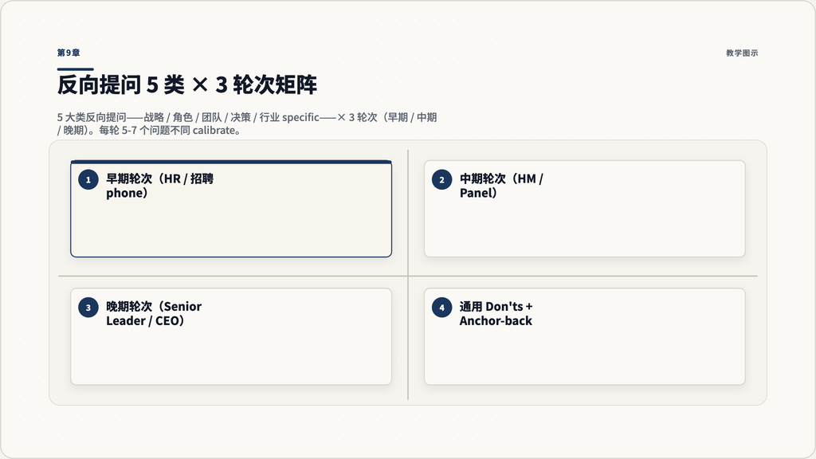

第9章：反向提问 5 类 × 3 轮次矩阵

**图 9.1：5 大类反向提问——战略 / 角色 / 团队 / 决策 / 行业——× 3 轮次（早期 / 中期 / 晚期）。早期问基础和 expectation；中期问 substantive；晚期问 strategic narrative。每轮 5-7 个问题不一样的 calibrate。**

## 第10章 加拿大 EV BD 薪酬带与谈判脚本

> **数据时效**：本章数字基于 2026-Q1 / Q2 公开数据源（Glassdoor.ca、Indeed.ca、Levels.fyi、Payscale、RepVue），accessed 2026-05-23。**每次面试前必须重新核查**——薪酬带季度变化，特别是 Q2 财报季 + 招聘旺季影响明显。

### 10.1 加拿大 EV BD 薪资带不是一个数字，是一组分布

很多候选人误以为 BD 薪资是 single number——实际是 **多维 distribution**：

下面这张表给你 **2026-Q2 基础参考**——不是”你应该要多少”，是”对方 likely 的 band 在哪”。

### 10.2 2026 加拿大 EV BD 薪酬带（参考表）

> 所有数字单位 CAD，年化。**Total Comp = Base + Variable + Equity 全年化值**。数字范围反映 25th 到 75th percentile，不含极端尾部。

**A. Business Development Manager（普通 BDM / 中级）**

| 雇主类型 | Base | Variable（按 OTE） | Total Comp（OTE 满） | 来源 |
| --- | --- | --- | --- | --- |
| 加拿大 BDM 全国 baseline | $65k - $95k | 25-40% of base | $90k - $130k | Indeed.ca avg $90,330 [B6]；Glassdoor.ca 2026-01 [B3] |
| Toronto BDM premium | $80k - $115k | 30-40% | $110k - $160k | Glassdoor Toronto [B4]；Levels.fyi 出 $151k avg [B7] |
| Montreal BDM | $70k - $100k | 25-35% | $95k - $135k | Glassdoor Montreal [B5] |
| Tech / SaaS BDM Toronto（参照） | $95k - $135k | 35-45% | $130k - $200k | Levels.fyi tech-skewed [B7] |

**B. Senior BDM / Director-level（5-10+ 年）**

| 雇主类型 | Base | Variable | Total Comp | 备注 |
| --- | --- | --- | --- | --- |
| OEM Canada Sr BDM | $100k - $140k | 30-40% | $135k - $200k | OEM 大公司 base 偏高 variable 偏低 |
| 电池厂 Sr BDM | $110k - $150k | 25-35% | $140k - $200k | NextStar 类公司 [B11 reports range $33k-$146k 跨所有 roles] |
| 充电运营 Sr BDM | $100k - $135k | 35-45% | $135k - $195k | Flo BDM avg ~$117k [B2]，OTE 上浮 30% |
| Tier 1 Sr Commercial | $105k - $145k | 25-35% | $130k - $195k | Magna 类公司 [B10]，工程偏多 BD 偏少 |
| Dealer / 中国 EV head BD | $120k - $180k | 30-50% + equity | $160k - $300k | senior strategic hire，equity component 大 |

**C. VP BD / Country Head（10-15+ 年）**

| 雇主类型 | Base | Variable + Equity | Total Comp | 备注 |
| --- | --- | --- | --- | --- |
| OEM Canada VP Sales | $180k - $250k | 40-60% bonus + RSU | $280k - $450k | 大 OEM senior role |
| 电池厂 / 充电 VP BD | $160k - $220k | 30-50% + equity | $240k - $400k | growth-stage 公司股权占比大 |
| 中国 EV 加拿大 country head | $150k - $250k | 40-60% + equity / RSU | $250k - $500k | 中国总部决定，幅度大 |

> **重要 caveat**：以上数字均为公开数据 aggregator 自报，单家公司实际 band 可能 deviate 20-30%。任何 specific 公司面试前用 Glassdoor + Levels.fyi + Repvue 三源 cross-check [未独立核实 specific 公司]。

### 10.3 OTE 结构的拆解

加拿大 EV BD 的 variable comp 结构通常是下面三种之一：

**类型 1：50/50 split（aggressive）** - 50% base + 50% variable（OTE 满状态） - 常见于 SaaS-style 充电运营 / 中国 EV 进加 BD - 风险：base 偏低，quota 不达成 cash flow 紧

**类型 2：60/40 split（常见）** - 60% base + 40% variable - OEM / Tier 1 / 电池厂主流 - 平衡 stability 和 incentive

**类型 3：70/30 split（保守）** - 70% base + 30% variable - 大 OEM senior role / corporate strategy BD - 适合长周期 deal、commission 不能直接 link

参考：Apollo 出 OTE Guide 2026 [B9] 给的 industry benchmarks 是 AE 50/50 或 60/40；SDR 70/30 或 80/20。

### 10.4 谈判前要 lock 的 5 个数字

进入 offer phase 前，你必须 personally know 下面 5 个数字（写在你的笔记本上）：

1. **你的 walk-away number**：低于这个数你不接（包含 base + variable 实际可期值）
2. **你的 target number**：你期待的 mid-point
3. **你的 reach number**：你 aspire 的 high
4. **市场 75th percentile**：你 target 高于这个就要 strong justification
5. **你当前的 alternative**：现在的 comp + 其他 offer 状态

**对应 sample 数字（举例，不是建议）**：

- Walk-away: $130k total comp
- Target: $155k total comp
- Reach: $180k total comp
- 市场 75th: $160k（per Glassdoor / Levels.fyi）
- Alternative: 现在 comp $145k + 另一个 offer $150k

这 5 个数字 lock 后你不会在 emotion 下接受 bad offer 或 over-ask。

### 10.5 谈判脚本：场景 1—— “你期待多少薪资？”（早期 HR 轮）

**Bad answer**: > “I’m looking for $150k base.”

为什么差：(a) 给数字太早 anchor 自己 (b) 没给 range 让对方判断 fit (c) 没问对方 band

**Better answer**: > “I’d love to understand your band first—— compensation for similar roles is one input but I’d also weight (1) the impact of the role (2) growth opportunities (3) total comp structure. Could you share what your range is for this role so we can have a more productive conversation?”

**如果对方坚持要数字（HR 常用 ‘I need a number for my system’）**：

> “Understood. Based on my research of Canadian EV BD comp at similar level [Glassdoor / Levels.fyi data point]，I’m in a range of $X to $Y total comp. I’m flexible on structure. What’s your band?”

X 和 Y 选你的 walk-away 到 target+10% 之间（不要露 reach）。

### 10.6 谈判脚本：场景 2——offer 比你 target 低

**情境**：offer 是 $135k base + 30% variable = $175k OTE。你的 target 是 $155k base + 40% variable = $215k OTE。Gap 是 $40k OTE.

**Bad answer**: > “That’s too low. I need at least $200k.”

为什么差：(a) 没 specific reason (b) 没 anchor 第三方 data (c) 没 negotiate structure 只 negotiate number

**Better answer**: > “Thank you for the offer—— I’m excited about the role. Let me share where I am. > > Based on my research [Glassdoor 75th percentile Toronto BDM senior = $XYZ] and given my background, my target total comp is $215k OTE. That’s $40k gap from your offer. > > Three ways we could close this: > 1. Base lift——increase from $135k to $150k > 2. Variable lift——increase OTE multiplier to 40% > 3. Sign-on bonus——$20k one-time > > Of these, I most prefer [1]—— because [reason，比如 cash stability 在 ramp-up phase]。But I’m open to discussing structure that works for your budget.”

**Key tactic**：给三个 option，让对方选，而不是 anchor 一个数字。

### 10.7 谈判脚本：场景 3——多 offer 平衡

**情境**：A 公司 $180k，B 公司 $165k。你更想去 B（reason: role 更 strategic）但 comp gap 是 $15k。

**Bad answer to A**: > “I have another offer for less but I’m using it for leverage.”

为什么差：暴露 game-playing，A 公司 lose respect

**Better answer to B**: > “I want to be transparent—— I have another offer at $180k from [A 公司 or ‘a competing company in same segment’]. I’m leaning toward you because [specific reason about role / team / vision]. But the $15k gap is meaningful given relocation / opportunity cost. > > Could you close the gap? If you can get to $175k I’m ready to accept today.”

**Tactical notes**: - “Ready to accept today” 是 close 力量——让 B 知道你不在 stalling - 不要 inflate alternative offer - 给 B specific reason 选他—— flatter without grovel

### 10.8 谈判脚本：场景 4——你已经接受 offer 但后面更好 offer 出现

**情境**：你 accept A 公司，2 周后 B 公司发 better offer。这是 ethically 复杂场景。

**核心原则**： - 不要 ghost A 公司 - 不要 lie about reason - 给 A 公司 chance to match——这是 ethically 可接受的

**Script**: > “I want to update you——I’ve received another opportunity that I wasn’t expecting. The role is at [B 公司 type, not specific]. I would prefer to stay with you—— but the gap is significant. Specifically [comp / role / growth]. > > Before I make any decision, I want to give you the chance to discuss whether we can adjust. If not, I’ll need to consider carefully——and I want to give you 1 week to think through.”

**Ethical caveats**：

- 不要重复用这个 tactic——你 reputation 会受损
- 一旦 verbally accept offer，你已经在 ethical commitment 里——这种 case 用一次就尽量不再用
- 如果 A 公司 not flex，你要 honest reason 给 leave——不能不告诉就 ghost

### 10.9 谈判脚本：场景 5——sign-on bonus / equity

**Sign-on bonus** 在加拿大 EV BD 不像 US tech 那么 common，但 senior role 和 hiring momentum 紧的时候有 leverage。

**Script**: > “I appreciate the offer. To make this work, I’d like to discuss a sign-on bonus of $20-30k. Reason: I have an unvested bonus / unrealized commission at my current role that I’d be leaving on the table. This bridges that gap.”

**Equity / RSU** 在以下场景常见：

- 上市公司大 OEM（GM / Ford / Stellantis）——RSU vesting 3-4 years
- Growth-stage 充电运营（Flo / ChargePoint）—— options vesting 4 years
- 中国 EV 进加（BYD / Zeekr）——通常是中国总部 stock award

**Negotiate equity 的 ask**: > “Could we discuss the equity component? I’d like to understand (1) grant size in $ value 当前 valuation (2) vesting schedule (3) what happens if I leave at 12/24/36 months.”

### 10.10 谈判 timing 的 5 个 rules

1. **Never negotiate before offer**——直到对方说”we want to offer”你才进入 negotiation。早 negotiate 给对方 reason to walk
2. **Always negotiate in writing**——offer + 你的 counter 都 follow up in email
3. **Negotiate 24-48 hours after offer**——不要立刻接，也不要拖 1 周
4. **One round of counter**——大多数 case 你只有一次 negotiate，不要 nickel-and-dime 多轮
5. **Be ready to walk**——如果对方 cannot close gap，你 walk away——这是 ultimate 谈判力量

### 10.11 章末检查点

下一场面试前完成：

1. 你的 5 个数字写下来（walk-away / target / reach / market 75th / alternative）
2. 你的 OTE preference（50/50 / 60/40 / 70/30）
3. 你的 sign-on / equity ask 范围
4. 5 个谈判 script 至少 review 一次（不背诵，看 logic）
5. 公司当前 band 的 Glassdoor / Levels.fyi cross-check

5 件事完成—— 你是有备而来的 negotiator，不是被 react 的 candidate.

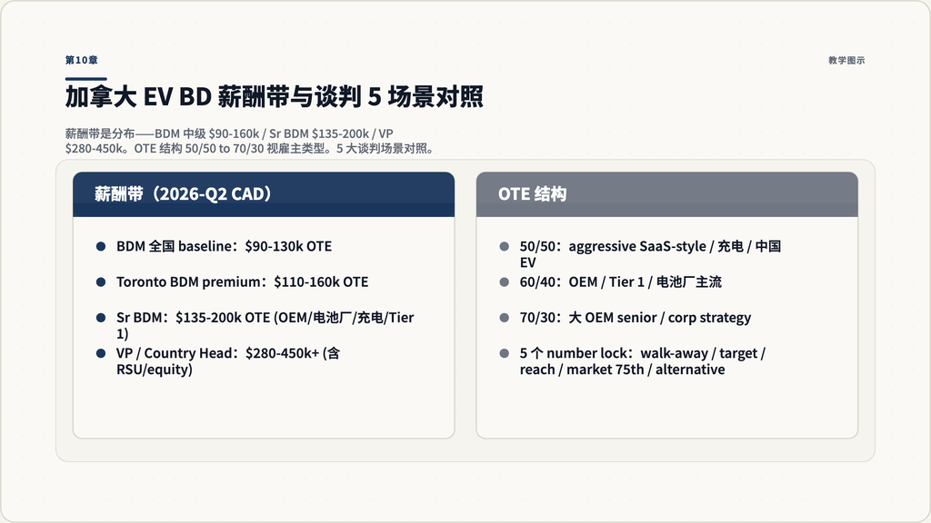

第10章：加拿大 EV BD 薪酬带与谈判脚本对照

**图 10.1：薪酬带是分布——BDM 中级 $90-160k / Sr BDM $135-200k / VP $280-450k。OTE 结构 50/50 to 70/30 视雇主类型。谈判 5 大场景——期待数字 / offer 偏低 / 多 offer / 已接受后更好 offer / sign-on equity。**

## 第11章 面试前 48 小时节奏化清单

### 11.1 为什么 48 小时是黄金窗口

太早准备（5+ days out）：信息会更新（特别是 EV 行业数据），且你的 short-term memory 装不下太多东西。

太晚准备（< 24 hours out）：没时间纠错、没时间睡觉、没时间核对数字。

**48 小时是最优 window**：

- T-48h 到 T-24h：信息核查 + research depth
- T-24h 到 T-12h：故事和 script 演练
- T-12h 到 T-3h：休息 + 复盘要点
- T-3h 到 T-30min：最后 sanity check
- T-30min 到 T-0：mental reset，不要 cram

这一章给你 timeline 化的清单——每个时间段 specific 做什么，不要做什么。

### 11.2 T-48h（面试前 48 小时）：信息层 lock-down

**目标**：确认所有事实和数字是最新的。

**Checklist（90-120 min 完成）**：

1. **公司当前状态 sanity check**（30 min）
   - LinkedIn 公司页 confirm 员工数和 location
   - 公司新闻页 last 6 months 扫一遍
   - Google News 搜公司名 + “2026”
2. **行业宏观数字核查**（30 min）
   - 加拿大 2026 联邦 EVAP 数字 [C3, C4]
   - 联邦废 mandate 状态 [C1, C2]——确认没有反复
   - Q1/Q2 EV 渗透率 (魁北克、BC、安大略、Canada 全国) [Electric Autonomy 月报]
3. **领导层 update**（20 min）
   - LinkedIn 搜你要见的面试官——he/she 当前 title、近 6 个月 posts
   - HRBP 给的 panel 名单逐个 verify
4. **薪酬带最后 cross-check**（20 min）
   - Glassdoor / Levels.fyi / Indeed 三源 cross-check 你的 target band
   - 写下”我的 5 个数字”（Ch10 §10.4）

**不要做**：

- 不要重新读 EV 技术教程整本——你应该已经读过
- 不要重新做 deep research——时间不够
- 不要看新的 framework——你的 toolkit 已经定

### 11.3 T-24h（面试前 24 小时）：故事和 script 演练

**目标**：你的 STAR、桥梁陈述、reverse Q 都可以脱口而出。

**Checklist（3-4 hours，分两段）**：

**Block 1：上午或下午第一段 (90 min)**：

**Block 2：晚上 (60-90 min)**：

4. **公司 specific 研究 deep-dive 复盘**（45 min）
   - 你为这家公司准备的 3 个 nod moments（specific 数据点）
   - 你的 strategic narrative 判断（这家公司 next 3 years 的 winning case）
5. **Reverse Q 准备**（30 min）
   - 写出 5-7 个反向提问（Ch9 矩阵）
   - 每个准备 30 秒 anchor-back

**不要做**：

- 不要把所有 27 个 STAR 都演练——精力分散
- 不要看新的 EV news——会 distract
- 不要 schedule meeting / call——你的 cognitive bandwidth 已经被分配

### 11.4 T-12h（面试前 12 小时）：休息 + 软复盘

**目标**：睡好觉。Cognitive 表现跟睡眠 directly 相关。

**Checklist（最多 60 min 的”工作”）**：

1. **复盘要点（不背诵）**（20 min）
   - 翻一遍你的 5 个 STAR 要点
   - 翻一遍桥梁陈述
   - 翻一遍 reverse Q
2. **行程 + 后勤确认**（10 min）
   - Video 面试：测试 camera / mic / 灯光
   - In-person 面试：行程 + 衣服 + 备份联系信息
   - 时区 / 时间 / link / 联系电话再 confirm 一次
3. **明天 schedule lock**（10 min）
   - 早起几点、吃什么、面试前 60 分钟 buffer
   - 面试后 30 分钟 buffer 写 debrief
4. **休息**（剩余时间）
   - 不要 work-related screen
   - 散步 / 阅读非 work / 跟家人 chat
   - 11 点前睡觉

**不要做**：

- 不要熬夜 cram
- 不要喝酒 / 喝过多咖啡因
- 不要看负面 news（保持 mood）

### 11.5 T-3h（面试前 3 小时）：最后 sanity check

**目标**：确认你 mentally + practically ready。

**Checklist（45-60 min 完成）**：

1. **吃东西**（30 min）
   - 不空腹（hypoglycemia 影响 cognition）
   - 不过饱（消化分流 blood flow）
   - 推荐：protein + complex carb（鸡蛋 + 燕麦 / 三明治）+ 适量咖啡（如果你 normally 喝）
2. **最后 number sanity check**（10 min）
   - 你的 5 个数字（薪酬）
   - 你为这家公司准备的 3 个 nod data points
   - 你 likely 见的人姓名
3. **Mental rehearsal**（10 min）
   - 想象面试场景：你坐下、开场、第一个问题、对方反应
   - 不背诵——visualize
4. **物理 setup**（10 min）
   - Video：背景干净、灯光在你脸前、camera angle 平视（不要俯视）
   - In-person：proper 衣着、文件包、Notes paper、Pen
5. **手机 do-not-disturb**

**不要做**：

- 不要打 random call（会扰乱 focus）
- 不要 last-minute revise STAR（你已经定型）
- 不要 over-caffeinate

### 11.6 T-30min（面试前 30 分钟）：reset

**目标**：进入 calm + focused 状态。

**Checklist**：

1. **5-10 min walk** 或者 **5 min breathing exercise**
   - 4-7-8 breath：吸 4 秒、屏 7 秒、呼 8 秒，做 4 次
   - 物理活动让 cortisol 下降
2. **Re-read 你的 opener**（5 min）
   - 桥梁陈述的开场 30 秒
   - 你 likely 第一个 question 的 lead-in
3. **Water + bathroom**（5 min）
   - 喝水（avoid dehydration affect voice）
   - 提前 use bathroom（避免 mid-interview 紧张）
4. **5 min before**：
   - Camera / link ready
   - 微笑（physical posture 影响 mental state）
   - 提前 2 min join——不早不晚

**不要做**：

- 不要在最后 30 min cram 任何新东西
- 不要 anxiety-doomscroll
- 不要 last-minute call to friends “wish me luck”——这反而提升 anxiety

### 11.7 T-0：进入面试

**第一 60 秒至关重要**：

1. **微笑 + 眼神 contact**（不是过度热情，是 grounded）
2. **opener**：等对方先开口。如果对方说”how are you”——简短答 + redirect：“I’m doing well, thanks for making time——I’ve been looking forward to this conversation.”
3. **第一个问题**：listen 完整再答——不要急着 jump in

**Mid-interview tactics**：

- 如果你 don’t know 某个事实——“I don’t have that data point top of mind. I’d want to verify before giving you a specific number. But my understanding broadly is [X].”—— 这是合格答案
- 如果你 forget your line in middle of STAR——pause、深呼吸、说”Let me regroup. The key point I want to leave you with is [X].”—— 这是 mature recovery
- 如果面试官 challenge 你——不要 defensive。“That’s fair pushback. Let me think about that for a second.”——pause——给 considered answer

**End-of-interview tactics**：

- “你有什么问题？”—— 用 Ch9 reverse Q（pick 3 from your list of 5-7）
- 最后 close：感谢 + restate your interest + ask about next step
  - “Thanks for the conversation——I’m even more interested in the role after this. What’s the next step in your process?”

### 11.8 T+30min：debrief

**目标**：lock 学习 + 为下轮准备。

**Checklist（30 min 内完成，趁记忆鲜活）**：

1. **写下面试 transcription**（15 min）
   - 你 likely 见的人姓名 + 他们问的关键问题
   - 你的答案的具体内容（不只是 ‘I answered well’，是 specific）
   - 你 stuck / fumbled 的瞬间——具体什么 question / 你说了什么
2. **写下面试官 hints**（5 min）
   - 他们 mention 的 internal context / strategic priority
   - 你应该 follow up 的 detail
3. **下一轮 prep notes**（5 min）
   - Based on 这一轮，下一轮 likely 问什么
   - 你 stuck 的地方下次怎么 handle
4. **Thank-you note 草稿**（5 min）
   - 24 小时内 send
   - Specific reference to conversation point（不要 generic）
   - Ch12 给你 template

### 11.9 节奏化的 5 个 anti-patterns

| Anti-pattern | 为什么差 | 替代 |
| --- | --- | --- |
| T-1 week 开始重新 research | 距离面试远，信息会刷新，cognitive load 累积 | T-48h 才 lock down 信息 |
| T-24h 还在改 STAR 故事 | 故事变动让你 inconsistent | T-48h 之前定型 |
| T-12h 还在 work-related screen | 睡眠质量降低 | T-12h 之后纯休息 |
| T-3h 跟 friend 通话 “wish me luck” | 提升 anxiety 不是 calm | T-3h 之后 only solo activities |
| T-30min cram 新东西 | cognitive interference | T-30min 之后 only physical/breath reset |

### 11.10 章末检查点

为下一场面试 dry-run 一次这个 timeline。问自己：

- T-48h 我会做什么 specific？我 have 时间吗？
- T-24h 我的 STAR 录音 ready 吗？
- T-12h 我能 11 点前睡觉吗？
- T-3h 我吃什么？谁需要 notify？
- T-30min 我的 breath / walk 安排 ready 吗？

5 问 yes ≥ 4 才算过关。

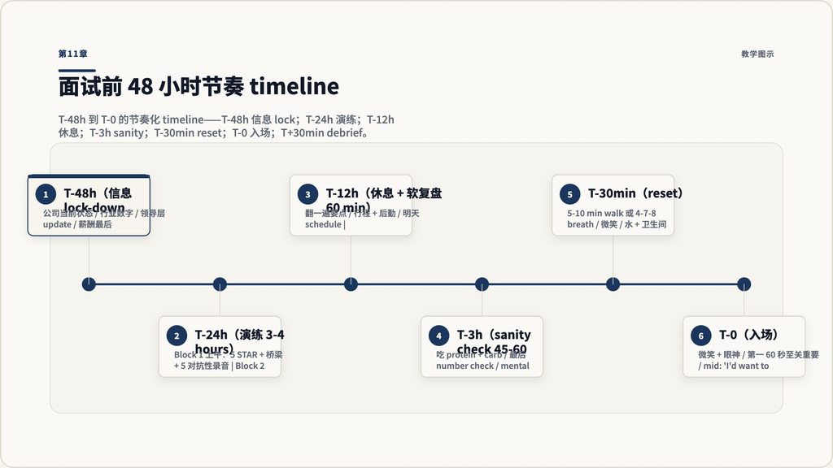

第11章：面试前 48 小时节奏 timeline

**图 11.1：T-48h 到 T-0 的节奏化 timeline——T-48h 信息 lock；T-24h 演练；T-12h 休息；T-3h sanity；T-30min reset；T-0 入场；T+30min debrief。每个时段做什么不做什么明确。**

## 第12章 面试后跟进与决策期

### 12.1 面试结束不等于面试结束——决策期是 second interview

很多候选人把 thank-you note 当 formality——这是错的。Thank-you note 是面试的”第二回合”——你可以：

- Reinforce 你 strongest moment
- Clarify 任何 fumble
- Add 一条你没说完的 substantive point
- 让决策者 remember 你

**面试后的 flow** 通常是：

1. **0-24h**：thank-you note（必做）
2. **24-72h**：HR 通知 next step or rejection
3. **3-14 days**：next round 或者决策期
4. **14-21 days**：offer 或 reject

不同雇主时间表不同：充电运营快（1-2 周决策），OEM 慢（4-8 周）。

这一章给你 **决策期的 flow 处理**——从 thank-you note 到 offer 到 reject 全 cycle。

### 12.2 Thank-you note 的 4 段结构

**Format**：email，subject “Thank you - [your name] - [role]”

**段 1（1-2 句）：开场感谢 + specific timing** > “Thank you for the conversation this afternoon. I really enjoyed our discussion on [specific topic from interview].”

**段 2（2-3 句）：reinforce 一条 specific 你 strongest moment** > “Your point about [specific insight from interview] resonated with me——I’m thinking about how [your relevant experience] could specifically translate to [role’s challenge].”

**段 3（2-3 句）：add 一条你没说完的 substantive thing** > “One thing I didn’t get to mention——[a specific data point / observation / question you have for the company that adds value].”

**段 4（1-2 句）：close + restate interest + next step** > “I’m even more excited about the role after our conversation. Looking forward to hearing about next steps.”

**Sample full email**：

> Subject: Thank you - Adam Lin - Senior BD Manager

> Hi [Name],

> Thank you for the conversation this afternoon. I really enjoyed our discussion on the strategic implications of the 2026-02 federal mandate repeal for [Company]’s 12-month planning.

> Your point about how the new EVAP $50k cap is reshaping product portfolio decisions—— particularly for premium models above that threshold—— resonated. I’m thinking about how my experience navigating [specific past situation with policy-driven market shift] could specifically translate to your dealer-network conversations next year.

> One thing I didn’t get to mention—— I noticed [Company] has been quiet publicly about [specific topic—— could be Chinese OEM strategy, charging partnership, etc.]. If that becomes a strategic priority next year, I’d love to share some specific observations from [your relevant lens].

> I’m even more excited about the role after our conversation. Looking forward to hearing about next steps.

> Best, [Adam Lin]

### 12.3 Thank-you note 的 5 个 don’ts

| Don’t | 为什么 |
| --- | --- |
| Send template-y note | 暴露 lack of effort |
| Wait > 24 hours | 错过 mind-fresh window |
| Email > 250 words | 决策者没时间读 |
| 重复面试里已经说过的内容 | 浪费机会 |
| Send to HR but not hiring manager | 错过最重要的人 |

**Send 给谁**：

- 单轮 1on1：当面那个人
- Panel：每个 panelist 都 send（differentiated content，不要 copy-paste）——这是 differentiator
- 不知道 email：通过 LinkedIn message 或者 HR 转送

### 12.4 决策期沟通 timing

**Day 1-3 after 面试**：thank-you note + 静默

**Day 4-7**：如果你没收到任何 update，可以 send 一条 polite check-in 给 HR： > “Hi [HR]——hope your week is going well. Following up to ask about next steps in the process. Happy to provide any additional info if helpful.”

**Day 8-14**：如果还是无消息——一次 follow-up，然后 silence 直到他们 reach out 或你 walk away

**Day 14+**：基本可以认为是 silent rejection，但你可以一次 final note：“I want to follow up one last time——if the role has moved in another direction, I appreciate you letting me know. I remain interested in [Company] for future opportunities.”

**绝对不要**：

- Send daily / weekly nag
- 假装 “I have another offer” if you don’t
- Take rejection personally and lash out

### 12.5 决策期的”second source” tactics

如果你想 maximally 推进 offer 概率——可以做 second-source moves（small subset of candidates do this，差异化效果明显）：

**Action 1：reach out to current employees on LinkedIn**

- Not the people who interviewed you
- “I just interviewed for [role] at [company]——I’d love a 15-min coffee to learn more about the team culture”
- 80% of senior people will take a 15-min call—— and they often share input with hiring manager

**Action 2：send a brief “value-add” follow-up**

- 1 week after interview
- Send a relevant article / insight 你 think they’d care about
- “Saw this [article on X topic]——thought of our conversation about [Y]. Sharing in case useful.”
- 这显示 you’re a learner not just a candidate

**Action 3：preempt reference questions**

- Send 3 reference names to HR before they ask
- Brief your references about role + company so they can answer pointedly
- “Here are 3 references who would speak to specific dimensions: [name 1] on [dimension 1], [name 2] on [dimension 2], [name 3] on [dimension 3]”

这些动作不是 manipulative ——它们是 mature signal of high-engagement candidate.

### 12.6 多 offer 平衡——决策 framework

如果你 fortunate 拿到 2+ offers，决策 framework：

**Step 1：lock 5 维度评估**

| 维度 | A 公司 | B 公司 | 你的权重 |
| --- | --- | --- | --- |
| 1. Total comp（5 年 NPV） | $X | $Y | high |
| 2. Role strategic value（next role 跳板） | medium | high | high |
| 3. Manager 质量 / learning | high | medium | high |
| 4. Company trajectory（5 年） | uncertain | strong | medium |
| 5. Culture / 日常 working experience | high | medium | medium |

**Step 2：5 分制各维度打分 + 权重 multiply**

总分高的 win。**不要按 single dimension** decision——comp 偏高但 role 没 strategic value 是陷阱。

**Step 3：reality check**

- Walk away exercise：如果只能选 worst case 那家（小概率 underperform），你 willing 在这家工作 3 年吗？
- 如果不 willing——降权 重做

**Step 4：1 周 cool-off**

- Decision 不在 high emotion 做
- 跟 trusted advisor 谈（你的 mentor / partner / 一个有这家公司 inside view 的 friend）
- 24-48 小时不动 phone 让 reflection happen

**Step 5：通知**

- Accept offer 通知用 phone or video call 不是 email——professional courtesy
- Decline offer 用 email 但给 specific reason + leave door open： > “I appreciate the offer and I’ve thought hard about it. I’ve decided to accept another opportunity that aligns more closely with [specific reason]. I have huge respect for [Company]——please keep me in mind for future roles if our paths could cross.”

### 12.7 Rejection 处理——这是 learning input

**收到 rejection**：

**Step 1：24 小时 cool-off**

- 不要立刻 react
- 不要 send angry email
- 不要 unfollow on LinkedIn out of spite

**Step 2：write 一封 mature thank-you**

> “Thanks for letting me know. I appreciate the time you and your team spent with me——I learned a lot from the conversations. If you’re open, I’d value any feedback on areas I could strengthen for future opportunities. And please keep me in mind if priorities shift.”

**Step 3：ask for specific feedback**

很多 HR 不会主动 give。Ask explicitly： > “I’m specifically curious whether the gap was [skill/experience/fit/timing]. Any candid input would help me grow.”

50% will give nothing. 30% will give vague. 20% will give specific—— those 20% are gold.

**Step 4：log 在你的”面试 lessons learned”文档**

- 哪轮 stuck
- 我 said what / I should have said what
- 这家公司 reject 反映我哪条 weakness
- Next 面试要 specifically 改什么

**Step 5：keep network warm**

- 这家公司 6-12 个月后 hiring 可能变
- Hiring manager 可能跳到另一家
- 偶尔 LinkedIn engagement / share 一条 article 不会 burn anything

### 12.8 几个 edge cases

**Edge case 1：拖 too long without update**

- 2 周无消息 = 80% silent reject 概率
- 1 个月无消息 = 95% silent reject
- 这种情况你 send final note + move on，不要纠结

**Edge case 2：offer 给了但 conditional on something（reference / background check）**

- Verbal accept 但 written contract before resign current role
- Reference / background check 走完再 give notice

**Edge case 3：counter-offer from current employer**

- Stat：85% of counter-offer accepters leave within 12 months
- Counter-offer rarely solves root reason you wanted to leave
- 谨慎对待——通常 decline counter

**Edge case 4：offer pulled / rescinded**

- 不要 panic、不要 lash out
- Ask specifically why——是否可以 reverse
- 如果不能 reverse——pivot 到 next opportunity，但 also document（labor lawyer 在 employment contract violated 情况下 useful）

### 12.9 整个决策 cycle 的 flow 总结

```
面试完成
   ↓
T+0 to T+24h: thank-you note（specific, each panelist different）
   ↓
T+1 to T+7d: 静默 + optional second-source moves
   ↓
T+7 to T+14d: polite check-in if no update
   ↓
   ├── offer 来了 → 24-48h negotiate (Ch10) → 1 周 cool-off → accept / decline
   ├── next round 来了 → 准备 next round
   └── rejection → mature thank-you + ask feedback + log lessons
```

### 12.10 章末检查点

挑你最近一场面试（or 你 next 即将面试的）——按这个 chapter flow 走完一遍：

1. 你的 thank-you note 是否 specific + < 250 words + 24h 内 send？
2. 你的 follow-up cadence 是否 calibrate？
3. 如果多 offer，5 维度评估你 ready 吗？
4. 如果 rejection，你能 ask specific feedback 吗？

四问 yes ≥ 3 才算过关。

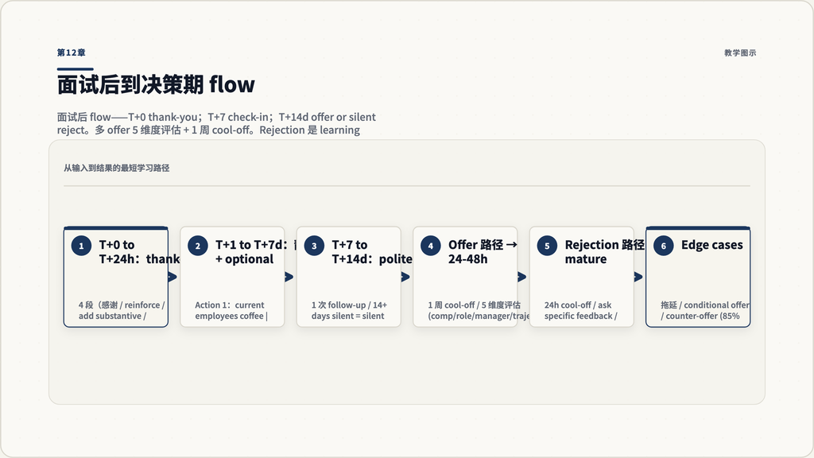

第12章：面试后到决策期的 flow

**图 12.1：面试后 flow——T+0 到 T+24h 是 thank-you；T+7 polite check-in；T+14d offer or silent reject。多 offer 5 维度评估 + 1 周 cool-off。Rejection 是 learning input 不是 ending。每一步都 differentiate mature candidate from anxious candidate。**

## 第13章 6 个完整模拟面试场景

### 13.1 为什么 mock scenarios 才能把全书工具拼起来

前 12 章给了你 toolkit。但 toolkit 不是 muscle memory——muscle memory 来自把工具拼到一场具体面试场景里走完一遍。

这一章给你 **6 个完整模拟面试**，覆盖 5 类雇主：

1. BYD Canada（中国 EV 进加，2 轮快节奏）
2. NextStar Energy（电池厂，4 轮 + 工厂参观）
3. Flo（充电运营，3 轮 SaaS 节奏）
4. Magna E-Mobility（Tier 1，4 轮 + 工厂参观）
5. 中国电池厂北美 head of BD（虚拟雇主——中韩日电池厂在加拿大设立子公司，senior strategic hire）
6. AutoCanada（dealer 集团，2-3 轮 CEO 直决）

每个场景给你：

- **Setup**：你的转型背景 + role + 面试官信息
- **完整面试对话**：开场 → 主要问题 → 你的答案 → 反向提问 → close
- **对话后复盘**：哪条工具用上了、哪条 missing、下一轮应该 prep 什么

> **重要 disclaimer**：以下场景中的对话、人物、specific 数字是 **教学示意**，不是真实公司 / 真实候选人。你应该把自己的真实背景填入 placeholder——不要直接抄。

### 13.2 模拟场景 1：BYD Canada Senior BD Manager（轮次 2 of 2）

**Setup**： - **你的转型背景**：[10+ 年] 跨境业务 / 出海 / 中国-海外桥梁。中文母语，英语 fluent。 - **Role**：Senior BD Manager, Canadian Market Development - **轮次**：第 2 轮（CEO 一轮），第 1 轮已过（HR + Country Head 联合电话） - **面试官**：[BYD Canada 暂代 Country Head——华裔，过去在丰田北美做过 5 年 dealer 关系] - **背景**：BYD 2026 Q1 已雇 Markham consultancy 寻找 20 个加拿大经销点，GTA/Vancouver/Montreal/Calgary 优先。100% 关税环境下需要 navigate 关税路径 + dealer 渠道构建 + 品牌信任建立。

**面试对话（45-60 min）：**

**Opener (5 min)**

面试官（中文）：“欢迎。我们今天有 45 分钟。我想直接进入实质讨论。先简单讲讲——你为什么对 BYD 加拿大感兴趣？”

你的开场（30 秒，**填你的具体故事**）： > “[你的真实承认差异 + 桥梁能力 + 已有动作——按 Ch5 模板 C ”出海/跨境业务”]。 > > 简单讲——我做了 [10+ 年] 中国-海外桥梁。BYD 加拿大是这 10 年我看到的最 specific 镜像版本——一个中国品牌进入一个 trust-gap 显著的成熟市场，从零起步。我对这件事的 functional understanding 是稀缺的。”

**Main Block 1: Strategic Question (10 min)**

面试官：“好。我直接问——100% 关税环境下，你怎么 frame BYD 在加拿大 next 18 个月的 win condition？”

你的答案（90-120 秒，**填你的具体判断**）：

承认复杂性： > “100% 关税意味着 mass-market BEV 渠道路径 short-term 不可行。所以 win condition 不是’卖几万台车’——是建立 3 件事让 future 有规模化空间。”

3 条 specific： > “第一，**渠道**——20 个 dealer point 走出去。这是 BYD 公开做的事，我假设是 Markham consultancy 在帮你们 evaluate dealer 集团。这一步 must work——没有渠道一切都是空谈。 > > 第二，**品牌教育 + 信任建立**——加拿大消费者对中国 EV 不熟悉。这不是 marketing budget 砸的事，是 12-18 个月 reputational drip 的事。 > > 第三，**关税路径优化**——short-term 你们可能聚焦 high-end BEV（避开 EVAP $50k 上限的目标客户群——价格不敏感）+ PHEV + 商用车三条路径。BEV mass-market 等政策环境改变（USMCA 2027 审查或 carney 政府调整）。”

判断 wrap-up： > “Win condition 是 18 个月 build out infrastructure，不是 sell volume。如果你们 leadership 还在按 sell volume 衡量，可能 misalign。”

面试官（点头）：“这判断和我们 internal alignment 一致。让我 deeper——dealer 渠道你怎么 approach？BYD 在中国是直营加经销混合。北美 specific 你的 view？”

你的答案（60-90 秒）：

> “我的 view 是早期 hybrid，长期 dealer：
> - **早期 12 个月**——5 个 flagship 直营店（GTA + Vancouver + Montreal），用来做 品牌教育、客户 hands-on、media exposure。直营 control brand experience 重要。
> - **同时 parallel**——跟 AutoCanada / Pfaff / Quebec 大集团谈 10-15 个 dealer point。Dealer 给你的是 reach + 服务网络。
> - **18-24 个月**——dealer 增加到 20-30 个，直营保持 5-8 个 flagship。

> 关键 tactical：早期 dealer 的 economics 你们要给他们足够 incentive 才能 sign。BYD 这种 unknown brand 加上 100% 关税 lower margin，dealer 会 hesitant。可能需要 floor plan financing 或 guaranteed minimum 才能 attract A-tier dealer。”

**Main Block 2: 对抗性问题 (10 min)**

面试官：“Push back——你过去做的是 [广告 / SaaS / digital]，不是车。Dealer 集团是 50-70 岁的人，文化保守。你 walk into 谈判 room 怎么 establish credibility？”

你的答案（按 Ch7 三步法 reframe）：

承认（10 秒）： > “您说的是 reality——我不否认。我没在 dealer 桌上 carry 过 quota，没跟 dealer GM 周末打过 golf。”

Reframe（30 秒）： > “但 dealer 谈判 credibility 不是年纪带来的——是 substance 带来的。Dealer GM 真正 measure 三件事： > > 1. 你的 product economics 是否对他赚钱 > 2. 你的 brand 是否能带客流 > 3. 你的 follow-through 是否 reliable > > 这三件不依赖 ‘I sold cars before’——依赖 negotiation skill + relationship management + execution discipline。这些我 carry 过。”

Specific 证据（30 秒）： > “Concrete 例子——我过去在 [你的 archetype——某 cross-border deal] 谈过类似 dynamic 的合作。对方是 [类似 conservative 决策人 archetype]。我的 approach 是 [3 个 specific tactic——比如 hands-on prep / data 充分 / 提前 build relationships before 正式 negotiate]。 > > 加拿大 dealer 我也已经开始 mapping——过去 [X 周] 我跟 [N 个] dealer 行业人聊过，包括 [archetype—— ex-AutoCanada / dealer 集团 corporate]。”

风险化解（15 秒）： > “Risk acknowledgment——第一年我会有 ramp-up curve。我建议跟我 partner 一个有 dealer 关系的 senior advisor（可以是 contractor 不是 FTE）做前 6 个月 chaperone。”

面试官：“Fair。下一题——你的 visa / work authorization 状态？关税环境下 BYD 加拿大 maybe 招中国国籍多一些，你是不是 PR / Citizen？”

你的答案（**按你真实情况答**——不要 hide，不要 over-explain）： > “[你的真实 status]。Relocation: [你的真实 view]。”

**Main Block 3: 反向提问 (15 min)**

面试官：“你有什么问题问我？”

你（按 Ch9 选 4 个高质量问题）：

Q1（行业 specific 战略）： > “BYD 总部决策机制 vs 加拿大本地决策 autonomy——你目前的 working assumption 是什么？因为 dealer 谈判和品牌定位经常是 time-sensitive，本地 autonomy 越大反应越快。”

[对话 5-8 min，对方答 + 你 anchor-back]

Q2（角色 expectation）： > “12 个月 from now you would consider this hire a success if I have demonstrated 什么 specific outcomes？2 to 3 things。”

[对话 5-8 min]

Q3（团队 / 决策政治）： > “BYD Canada 现在的 internal stakeholder map——加拿大 country head / 中国总部 EV business head / 北美 region head——这三层 decision dynamics 你怎么 describe？”

[对话 3-5 min]

Q4（压轴 question）： > “Personal question——这家公司从你的角度看，next 12 months 最 likely 的 surprise event 是什么？不是 forecast 是 hedge。”

**Close (5 min)**

你： > “感谢这 60 分钟。我对这个 role 比 walking in 时更 excited。Next step 是什么？”

面试官：[告诉你 next step]

你（最后 close）： > “好的。一件事 leave with you——我做这个 role 不是因为 EV 是 hot industry。我做是因为 BYD 进加拿大是 next 5 年加拿大 EV 行业最 high-impact 的故事之一，我想 in the room when it happens。”

**对话后复盘**：

哪些工具用上了： - Ch5 桥梁陈述（模板 C：出海 / 跨境） - Ch6 雇主研究（BYD 进加 specific data） - Ch7 对抗性问题 reframe（“你没卖过车 + 文化身份”） - Ch9 反向提问（5 类里挑了 4 个，含压轴） - Ch11 节奏（45-60 min 节奏 control）

哪条 missing： - 没有具体 carry quota 数字（这是 reality gap） - 没有 dealer specific name-drop（next round 应该 verify）

下一轮（如果还有）应该 prep： - BYD 具体 product 详情（哪几个车型最 likely 进加） - AutoCanada 等大 dealer 集团 specific dynamics - 中国总部当前 EV business leadership 名单

### 13.3 模拟场景 2：NextStar Energy Senior Business Development Manager（轮次 3 of 5：技术 Deep-Dive）

**Setup**： - **你的转型背景**：[10+ 年] SaaS / 科技 BD - **Role**：Senior BDM, OEM Customer Engagement - **轮次**：第 3 轮（技术 deep-dive），前两轮已过 - **面试官**：commercial lead + chief product manager（双面） - **背景**：NextStar 是 LG Energy + Stellantis 合资，Windsor，2025-11 投产，目标 45 GWh，1,300+ 员工。OEM 客户主要是 Stellantis（合资股东）+ 未来扩展到其他 OEM。这一轮是 technical screening——测你能不能跟 OEM 工程团队对接。

**面试对话（90 min）：**

**Opener + technical warm-up (15 min)**

CPO：“让我先 calibrate 你的技术 level。简单讲——NMC 和 LFP 在采购决策上你怎么 frame trade-off？”

你的答案（90 秒，**按 Ch2 Q21 答案 elaborate**）：

> “NMC vs LFP 是能量密度 / 成本 / 寿命 / 安全的四维 trade-off：
> - **NMC（高镍）**：能量密度高 260-280 Wh/kg，适合长续航高端车（450+ km 单充）；但贵且热失控风险高，需要 sophisticated thermal management。
> - **LFP**：能量密度低 160-180 Wh/kg，续航受限（300-400 km）；但成本低 30-40%、循环寿命长（3000+ cycle）、本质安全（不易热失控）。

> 采购决策 driver： - high-end + 长续航 → NMC - mass-market + cost-sensitive → LFP - storage + 重视循环寿命 → LFP - 2024 后 LFP 在北美 mass-market 快速增长（Tesla Model 3 标准版、Ford Mustang Mach-E 标准版 switched to LFP）

> NextStar 据我了解主要是 NMC（高镍）。这定位你们在 high-end + mid-tier BEV market。”

CPO（点头）：“Correct。Follow-up——OEM 客户在评估你们 cell 的时候会问 qualification process。你 understand 这个？”

你的答案（60 秒）：

> “OEM cell qualification 通常是 18-24 个月 process，分阶段：
> 1. **A-sample**：lab-level prototype，测 basic 性能
> 2. **B-sample**：pilot line，量小测 manufacturability
> 3. **C-sample**：full production line，scale-up validation
> 4. **PPAP**（Production Part Approval Process）：full automotive industry standard
> 5. **SOP**（Start of Production）

> 全程 OEM 工程团队 deeply involved——product engineering、quality、reliability test、abuse test、cycle life。BD 角色在这个 process 里是 maintain customer relationship + 协调 internal team 满足 OEM 要求 + manage 期望和 timeline。”

**Main Block: 客户 scenario (20 min)**

Commercial lead：“好。Specific scenario——一家 non-Stellantis OEM 来找我们 evaluate 是否做 customer。你 first 90 days 怎么 approach？”

你的答案（按 Ch4 案例题 5 步法）：

**Step 1 澄清（30 秒）**：

> “几个澄清问题—— - 这家 OEM 的体量？top tier (Ford / GM) 还是 mid-tier？ - 他们当前电池 supplier 是谁？为什么找我们？ - 他们 SOP 时间表是什么？ - Capacity request 量级？”

Commercial lead：“Mid-tier，比如 Lucid 或 Polestar。当前 supplier 是 LG / SK，evaluating us 因为 capacity / cost。SOP 2028。10 GWh annual。”

**Step 2 假设**：

> “假设是 customer-driven engagement——他们已经 expressed interest。我的 angle 是 win 商务 + maintain 跟 Stellantis 的关系 priority。”

**Step 3 结构化分析（90 秒）**：

> “First 90 days 三段：

> **Day 1-30：technical alignment** - 跟 OEM 工程团队建立 working relationship - product spec matching：他们要的 cell chemistry / format / energy density vs 我们能 supply 的 - 早期 fit / no-fit signal

> **Day 31-60：commercial structure** - capacity allocation：10 GWh annual 占我们 capacity 的 ~22%。需要 internal alignment with LGES + Stellantis stakeholders - pricing model：LGES 内部 transfer pricing 影响 our price floor - contract structure：long-term agreement vs supply agreement vs 灵活

> **Day 61-90：deal advancement** - LOI (Letter of Intent) - PPAP roadmap alignment - Stellantis 内部沟通——这是 sensitive (我们 majority shareholder)”

**Step 4 判断**：

> “Recommendation：accept engagement but 做 transparent 跟 Stellantis 沟通。Don’t 把 non-Stellantis 客户做秘密——会 backfire。”

**Step 5 风险**：

> “Risk 1：Stellantis veto 因为 strategic alignment。Mitigate：早期 escalate，让 Stellantis senior 知道。 Risk 2：capacity over-commit。Mitigate：clear ceiling on non-Stellantis allocation。 Risk 3：Polestar 这种 mid-tier 自己 future uncertain (业绩压力)。Mitigate：milestone-gated contract structure。”

**Main Block 2: 技术 stress test (15 min)**

CPO：“Push——电芯到 pack 你 understand 价值链 split？BMS / thermal management 谁做？”

你的答案（按 Ch2 Q30）：

> “Cell level 是我们 NextStar 的 core。Pack-level (module + housing + cooling) 越来越多 OEM 自做或专门 pack 集成商做。
> - BMS（Battery Management System）：OEM 通常自己做或跟 Tier 1 partner——这是他们 differentiation 关键 (热管理算法 + 寿命预测)
> - Thermal management：mix 模式——cell 内部 thermal design 我们 cooperate，pack-level cooling architecture OEM 主导

> 我们卖 cell-level + 部分 module integration option。Pack integration 我们不直接做（避免跟 OEM 自家 capability 竞争）。

> 这种 split 意味着 BD 对话 80% 集中在 cell spec、qualification process、capacity / pricing。Pack-level 是 OEM 内部话题。”

CPO：“好。我 satisfied 技术层。Commercial lead 你？”

**反向提问 (15 min)**

你的反向提问（按 Ch9）：

Q1（行业 specific）： > “NextStar 2025-11 SOP——head of into 2026 你们 production ramp curve 怎么 plan？45 GWh nameplate 多快到 full utilization？”

[对话 5 min]

Q2（客户 portfolio）： > “Beyond Stellantis，next 24 个月你们 actively 在 pursue 哪种类型 customer——是 NA OEM、欧洲 OEM 进入 NA、还是新势力？BD strategy 是 customer count 还是 concentration？”

[对话 5 min]

Q3（FEOC / USMCA 2027）： > “FEOC 在加拿大目前不是 immediate issue，但 USMCA 2027 审查 likely 改变。你们 strategic team 怎么 plan？”

[对话 5 min]

**Close**：感谢 + restate interest + next step。

**对话后复盘**：

哪些工具用上了： - Ch2 Q21, Q30 知识题 deep version - Ch4 5 步案例题流程（client scenario） - Ch6 雇主研究（NextStar specific） - Ch9 反向提问（行业 specific）

下一轮（轮次 4 + plant tour）应该 prep： - Windsor plant production line 具体 product mix - 加拿大本地 supply chain 上游（材料 / 零部件） - USMCA 2027 文件深读

### 13.4 模拟场景 3：Flo Business Development Manager — Site Host & Fleet（轮次 2 of 3）

**Setup**： - **你的转型背景**：[10+ 年] 出海 / cross-border 业务 - **Role**：BDM, Site Host & Fleet partnerships - **轮次**：第 2 轮（hiring manager + case study） - **面试官**：VP BD（hiring manager），曾在 SaaS 行业 8 年 - **背景**：Flo 是加拿大本土最大独立充电运营商，DC fast 站 1000+，公司 PE-backed。BDM 角色 carry quota，客户类型是 site host（加油站 / 便利店 / shopping mall / municipal）+ fleet（车队 / 政府）。SaaS-style 节奏。

**面试对话（75 min）：**

**Opener (10 min)**

VP BD：“Welcome. Pre-game——you said in round 1 you want to do BD in charging because you see it as a ‘B2B trust-building’ problem. Elaborate？”

你的答案（60 秒，**填你的具体观察**）：

> “充电行业 reality——大多数 EV 行业的 narrative 是关于车，但真正 unlock 加拿大 EV 大规模 adoption 的 bottleneck 是充电基础设施。

> 而充电基础设施的 BD 不是卖 hardware 给 consumer——是 multi-stakeholder B2B 信任：site host (我得在你的地里建桩，给你什么 economics？)、utility (我接你 grid，怎么 split demand charge？)、fleet customer (你的车队我服务，SLA 是什么？)。这跟 [你的 archetype 出海 / cross-border 复杂 B2B] 是相同 dynamic。

> 这是我看好这个角色的原因——不是 because EV is hot, but because the BD problem 是 my muscle。”

VP BD（点头）：“OK. Let’s do a case study.”

**Main Block 1: Case study (30 min)**

VP BD：“Specific scenario——Loblaws 大型 grocery chain。900+ 加拿大门店。他们 RFP 出来想找 charging partner 在 200 个 Tier-1 门店建 charging 站。Flo / Petro-Canada / Electrify / Tesla 都 likely bid。你怎么 win？”

你的答案（4 分钟，按 Ch4 5 步法）：

**Step 1 澄清（30 秒）**：

> “几个澄清—— - Loblaws 的 strategic motivator：是 customer retention (吸引 EV 车主进店) 还是 revenue (charging revenue share) 还是 brand (sustainability narrative)？ - 他们 RFP 的 evaluation criteria 公开吗？ - timeline 怎么样？2026 build out vs longer？ - 是否 require exclusivity？”

VP BD：“Motivator 是 customer retention + brand。Criteria 是 price / uptime / brand fit / speed of execution。Timeline 18 个月. Non-exclusive.”

**Step 2 假设**：

> “Assumptions： - Loblaws 已经跟 Flo / Petro-Canada 都聊过一轮 - 我们竞争优势是本土 + DC fast 网络规模 + uptime track record (假设) - 价格 likely 是 deal-breaker but uptime + execution 是 differentiator”

**Step 3 结构化分析（120 秒）**：

> “我的 win strategy 三部分：

> **Part 1: Bid economics** - 我们的 bid 不是 lowest price——是 fairest price with strongest SLA。Cheapest bid 通常输给 ‘uptime guarantee + branded experience’. - 提议 revenue share model：Loblaws 不付 capex，我们建桩，charging revenue 70/30 split favoring Loblaws first 3 years 之后 50/50. - Loblaws 不掏钱 + 拿大头 revenue + 拿 customer retention upside —— 这是他们 CFO + CMO 都 buy 的结构。

> **Part 2: SLA + uptime promise** - 我们 commit 99% uptime（高于 industry standard 95%） - 24/7 maintenance response - Quarterly business review with Loblaws marketing team

> **Part 3: Brand + execution** - 提议 Co-branded charging plaza experience (Flo + Loblaws logos) - 提议 6 站 pilot in first 90 days 让 Loblaws 看到 execution - Reference customer：我们 existing partner (Couche-Tard / Petro-Canada gas station??) - 提供 case studies”

**Step 4 判断**：

> “Recommendation: 我们要 commit 这个 RFP 200%——这是 transformational deal, 不是 incremental。Senior leadership 需要 align 给 BD enough autonomy 和 pricing flexibility 去 win。”

**Step 5 风险**：

> “Risk 1: Petro-Canada (gas station experience 更直接) 是 strongest 竞品。Mitigate: emphasize EV-first heritage + uptime data. Risk 2: Tesla 试图 partner (rare but possible). Mitigate: speed + 加拿大本土故事. Risk 3: Loblaws 内部 multi-stakeholder——sustainability team 可能 want 不同 partner from procurement. Mitigate: 早期 identify champion + map all stakeholders.”

VP BD：“Solid. Push you——你的 30/70 revenue share starting 太 generous toward Loblaws. Investor 不喜欢。你 hold 还是 flex？”

你（按 Ch7 对抗性问题 + Ch10 谈判 mindset）：

承认（10 秒）： > “Fair pushback——你说的是 investor priority reality.”

Reframe（30 秒）： > “但我会 push back on this——starting unfavorable on revenue split 是 Loblaws first-year decision lever. Two reasons： > 1. **Customer acquisition is the chokepoint**——只要 win Loblaws，next 5 Tier-1 retailers (Sobeys / Metro / Costco) 会 follow same template. Volume 来了之后我们 negotiate harder. First customer cost 是 future customer pipeline. > 2. **Capex savings**——这个 model 我们自己 capex up but Loblaws 帮 site selection / development permits, that’s 30% saving on build. 实际 margin neutral.”

Wrap-up： > “I will commit hard to win Loblaws even if first 3 years margin is slim. But I’ll show investors the 5-year IRR with downstream pipeline. That’s how this 360-out.”

**Main Block 2: Behavioral (15 min)**

VP BD：“Tell me about a time you had to manage a customer where competitor was incumbent and you had to displace them.”

你的答案（按 Ch3 Q1 STAR 骨架，**填你的真实故事**）：

[**90 秒真实 STAR**——你的具体经历，按”Situation 客户难度 + Task 明确目标 + Action 发现真实顾虑 + Result 量化”骨架填——必须是你自己真实事件，不要编造]

VP BD：“Follow-up——customer turn around 之后他们 long-term loyalty 怎么 sustain？”

你的答案（按 Ch3 Q20 STAR 长期关系骨架）：

[**60-90 秒真实 STAR**]

**反向提问 (15 min)**

按 Ch9 中期轮次：

Q1（战略 / 行业）： > “你怎么看 Flo 跟 Tesla Supercharger 开放 to other brands 的竞争？Tesla 已经 open to Ford / GM——下一步可能 open to more. Our differentiation 维持是 brand + B2B story 吗？”

Q2（角色 / 期望）： > “我 first 6 个月 quota structure 怎么 set？是 quota-based / account-based / pipeline-stage 混合？”

Q3（团队 / 文化）： > “Flo 是 PE-backed——这意味着 quarterly milestones 很 hard. BD function 怎么 absorb pressure 不 burn out team？”

Q4（压轴）： > “Personal——你做这 8 年 BD 在 SaaS 然后转 EV 行业。What’s the **one thing** you wish someone had told you when you started？”

**Close**：感谢 + restate interest + ask next step + close。

**对话后复盘**：

哪些工具用上了： - Ch4 5 步案例题（核心 case） - Ch7 对抗性 reframe（revenue split 压力下 hold ground） - Ch3 STAR Q1 + Q20（真实故事） - Ch9 反向提问（混合 4 类）

哪条 missing： - 没有 specific 充电 industry data 对手 share / Petro-Canada strategy 公开 commitment（reality——你 study but 不可能 know everything）

下一轮（VP / final）应该 prep： - Flo PE owner background (Energir / IFC) - Flo M&A history (AddEnergie merger) - 加拿大 utility partnership 现状

### 13.5 模拟场景 4：Magna E-Mobility Senior BD Manager（轮次 4 of 4：工厂参观 + Plant Manager）

**Setup**： - **你的转型背景**：[10+ 年] 出海 / 跨境工程 + 销售 - **Role**：Senior BD Manager, E-Mobility Powertrain - **轮次**：第 4 轮（工厂参观 + plant manager 1on1） - **面试官**：Plant General Manager + VP Commercial 一起 - **背景**：Magna 是加拿大本土最大 Tier 1，e-mobility 部门做 powertrain (电机 / 减速器) + chassis。OEM 客户包括 BMW、Mercedes、Fisker (now defunct)、Lion Electric 等。这一轮 in-person on-site，包含 plant tour，plant manager 视角是 culture fit + 执行能力。

**面试对话（120 min 含 tour）：**

**Tour (45 min)**

Plant Manager 带你走 production line。你看到的：

- Stamping → welding → e-motor assembly → reducer assembly → test
- 你应该 observe 的：staffing density、quality control points、warehouse organization、union sign presence

**你应该 ask 的问题（在 tour 时自然问，不要 list-style）**：

- “你们 e-motor 产量 monthly 多少？ramp-up curve 看起来怎么样？”
- “Quality control 哪一步是 critical？”
- “Workforce mix——unionized 比例？”
- “你们 changeover time 在不同 SKU 之间多久？” (这是 Tier 1 culture insider question)

**Plant Manager + VP Commercial 共同 1on1（60 min）**

VP Commercial 开场：“好——你走完了 tour. 第一 impression？”

你的答案（90 秒）：

> “Three observations:
> 1. **Workflow density**——e-motor assembly line 我看到的 staffing 比 industry avg 高 (12 人 vs 9-10 standard)。这反映你们 product mix 含 high-end / low-volume / custom——cost 偏高但 differentiated.
> 2. **Quality discipline**——我看到 4 个 in-line quality check points + dedicated rework station. This is automotive-industry-standard but you’re on the right side.
> 3. **Union presence**——CAW / Unifor sign visible. 我假设你们 30-40% unionized?

> 一个 question——changeover time 我注意你们大概 6-8 hours between two SKU. That’s middle-of-pack. Have you piloted SMED (Single-Minute Exchange of Die) program?”

Plant Manager（笑）：“Good question——we have an active SMED program targeting 4-hour changeover. You came prepared.”

VP Commercial：“OK so let’s talk business. 你的 background is [your story]. How does this translate to Tier 1 e-mobility BD?”

你的答案（按 Ch5 模板 E 工程/项目管理 + adapt to your real path——填你的具体桥梁，90-120 秒）：

[**填你的真实桥梁陈述**——重点突出技术 fluency / 跨部门协调 / 长项目周期 carry]

**Behavioral block (20 min)**

Plant Manager：“Tell me about a time you had to deliver on a multi-year commitment where mid-project something major changed——technology / customer requirement / regulatory.”

你的答案（按 Ch3 Q25 适应大变化的 STAR 骨架，**填你的真实故事**）：

[**90-120 秒真实 STAR**]

VP Commercial：“Tell me about a time you negotiated a complex contract with multiple stakeholders on customer side.”

你的答案（按 Ch3 Q11 STAR multi-stakeholder 骨架）：

[**90 秒真实 STAR**]

**Case (15 min)**

VP Commercial：“Magna e-mobility 现在 portfolio——electric motor / e-axle / battery enclosure / chassis. 我们想 grow 一个 new product line in the next 24 个月. 你给我三个 candidate priorities + why.”

你的答案（90-120 秒）：

承认 caveats： > “Three caveats first—— > 1. 我假设你们的 strategic vision 是 ‘become EV powertrain Tier 1 of choice’ > 2. 我不知道 your internal capacity / capability gap > 3. 这只是 first-pass thinking based on what’s externally observable”

3 个 candidate：

> “**Candidate 1: e-Axle integration with battery enclosure (cell-to-axle)** - Why: 这是 EV powertrain 下一代 architecture，integration 是 BD opportunity - 客户：next-gen OEM 平台 (GM Ultium 升级 / Stellantis next-gen) - Risk: 需要 mass scale capital

> **Candidate 2: 800V high-voltage components** - Why: 800V 是 high-end EV 平台标配 (Porsche, Hyundai, Lucid) - 客户：高端 OEM + 充电网络 partner - Risk: low volume / high margin niche

> **Candidate 3: Software-defined motor control + over-the-air capability** - Why: 软件是 OEM 高 priority 但不是所有 Tier 1 有 capability - 客户：任何 OEM 想要 software-differentiation - Risk: software 是 Magna 当前 not core——build vs partner question

> **我的 top pick**: Candidate 1 (e-Axle integration). Reason: 跟你们现有 e-motor + chassis capabilities natural extension, OEM customer demand strong, capital intensive but you have factory infrastructure.”

Plant Manager：“Solid analysis.”

**反向提问 (15 min)**

Q1: “Plant manager perspective——你看 EV business 进入 Magna portfolio 5 年了——你最大的 cultural challenge 是什么？ICE workforce 学新 EV skills？”

Q2: “Commercial side——OEM 客户对 Tier 1 negotiation power 在 EV 转型中怎么变？我读 Adam’s Auto-Industry Ch12 提到 ICE 时 Tier 1 power 大，EV 时 chip 短期短缺给 Tier 1 leverage——你看现在 dynamic 怎么？”

Q3: “Magna 全球——加拿大业务 vs 美国 vs 欧洲——decision autonomy 多少？我面试这个 role 在哪 layer 工作？”

Q4 (压轴): “What’s the unspoken thing about working at Magna BD that you wish candidates understood before they joined？”

**Close**：感谢 + restate interest + ask next step.

**对话后复盘**：

哪些工具用上了： - Ch6 雇主研究（plant + product line） - Ch1 雇主类型（Tier 1 specific signal——changeover SMED question 是 insider） - Ch3 STAR Q25, Q11（适应 + multi-stakeholder） - Ch4 case (product line priority) - Ch5 桥梁（模板 E adapted） - Ch9 反向提问（plant + commercial 双视角）

哪条 missing： - Magna 当前 EV business % of revenue 具体数字（应该 prep more before） - Magna 跟 Fisker (now defunct) 的具体 contract 经历

下一轮（offer / negotiation）应该 prep： - 你的 5 个 number lock - Sign-on / equity ask 准备

### 13.6 模拟场景 5：中国电池厂北美 Head of BD（假设新 setup）—— 综合 senior strategic 面试

**Setup**： - **你的转型背景**：[10+ 年] 出海 + 战略 + 跨境 - **Role**：Head of BD, North America (假设 一家中国电池厂——比如类似宁德 / 国轩 / 蜂巢——在加拿大设立子公司，初始 BD 团队搭建，向中国总部 VP 报告，本地 country head 是合作 partner) - **轮次**：综合 final round——见中国总部 VP + 加拿大 country head 同时 - **面试官**：中国 EV business VP + 加拿大 country head（联合面试 90 min） - **背景**：中国电池厂在 USMCA 2027 审查前 evaluate 加拿大投资可能性。BD head 任务：build 加拿大 OEM 客户关系（GM Canada / Ford Canada / Honda Canada / Stellantis Canada 哪些可 approach）+ map 政府 incentive (SIF / 省级) + design 进入结构 (JV / LRS / 全资).

**面试对话（90 min 中英双语）：**

**Opener (10 min)**

中国 VP（中文）：“欢迎。简单介绍下你为什么想做这个角色，特别是为什么是中国电池厂在加拿大。”

你的答案（中文，60 秒）：

> “[填你的真实背景叙述——10+ 年出海经验、中国-海外桥梁、对加拿大 EV 行业的 specific 观察]

> 简单一句话——我看到这个角色是 next 5 年中国电池产业链 globalization 最 critical 的 single bet 之一。FEOC 在美国把中国电池产业 forced 寻找 alternative entry 路径。加拿大没有 FEOC 等价物 + 大 OEM 投资来 (Stellantis NextStar + VW PowerCo)，是中期 strategic window。

> 我想 in the room when this gets built。”

Country head (English): “What’s your view of timing? When does this market open and close?”

你的答案（英文，60 秒）：

> “Window timing——my view is the meaningful window is 2026-2028, with 2027 being the critical fork. Reasoning: 1. **2026**: Carney federal government has done emissions reset + new EVAP rebate program. Market is more receptive than 2025. 2. **2027 USMCA review**: This is the fork. US could push for FEOC-equivalent in Canada. If so, window closes. If not, you have 2-3 more years. 3. **2028+**: NextStar + PowerCo reach mature production, market becomes more competitive locally.

> So practical plan: aggressive 18-24 months building partnerships + government relations + LRS-equivalent structures, then re-evaluate after USMCA 2027 review.”

**Strategic Case (30 min)**

中国 VP：“好。具体的 case——假设我们想做 entry into 加拿大。三个 option：(1) build greenfield factory (2) JV with Magna or other Tier 1 (3) LRS technical licensing 给 OEM 类似宁德-福特. 你 recommend 哪个 + why?”

你的答案（中英混合，按 Ch4 case 5 步法，3-4 min）：

**Step 1 澄清**： > “几个澄清—— > - 我们 capital constraint 是什么？$500M / $1B / $2B? > - 我们的 risk tolerance 是 quick failure ok 还是必须 succeed？ > - 中国总部 strategic timeline 是 12 个月 / 24 个月 / 5 年？ > - MOFCOM 2025 出海资产审批 attitude 对加拿大如何？”

中国 VP：“$1B capital. Risk acknowledged. 24 个月 to show meaningful progress. MOFCOM 加拿大 attitude 是 supportive but cautious——希望 minimize 政治 backlash.”

**Step 2 假设**： > “Assumption: medium-capital + 24-month timeline + MOFCOM cautious. 这 rules out greenfield (capital + timeline 都不 fit). LRS 和 JV 都 viable, depending on structure.”

**Step 3 分析**：

> “**Greenfield evaluation**: - Pro: full control, long-term asset - Con: $1B 不够建 30 GWh+ plant, 24 个月 unrealistic (NextStar planning 4 years from announcement) - Verdict: not feasible

> **JV with Magna / Tier 1 evaluation**: - Pro: Magna 加拿大 manufacturing infrastructure, share capital, local credibility, USMCA compliance - Con: Magna may not want full JV (preserve flexibility), control split, MOFCOM 可能 hesitant on股权 - Structure variant: 40/60 majority Magna, 我们 supply tech + minority equity - Verdict: viable but slow

> **LRS evaluation** (技术授权给 OEM or Tier 1, 类似宁德-福特 Marshall): - Pro: low capital, fast (12-18 months), MOFCOM friendly (no asset overseas), 2027 USMCA review-resilient (no equity exposure) - Con: limited revenue (royalty fees not full margin), 控制力低, IP risk - Verdict: lowest-risk highest-speed entry

> **Hybrid recommendation**: Start with LRS structure with a Canadian Tier 1 (Magna or Linamar——better Magna) in months 1-12. Build operating relationship. Then in months 12-24, evaluate upgrading to JV based on relationship quality + USMCA 2027 outlook.”

**Step 4 判断**：

> “Recommendation: **LRS phase 1 + optional JV phase 2**.

> Specifically: - Month 1-3: identify Canadian Tier 1 partner candidate (Magna primary, Linamar backup) - Month 4-6: negotiate LRS structure including milestone-gated upgrades - Month 7-12: pilot project (small scale supply) - Month 13-18: evaluate relationship + USMCA 2027 signals - Month 19-24: upgrade decision——continue LRS, evolve to JV, or exit”

**Step 5 风险**：

> “Risk 1: USMCA 2027 加 FEOC——LRS structure mitigates this (no equity). Risk 2: Magna 不 interested or have competing relationship——backup Linamar. Risk 3: MOFCOM blocks structure——我们提前 align with regulators on entry plan. Risk 4: 加拿大 government 加 own restrictions——build government relations 早.”

Country head: “How do you measure success in 12 months?”

你的答案（60 秒）：

> “12-month success metric: 1. **Partner agreement signed** (binding LOI with Magna or alternative) 2. **One OEM customer pilot in progress** (small scale tech demonstration) 3. **Government touchpoints established** (Invest Canada, Innovation Canada, Ontario provincial) 4. **Team of 5-7 hired** in Canada (commercial, technical, government relations, ops) 5. **MOFCOM annual review** with positive standing

> 没有 revenue target year 1——this is foundation year.”

**Behavioral (20 min)**

中国 VP（中文）：“你过去做出海，处理过类似 cross-border 复杂决策。讲一个 specific 例子——决策的两难、你怎么 frame。”

你的答案（中文，按 Ch3 Q15 STAR——预测错了 / Q11 multi-stakeholder 骨架混合，**填你的真实故事**）：

[**90-120 秒真实 STAR——必须是你自己的真实经历**]

Country head: “Behavioral——describe a situation where you needed to manage stakeholders in Chinese HQ and Canadian local team simultaneously. What was hardest？”

你的答案（按 Ch3 Q18 STAR 中国-北美协调骨架）：

[**90 秒真实 STAR**]

**反向提问 (15 min)**

按 Ch9 senior 轮次（这一轮极度 strategic）：

Q1（战略）： > “中国总部对加拿大 strategic priority 的 internal narrative 是什么？board 关心的是 long-term globalization 还是 hedge against US risk？我想 understand 我 reporting up 的 story arc.”

Q2（决策政治）： > “Country head 跟中国总部 VP——decision split 怎么？BD 关键决策 (新 customer / 新 partnership / 资金调整) 谁是 final approver？”

Q3（行业 specific）： > “USMCA 2027 审查 outcomes 你内部 scenario planning 几个 case？我希望 prepare 给 board 演示。”

Q4（压轴）： > “Personal——如果 18 个月后这个 entry not work for any reason——MOFCOM 反对、USMCA 加严、加拿大政府变——你 honestly 会怎么看 my role？我 walk-in 知道 risk 上限。”

**Close**：感谢双方 + restate commitment + ask next step.

**对话后复盘**：

哪些工具用上了： - Ch5 桥梁陈述（模板 C 出海强化） - Ch6 雇主研究（综合所有 5 类——OEM + 电池厂 + Tier 1 + dealer + 政府） - Ch4 5 步 case (大 case) - Ch3 STAR Q11 + Q15 + Q18 多个真实故事 - Ch9 反向提问 senior 轮次 - Ch11 节奏 control 90 min

哪条 missing： - 没问 MOFCOM specific 政策细节（你 study but 不 cover 所有 scenarios）

如果有 offer——Ch10 谈判 Comp: - Senior strategic role likely $250-500k total comp - Equity / stock award 来自中国总部 - Sign-on 30-50k 合理 - 你的 5 个 number lock 前提

### 13.7 模拟场景 6：AutoCanada Director of EV Business Development（轮次 1 of 2：CEO 直接）

**Setup**： - **你的转型背景**：[10+ 年] cross-border 业务 + 渠道经验 - **Role**：Director of EV Business Development - **轮次**：第 1 轮（CEO 直接）——dealer 集团节奏快 - **面试官**：AutoCanada CEO - **背景**：AutoCanada 66 加拿大 dealer + 18 美国 + 25 品牌 + 6000+ 员工。EV BD director 是新创建 role，response 给 CEO，任务 evaluate 是否引入中国 EV 品牌 + 现有 ICE dealer 集团 EV 转型策略 + EV-specific revenue stream (后市场服务 / 充电 collaboration / 二手 EV)。

**面试对话（60 min）：**

**Opener (5 min)**

CEO：“Welcome. Brief intro on you——in 2 minutes. I know you submitted resume——give me the ‘why this role’ angle.”

你的答案（90 秒，**真实背景**）：

> “[填真实承认差异 + 桥梁能力——按 Ch5 模板 C “出海”]

> 简单讲——AutoCanada 现在面对的最 high-impact 战略问题是 2 个：(1) ICE dealer 集团怎么 transition to EV 时代 (2) 是否 + 怎么 接中国 EV 品牌 like BYD / Zeekr. 这 2 个问题都需要 someone who understands cross-border negotiation + dealer dynamic + EV industry——三件 intersection 上的人。

> 我是这 3 件 intersection 上的人 [给具体 3 件证据]. 我想 directly engage with that strategic question.”

CEO（点头）：“Direct. I like it. Let’s get into it.”

**Main Block 1: Strategic question (20 min)**

CEO：“Big question——should AutoCanada take on Chinese EV brands? BYD has approached us. Zeekr too. My board is split. What’s your view?”

你的答案（按 Ch4 5 步 case 流程，4 min）：

**Step 1 澄清（30 秒）**： > “几个澄清—— > - BYD / Zeekr 各自 propose 的合作 structure 是什么 (dealer 一般 franchise / 限量 exclusive / 选择性)？ > - 他们 commit timeline + capital 给 AutoCanada？ > - Board 反对 voice 是 reputation risk / financial risk / strategic alignment risk？ > - 现有 ICE dealer 集团对接 Chinese brand 的 attitude？”

CEO：“BYD wants 20 dealer point 加拿大, regional exclusive in each market. They commit $50M-$100M brand build over 3 years. Zeekr similar smaller scale. Board concern is mainly reputation——dealer customers may avoid us, and US-friction risk.”

**Step 2 假设**： > “Assumptions: financial economics 是 attractive (中国 brand commit capital), risk 是 reputational + strategic alignment, 决策时间 6-12 个月.”

**Step 3 分析（90 秒）**：

> “**Pro side**: 1. **Financial upside**: 20 dealer points + 3-year brand build = $50-100M 渠道投资 + 后市场 revenue + 二手车 trade. Mid-tier dealer point 加 EV brand 增加 revenue 20-30%. 2. **Strategic positioning**: First-mover 加拿大 acceptance of Chinese brand = future negotiation power. 当其他 dealer 集团 5 年后想接，AutoCanada 已经 5 年 ahead. 3. **EV future-proofing**: 你们 25 brand portfolio 都是 traditional OEM——他们 EV 销量 slow. Chinese brand 给 you EV-native exposure.

> **Con side**: 1. **Reputation risk**: 现有 customer base (主要 ICE buyer) 反应 unknown. US-based portion of business + cross-border risk. 2. **Strategic dependency**: 接 1 个中国 brand vs 接多个 = different risk profile. 3. **Operational integration**: dealer staff 训练 + product line management + warranty alignment 是 18-month learning curve.

> **My recommendation**: Take **selective pilot approach**: - Sign 5 dealer point pilot with BYD (not 20) - 1-year evaluation period - GTA + Vancouver 优先 (early adopter market) - Co-branded marketing emphasizing ‘AutoCanada quality + new technology’ (not ‘Chinese EV’) - Parallel evaluate Zeekr smaller (3 dealer) high-end pilot

> If 1-year pilot shows revenue + reputation neutral or positive, scale to full 20. If reputation backlash significant, exit at low cost.”

**Step 4 判断**： > “Recommendation: **Yes with phased structure**. Not full 20 immediately, not all-or-nothing. Test-and-learn protect downside while preserving upside.”

**Step 5 风险**： > “Risk 1: BYD 不 accept 5 dealer pilot——insist 20. Negotiate harder——we have leverage as Canada largest dealer group. > Risk 2: US business friction—— legal review needed. > Risk 3: 现有 ICE OEM 客户反弹 (GM / Ford may pressure us). Mitigate: keep dialogue with current OEM partners.”

CEO：“Strong analysis. Push you——你刚 propose 5 pilot. Board may want zero. Why not zero?”

你（按 Ch7 对抗性 reframe，90 秒）：

承认（10 秒）： > “Fair——zero is a defensible position. Let me make the case for why I’d push for 5.”

3 reasons: > “1. **Optionality**: zero means we can never re-enter without 18-month build——time we don’t have if competitor (大集团 like Quebecor or Pfaff) takes the lead. > 2. **Cost of caution**: zero costs us $50M+ over 3 years that other dealer group takes. 那是 board’s investor IRR. > 3. **Learning value**: even if pilot fails, we learn dealer operations of Chinese brand—— knowledge useful when next wave of brands comes (Chery, Geely, Xpeng). > > Zero protects against worst-case reputation but locks us out of best-case revenue + learning. 5-pilot is the bet on optionality.”

CEO：“Solid. Last question on this——assume we go forward. First 90 days, what do you do?”

你的答案（90 秒）：

> “First 90 days:

> Week 1-2: Map current AutoCanada dealer network——which dealers most likely receptive to Chinese EV brand based on demographics + leadership + competitive position Week 3-4: Identify 5-7 candidate dealer points + travel to each + 1-on-1 with GM Week 5-6: Negotiate with BYD/Zeekr team on pilot structure (exclusivity territory, capex, brand build commitment, warranty) Week 7-8: Legal review (cross-border + dealer agreement) Week 9-10: Internal alignment (board update, exec team, IR, communications team) Week 11-12: Public announcement preparation

> Day 91: Pilot launch with 1 dealer point as flagship, then 4 more over 90-180 days.”

**Behavioral (15 min)**

CEO：“Tell me a time you sold a controversial decision to a senior decision-maker.”

你的答案（按 Ch3 Q12 STAR 说服高层骨架，**填你的真实故事**）：

[**90-120 秒真实 STAR**]

CEO：“Tell me about a customer/partner relationship that started rocky and you turned around.”

你的答案（按 Ch3 Q20 长期关系骨架）：

[**90 秒真实 STAR**]

**反向提问 (15 min)**

按 Ch9 senior 轮次：

Q1（战略）： > “AutoCanada 5 年 strategic vision——是 stay as multi-brand dealer aggregator, or evolve into more vertically integrated (own service network / charging / fleet)？这影响 BD 角色 scope.”

Q2（决策政治）： > “Board composition + investor pressure——你 personally 在 strategic decision-making 的 latitude 多大？比如 5-pilot Chinese EV decision——你 unilateral 还是 board vote？”

Q3（团队 / 文化）： > “AutoCanada dealer GM 集体——年龄 mix, average tenure, EV-readiness self-assessment？我想 understand 我 working with what kind of community.”

Q4（压轴）： > “Personal——you took CEO role 是想 do what specifically? What’s the legacy you want to leave？我想 understand whether the EV transition fits your vision or is a side bet.”

**Close**：感谢 + restate commitment + ask next step.

**对话后复盘**：

哪些工具用上了： - Ch5 桥梁陈述 (模板 C + 强 dealer 角度) - Ch6 雇主研究 (AutoCanada 全面 + Chinese EV) - Ch4 大 case (Chinese EV decision) - Ch7 对抗性 reframe (board zero-pilot pushback) - Ch3 STAR Q12 + Q20 - Ch9 反向提问 CEO-level

哪条 missing： - AutoCanada specific dealer agreement structure (你 study GD outside 范围) - Board composition specific (这是 public company——should know)

下一轮（next round 如果有，或者 offer）应该 prep： - AutoCanada Q1 2026 financials specific numbers - BYD official partner announcement 时间表 - Ch10 senior comp negotiation (this role likely $200-350k total)

### 13.8 章末：把 6 个场景拼成你的 muscle memory

这 6 个场景的目的不是让你背——是让你看到 12 章工具怎么在真实对话里 flow。

**Practice 建议**：

1. **挑 2-3 个最贴近你 likely 面试的场景**——细读对话
2. **录音 mock**——让 friend 当面试官，用这章场景 + 你的真实故事
3. **录音回听 once**——节奏 / 钩子 / 反向提问质量
4. **复盘**：哪条工具我用上了 / 哪条 missed / 下次怎么 fix

**所有场景共同的 9 个 micro-skills**：

1. 开场 acknowledge 差异（不 deny / 不 defend）
2. STAR 75-90 秒控制
3. Case 5 步明确（清晰 step name）
4. 数字 specific + 来源 attribution
5. 对抗性问题 3 步 reframe（承认 → 重新框定 → 具体证据）
6. 反向提问每轮 differentiate
7. 压轴 question 让对方 enter “real mode”
8. Close clean + ask next step
9. 节奏 control（不超时 / 不仓促）

如果这 9 件你能做到 7-8 件——你已经处于 top 20% 候选人 level.

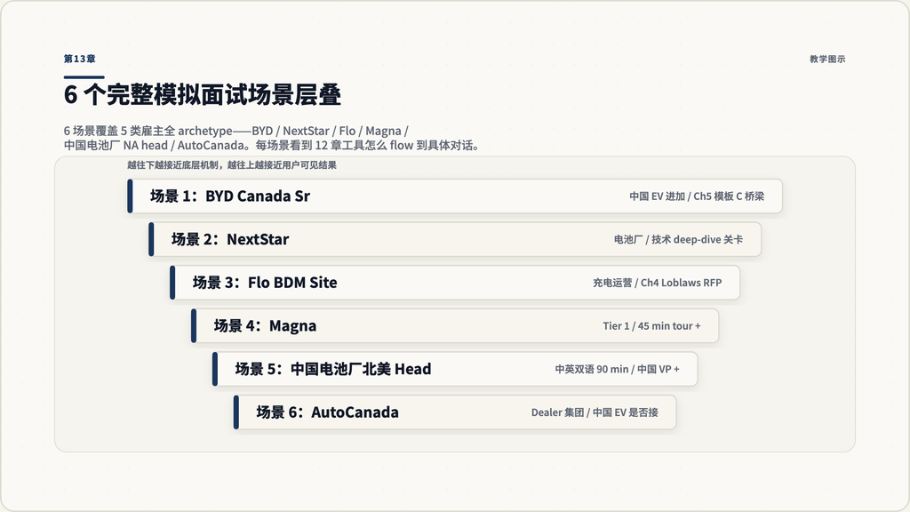

第13章：6 个完整模拟面试场景层叠

**图 13.1：6 个完整模拟面试场景——BYD Canada / NextStar / Flo / Magna / 中国电池厂北美 head / AutoCanada——覆盖 5 类雇主全 archetype。每个场景看到 12 章工具怎么 flow 到具体对话。9 个 micro-skills 是统一 muscle memory：开场 → STAR → Case → reframe → 反向 → 压轴 → close → timing → 数字。**

## 第14章 你的 30 天面试备战日历

### 14.1 为什么 30 天而不是 30 小时

你可以用 30 小时 cram 这本书的所有 chapter，但 cram 出来的 muscle memory 在面试现场会断裂——压力下你记住的不是 framework 本身而是 framework 在你身上的”自然反应版本”。

这一章把 14 章工具 sequence 到 30 天 schedule。**不是必须 30 天**——如果你已经在 active 面试 cycle 中，可以 compress 到 14-20 天。但 < 14 天的 cram 是不 work 的。

### 14.2 30 天 timeline overview

| 阶段 | 天数 | 焦点 | 核心 deliverable |
| --- | --- | --- | --- |
| **Week 1: Foundation** | Day 1-7 | 知识 + 桥梁 | 50 题答案 + 桥梁陈述完整版 + 8 个 case framework |
| **Week 2: Behavioral** | Day 8-14 | 真实故事 + STAR 重构 | 8-12 个 STAR 故事重构完成 |
| **Week 3: Tactical** | Day 15-21 | 雇主 specific + 对抗性 + 反向 | 公司研究模板 + 5 类对抗性 reframe + 反向提问库 |
| **Week 4: Integration** | Day 22-30 | 模拟 + 节奏 + 谈判 | 3 场完整 mock + Ch11 节奏 + Ch10 谈判 lock |

### 14.3 Week 1（Day 1-7）：Foundation 周——知识 + 桥梁

**Day 1 (60-90 min): 整本书 overview** - 读这本书的目录 + 第 1 章 (JD 解码) - 写下你 likely 面 5 类雇主里哪 2-3 类是 priority - 写下你的转型 archetype (Ch5 模板 A/B/C/D/E 哪条最贴近)

**Day 2 (60-90 min): Ch2 模块一 + 模块二** - 读 50 题里 Q1-Q20 (政策 + OEM) - 自答 each 题 90 秒 - 标记 5-10 题你 stuck 的 (这些后续 deep prep)

**Day 3 (60-90 min): Ch2 模块三 + 模块四** - 读 Q21-Q40 (电池 + 中国 EV) - 自答 each 题 90 秒 - 标记 stuck 题

**Day 4 (60-90 min): Ch2 模块五 + Anki setup** - 读 Q41-Q50 (加拿大本地) - Setup Anki 卡组——50 题答案版 - Day 4 起每天 review 10 张 Anki

**Day 5 (60-90 min): Ch5 桥梁陈述** - 读 Ch5 - 写出你 75-100 秒桥梁陈述完整版 - 录音 3 次，听节奏

**Day 6 (60-90 min): Ch4 案例题 1-4 类** - 读 Ch4 5 步流程 + 第 1-4 类案例 (Market Entry / Channel / Build vs Buy / Account Priority) - 自做 1 个案例题 mock (挑 1 个，5 步走完，写出来)

**Day 7 (60-90 min): Ch4 案例题 5-8 类 + Week 1 复盘** - 读 Ch4 5-8 类 (Cross-Border / BizModel / Pricing / Team Building) - Week 1 复盘：50 题完成率？桥梁陈述满意度？Case framework familiar 度？ - 写下 Week 2 调整

### 14.4 Week 2（Day 8-14）：Behavioral 周——真实故事 + STAR 重构

**Day 8 (90 min): Ch3 STAR 整体** - 读 Ch3 - 写出你 last 3-5 年最有冲击力的 8-12 个真实事件（“故事 inventory”） - 每个事件 1 行 description——不细写

**Day 9 (90 min): STAR 类 1+2 (闭单 + 冲突)** - 读 Ch3 Q1-Q9 - 把 inventory 里 fit 这 9 题的故事 reconstruct——用骨架重述 - 录音 each 故事 75-90 秒

**Day 10 (90 min): STAR 类 3+4 (影响力 + 失败)** - 读 Ch3 Q10-Q16 - 重构 fit 故事 - 录音

**Day 11 (90 min): STAR 类 5+6 (跨文化 + 客户)** - 读 Ch3 Q17-Q23 - 重构 fit 故事——这 7 题对出海 archetype 是 highest leverage - 录音

**Day 12 (90 min): STAR 类 7 (学习) + 故事 final list** - 读 Ch3 Q24-Q27 - 重构 fit 故事 - Finalize: 8-12 个故事——each 75-90 秒——cover 27 题里 18-22 题

**Day 13 (90 min): STAR 高频题录音 pass 2** - Re-record top 8 故事 - 回听对比 Day 9-12 录音——节奏 / specific / BD 视角进步了吗 - 标记仍 weak 的 2-3 个 story

**Day 14 (60 min): Week 2 复盘 + adjust** - 评估：8-12 故事是否 ready？哪些故事还需 fortify？ - 写下 Week 3 调整

### 14.5 Week 3（Day 15-21）：Tactical 周——雇主 specific + 对抗性 + 反向

**Day 15 (90 min): Ch1 + Ch8 雇主分类 + 流程** - 复习 Ch1 (JD 解码) + Ch8 (流程差异) - 挑你 likely 面的 2 类雇主——为这 2 类做 mapping (轮次 + 决策人 + 测试点) - 写下 follow-up question list

**Day 16 (90 min): Ch6 雇主研究模板** - 读 Ch6 - 挑 1 家你 likely 面的真实公司——做 24-48h 研究模板的 first pass (花 4-6 小时实际 research) - 输出：3 个 nod data points + 3 strategic challenges + 决策人 map

**Day 17 (90 min): Ch7 对抗性问题** - 读 Ch7 - 写出你 likely 遇到的 2-3 类对抗性问题 - 每类用 3 路径写出你的 reframe - 录音 each 60-90 秒

**Day 18 (90 min): 对抗性问题录音 pass 2** - Re-record——focus 3 步法（承认 / reframe / 具体证据） - 回听——哪句话听起来 defensive，重写

**Day 19 (90 min): Ch9 反向提问库** - 读 Ch9 - 按你 likely 面的轮次（HR / hiring manager / senior leader / CEO）写出 5-7 个反向提问 each - 准备 anchor-back 30 秒 for each strategic question

**Day 20 (90 min): 第二家公司研究 deep-dive** - 挑你 likely 面的第二家公司——做完整 24-48h 研究 - 写下 3 个 specific 数据点 + 3 strategic challenges + 你的判断 - 写出针对这家的 customized 桥梁陈述 (specific reference to 这家)

**Day 21 (60 min): Week 3 复盘 + adjust** - 评估：雇主研究 ready 几家？对抗性问题 fluent？反向提问质量？ - 写下 Week 4 调整

### 14.6 Week 4（Day 22-30）：Integration 周——模拟 + 节奏 + 谈判

**Day 22 (120 min): Mock interview 1——挑你 likely 雇主类型** - 用 Ch13 对应场景做 mock (e.g., 如果你面 OEM 用 Magna 场景，面充电用 Flo 场景) - 找 friend / mentor 当面试官 - 录音整场 - 复盘——哪条工具用上 / 哪条 missing

**Day 23 (90 min): Mock 1 debrief + targeted fix** - 回听 mock 1 录音 - 写下 5 个 specific improvement - Re-record stuck STAR / reframe

**Day 24 (90 min): Ch10 薪酬带 + 谈判** - 读 Ch10 - 写下你的 5 个数字 (walk-away / target / reach / market 75th / alternative) - 准备 5 个谈判 script 自然 articulation

**Day 25 (120 min): Mock interview 2——第二类雇主或同类不同公司** - 做 mock 2 - 录音 - 比较 mock 1 vs mock 2 进步

**Day 26 (90 min): Ch11 + Ch12 节奏 + 跟进** - 读 Ch11 (T-48h 节奏) + Ch12 (跟进) - 写出你 next 实际面试的 specific timeline - 准备 thank-you note template

**Day 27 (90 min): Mock interview 3——final integration** - 做 mock 3——压力测试 (full 90 min including reverse Q + close) - 录音

**Day 28 (60 min): Mock 3 debrief + 整体复盘** - 回听 mock 3 - 整体评估你的 14-chapter muscle memory：哪些 章节 ready / 哪些 still weak

**Day 29 (60-90 min): 弱点 targeted prep** - 针对最 weak 的 2-3 个 chapter 做 final pass - 重新录音那些 chapter 的核心 deliverable

**Day 30 (45-60 min): final overview + rest** - 读这本书的 14 章每章 5 分钟 (overview only) - 不要 cram any new content - 早睡——为你的下一场实际面试 ready

### 14.7 30 天 schedule 的 5 个 anti-patterns

| Anti-pattern | 为什么差 | 替代 |
| --- | --- | --- |
| 周末 cram 5+ 小时 | cognitive 累积让 retention 反而下降 | 每天 60-90 min, sustained over 30 days |
| 跳过录音 | 不录音 = 你不知道你 sound 如何 | every chapter deliverable 必录音 |
| 只读不写 | reading is passive consumption | every chapter 都有 written deliverable |
| 没有 mock | 没有压力测试 = 真实面试时 break | week 4 至少 3 个 mock |
| 同 friend 做所有 mock | friend 的 bias 累积——不再 push you | 不同 mock 不同 person |

### 14.8 如果你的时间表 < 30 天怎么 compress

**14 天 compress 版**：

- Day 1-3: Foundation——Ch1+Ch2+Ch5 (10 题/day Ch2, 桥梁陈述)
- Day 4-6: Behavioral——Ch3 重构 8 故事
- Day 7-9: Tactical——Ch6+Ch7+Ch9 + 1 家公司研究
- Day 10-12: Integration——2 个 mock + Ch4 case framework
- Day 13: Ch10 + Ch11 + Ch12
- Day 14: Final overview + rest

**7 天 emergency compress 版**：

- Day 1-2: Ch2 50 题 fast pass + Ch5 桥梁
- Day 3: Ch3 STAR 重构 5-6 个核心故事
- Day 4: Ch6 + Ch9——1 家公司 deep + 反向提问
- Day 5: Ch4 + Ch7——4 个 case + 2 类对抗性
- Day 6: 1 mock + Ch10 lock
- Day 7: Ch11 节奏 + rest

### 14.9 30 天后——保持 muscle memory 的 ongoing 节奏

如果你拿到 offer——恭喜。但 muscle memory 会随时间 decay：

- **每 2 周**：录音回听 3 个 random STAR——检查仍然 fluent
- **每月**：更新 Ch2 50 题里的政策/数字时点（这是 fast-moving 行业）
- **每季度**：复习这本书的 14 章 overview

如果你还没拿到 offer 继续 cycle：

- 每场面试后 debrief：Ch12 process
- 每 1-2 月 add 1 个新故事到 STAR inventory
- 每 1-2 月 update 你的雇主研究模板

### 14.10 章末检查点 + 全书 final 检查点

把这 30 天 timeline 落到你 calendar 上——具体日期。然后问自己：

- Week 1 末：50 题能 90 秒答出 40+ 吗？桥梁陈述录音满意吗？
- Week 2 末：8-12 个 STAR 故事 reconstructed？每个 75-90 秒？
- Week 3 末：2 家公司研究 ready？反向提问 5-7 个 per round？
- Week 4 末：3 个 mock 完成？录音回听有 measurable 进步？

四问 yes ≥ 3 = 你 ready 上面试桌.

**全书 final check**（综合所有 14 章）：

> “下周三上午 10 点，你坐到一家加拿大 EV 雇主的 panel 面试里。45 分钟，6 个 question——5 个 behavioral + 1 个 case。最后 10 分钟反向提问。”

> “你能 confidence 处理这场面试吗？”

If yes——这本书 served its purpose.

If no——回到 weakest chapter 再 pass 一遍。

知识可以查，判断要养，muscle memory 必须自己走过。

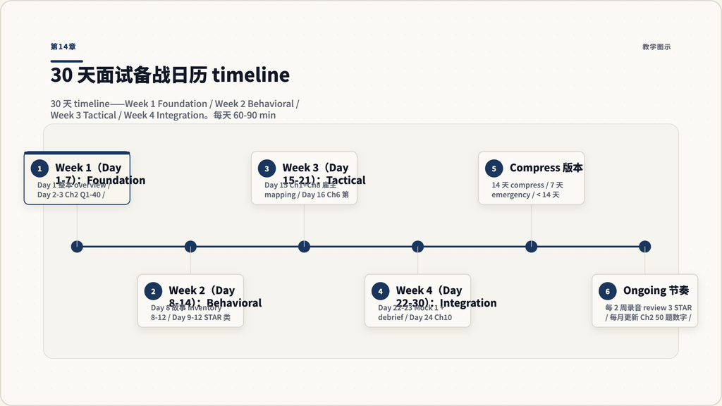

第14章：30 天面试备战日历 timeline

**图 14.1：30 天 timeline——Week 1 Foundation (Ch1+Ch2+Ch4+Ch5) / Week 2 Behavioral (Ch3) / Week 3 Tactical (Ch6+Ch7+Ch8+Ch9) / Week 4 Integration (Ch10+Ch11+Ch12+Ch13)。每天 60-90 min, sustained, 不 cram。每章有 written + 录音 deliverable。Week 4 至少 3 个 mock。**

## 结语：你刚走完一遍这场 90 分钟之外的准备

把这 14 章串成一句话：

> JD 是雇主的认知地图；50 题是知识硬通货；STAR 是你真实经历的结构化骨架；案例题是商业判断的 5 步流程；5 套桥梁陈述把转型经历翻译成 EV BD 价值；5 类雇主研究模板让你 24-48 小时形成判断；5 类对抗性问题用 3 步法拆解；面试流程是雇主决策结构的镜像；反向提问是隐形评估时刻；薪酬带是分布不是数字；T-48h 节奏让 cognitive bandwidth 走对；面试后跟进决定决策期 second interview；6 个完整模拟把工具拼到一场具体对话；30 天日历让 muscle memory 真正 sink。

这本书不是终点。**面试技巧是基础，行业判断是底盘**。

下次你走进那家加拿大 EV 公司的面试，记住开场那段：

**面试官真正在测的不是你的知识——他们在测你能不能在压力下仍然 think 而不是 react。**

知识可以查，判断要养，反应速度只能在压力下练出来。

这本书帮你完成的是从”看到 EV BD JD 不知道在测什么”到”看 5 分钟知道对方在测什么并且 confident”的距离。

剩下的——故事要你自己填，关系要你自己建，offer 要你自己谈下来。

下一场面试见。

## 参考资料

以下是本书引用的所有外部公开来源。建议每次面试前 48 小时重新核对仍 active + 数字仍最新。

**加拿大 EV 政策与监管：**

- Canada drops EV mandate — CBT News: https://www.cbtnews.com/canada-drops-ev-mandate-2026
- Carney drops EV mandate, intro purchase rebates — CBC: https://www.cbc.ca/news/politics/carney-dropping-ev-mandate-introducing-new-emissions-standards-9.7075302
- EV Affordability Program (EVAP) explainer — Electric Autonomy: https://electricautonomy.ca/policy-regulations/ev-rebates-incentives-funding/2026-02-23/heres-how-the-electric-vehicle-affordability-program-works/
- EVAP — Transport Canada official: https://tc.canada.ca/en/road-transportation/innovative-technologies/electric-vehicles/electric-vehicle-affordability-program
- EVAP 24,400 sales in first three months — Eletric Vehicles: https://eletric-vehicles.com/general/canadas-ev-rebate-drives-more-than-24400-sales-in-first-three-months/
- Canada pauses EV sales mandate for 2026 — Electric Autonomy: https://electricautonomy.ca/policy-regulations/2025-09-06/canada-ev-sales-mandate-2026-pause/
- US Section 30D — Department of Energy: https://www.energy.gov/mesc/30d-new-clean-vehicle-credit
- Canada 100% tariff on Chinese-made EVs — Electric Autonomy Canada: https://electricautonomy.ca/policy-regulations/2024-08-27/canada-imposes-tariffs-on-chinese-made-evs-aluminum-steel/

**加拿大 EV 雇主与招聘：**

- Electric Vehicles Jobs in Canada — LinkedIn: https://ca.linkedin.com/jobs/electric-vehicle-jobs
- Electric Vehicle Charging Jobs in Canada — LinkedIn: https://ca.linkedin.com/jobs/electric-vehicle-charging-jobs
- EV.Careers Toronto: https://ev.careers/jobs/in-toronto-ontario-canada
- Canada EV Charging Networks 2026 — Electric Autonomy: https://electricautonomy.ca/data-trackers/public-charging-networks/2026-04-01/2026-ev-charging-network-report-steady-progress/
- NextStar Energy careers: https://nextstar-energy.com/current-opportunities/
- NextStar Energy grand opening — CP24: https://www.cp24.com/news/canada/2026/03/06/1300-jobs-created-windsor-onts-nextstar-energy-battery-plant-grand-opening/
- Stellantis 650 EV research staff Windsor — CBC: https://www.cbc.ca/news/canada/windsor/stellantis-electric-vehicle-windsor-research-battery-nextstar-9.7083566
- VW PowerCo Ontario battery plant — Volkswagen Group: https://www.volkswagen-group.com/en/press-releases/volkswagen-and-powerco-se-will-build-their-largest-cell-factory-to-date-in-canada-16163
- PowerCo construction status — Automotive News: https://www.autonews.com/volkswagen/anc-powerco-starts-construction-ontario-battery-plant-1028/
- Chinese EV brands hiring spree in Canada — Carscoops: https://www.carscoops.com/2026/05/chinese-automakers-canada-launch/
- Zeekr, Chery, BYD Canadian launch plans — Motor Illustrated: https://motorillustrated.com/zeekr-chery-and-byd-advance-canadian-ev-launch-plans/182998/
- Chinese automakers entering Canada — Electrek: https://electrek.co/2026/05/06/chinese-ev-automakers-canada-byd-chery-geely-tesla-benefits/
- AutoCanada Careers: https://www.autocan.ca/ac-careers/
- AutoCanada Glassdoor jobs: https://www.glassdoor.ca/Jobs/AutoCanada-Jobs-E1363807.htm
- Magna Canada Recruiting: https://www.magna.com/canada-recruiting
- Magna Interview Tips: https://www.magna.com/careers/interview-tips
- Magna Interview Questions — Glassdoor: https://www.glassdoor.ca/Interview/Magna-International-Interview-Questions-E5767.htm
- GM Canada interview questions — Glassdoor: https://www.glassdoor.ca/Interview/General-Motors-(GM)-Canada-Interview-Questions-EI_IE279.0,19_IL.20,26_IN3.htm

**加拿大薪酬数据：**

- FLO/AddÉnergie salaries — Glassdoor.ca: https://www.glassdoor.ca/Salary/FLO-Add%C3%89nergie-Salaries-E2288862.htm
- FLO EV Charging BDM salary — Indeed: https://www.indeed.com/cmp/Flo-Solutions-De-Recharge/salaries
- BDM salary in Canada 2026 — Glassdoor: https://www.glassdoor.ca/Salaries/business-development-manager-salary-SRCH_KO0,28.htm
- Toronto BDM salary — Glassdoor: https://www.glassdoor.com/Salaries/toronto-business-development-manager-salary-SRCH_IL.0,7_IM976_KO8,36.htm
- Montreal BDM salary 2026 — Glassdoor: https://www.glassdoor.com/Salaries/montreal-qc-canada-business-development-manager-salary-SRCH_IL.0,18_IM990_KO19,47.htm
- Canada BDM salary — Indeed: https://ca.indeed.com/career/business-development-manager/salaries
- Toronto BD salary — Levels.fyi: https://www.levels.fyi/t/business-development/locations/toronto-can
- SDR salaries Canada — RepVue: https://www.repvue.com/salaries/sales-development-representative/CA
- What is OTE Salary 2026 — Apollo: https://www.apollo.io/insights/ote-salary
- Magna International salaries Canada — Payscale: https://www.payscale.com/research/CA/Employer=Magna_International/Salary
- NextStar Energy Windsor salary band — Indeed: https://ca.indeed.com/q-nextstar-energy-battery-l-windsor,-on-jobs.html

**面试方法论：**

- BDR STAR Method questions — interviews.chat: https://www.interviews.chat/star-questions/business-development-representative
- Marketing Interview 10 frameworks — Lewis Lin: https://www.lewis-lin.com/newsletter-archive/2017/8/4/-new-marketing-interview-cheat-sheet-10-frameworks-you-need-to-know
- BD case study interview guide: https://www.hackingthecaseinterview.com/pages/business-development-case-study-interview
- Mastering Sales Behavioral Interviews — Just Sales Jobs: https://justsalesjobs.ca/mastering-sales-behavioral-interviews/
- 23 Reverse Interview Questions — Courageous Careers: https://www.courageous-careers.com/23-reverse-interview-questions-to-ask-hiring-managers
- Reverse-interview repo — viraptor (GitHub): https://github.com/viraptor/reverse-interview
- Reverse Interviewing — Pragmatic Engineer: https://blog.pragmaticengineer.com/reverse-interviewing/
- 4 Sample Thank-You Emails — Indeed: https://www.indeed.com/career-advice/interviewing/sample-thank-you-letter-after-interview
- Thank-You Email template — The Muse: https://www.themuse.com/advice/how-to-write-an-interview-thankyou-note-an-email-template
- Sample behavioural interview questions — Gov of BC: https://www2.gov.bc.ca/assets/gov/careers/for-hiring-managers/resources-for-hiring-managers/sample_behavioural_interview_questions.pdf
- 34 BDM interview questions — Indeed: https://www.indeed.com/career-advice/interviewing/business-development-manager-interview-questions
- BDM interview questions — Workable: https://resources.workable.com/business-development-manager-interview-questions

**赛前必做：**

每次面试前 48 小时，**至少**重新核对以下 5 个数字最新版本：

1. 加拿大联邦 EV mandate 状态（是否仍 repealed，2027 USMCA 审查动态）
2. EVAP $5k 补贴当前覆盖+用量（dealer-portal mechanics）
3. Canadian Q1/Q2 EV 渗透率（全国 + 魁北克 + BC + 安大略分别）
4. BYD / Zeekr / Chery 加拿大进度（dealer 签约 / 公开活动）
5. 你目标公司当前 active openings + 最近 6 个月 strategic 动作

这 5 个数据每月可能刷新——把它们装到你的”面试前 48 小时清单”里。